# RDoC Behavioral Data Exploration

Catherine Walsh

3/2/2020

```r
library(dplyr)
library(skimr)
library(R.matlab)
```

```r
library(corrplot)
library(psych)
library(ggplot2)
library(patchwork)
library(reshape2)
library(readxl)
library(lme4)
source('~/Documents/Code/RDoC_for_GitHub/clean_data.R')
source('~/Documents/Code/RDoC_for_GitHub/t_test_df.R')
```

First, we need to load in the data. We’ve saved the data individual .RData files earlier, to make our lives easier. Usually we’re going to separate out FFA and HPC from our DFR variables, but here we’re going to add them into the same datafame just to make our descriptives easier.

```r
load('data/load_effects_DFR.RData')
load('data/behav.RData')
load('data/resting_state.RData')

# add in FFA and HPC data to load effects, just to check for differences in groups easily
p200_indiv_ROI_DFR_delay <- merge(p200_indiv_ROI_DFR_delay,p200_FFA[,c(1,15,18)],all=TRUE,by="PTID")
colnames(p200_indiv_ROI_DFR_delay)[30:31] <- c("L_FFA_DELAY_LE", "R_FFA_DELAY_LE")
p200_indiv_ROI_DFR_delay <- merge(p200_indiv_ROI_DFR_delay,p200_HPC_Ant[,c(1,15,18)],all=TRUE,by="PTID")
colnames(p200_indiv_ROI_DFR_delay)[32:33] <- c("L_HPC_Ant_DELAY_LE", "R_HPC_Ant_DELAY_LE")
p200_indiv_ROI_DFR_delay <- merge(p200_indiv_ROI_DFR_delay,p200_HPC_Med[,c(1,15,18)],all=TRUE,by="PTID")
colnames(p200_indiv_ROI_DFR_delay)[34:35] <- c("L_HPC_Med_DELAY_LE", "R_HPC_Med_DELAY_LE")
p200_indiv_ROI_DFR_delay <- merge(p200_indiv_ROI_DFR_delay,p200_HPC_Post[,c(1,15,18)],all=TRUE,by="PTID")
colnames(p200_indiv_ROI_DFR_delay)[36:37] <- c("L_HPC_Post_DELAY_LE", "R_HPC_Post_DELAY_LE")
```

```r
#pull out just clinical variables
p200_clinical <- dplyr::select(p200_data,PTID,WHO_ST_S32,BPRS_ANX,BPRS_DEP,BPRS_DIST,EDD_TS,ANX_TS,BPRS_TOT,OCI_RT_SUM,K10_Total_Sum,PHQ_SS_SUM,PQ_TotalSum,sum_lev1man)

#pull out just cognitive variables
p200_cog <- dplyr::select(p200_data,PTID,ANALYSIS_DIGITSPANFWD_RAW,WMS_SYMS_TOTSCORE,ANALYSIS_DIGITSPANBKW_RAW,ANALYSIS_DIGITSPANSEQ_RAW,SCORING_LETNUMSEQ_RAW,WMS_SA_TOTSCORE,SCORING_MATRIXREASONING_RAW,VOCABULARY_TOTALRAWSCORE,XLCD_K_MAX,XSCAP_MAX_CAPAC,XDFR_EEG_COW_L3,XDFR_MRI_COW_L3,XAOS_PART_SCORE,XDPX_DPRIME,XRISE_PR_ITEM,XRISE_PR_RELAT,XDFR_MRI_ACC_L3, XDFR_MRI_ACC_L1)

p200_cog$XDPX_DPRIME <- as.numeric(p200_cog$XDPX_DPRIME)

#z-score both clinical and cog variables, remove outliers for cognitive but not clinical
p200_cog_zscores <- clean_data(p200_cog)
p200_clinical_zscores <- clean_data(p200_clinical,outliers=2)
```

# Demographics

```r
#get demographics
p200_demographics <- dplyr::select(p200_data,PTID,X010701_GENDER,PX010101_AGE)
colnames(p200_demographics) <- c('PTID',"GENDER","AGE")

# GENDER: 1 = male, 2 = female
# GROUP: 1 = CS, 2 = NCS
# SCANNER: 1 = Trio, 2 = Prisma

# add in scanner, group to df
for (suj in seq.int(1,200)){
  if (p200_demographics$PTID[suj] < 1500 | (p200_demographics$PTID[suj] >= 1600  & p200_demographics$PTID[suj] < 2500)){
    p200_demographics$SCANNER[suj] <- 1
  }else{
    p200_demographics$SCANNER[suj] <- 2
  }
  if (p200_demographics$PTID[suj] < 2000){
    p200_demographics$GROUP[suj] <- 1
  }else{
    p200_demographics$GROUP[suj] <- 2
  }
}
```

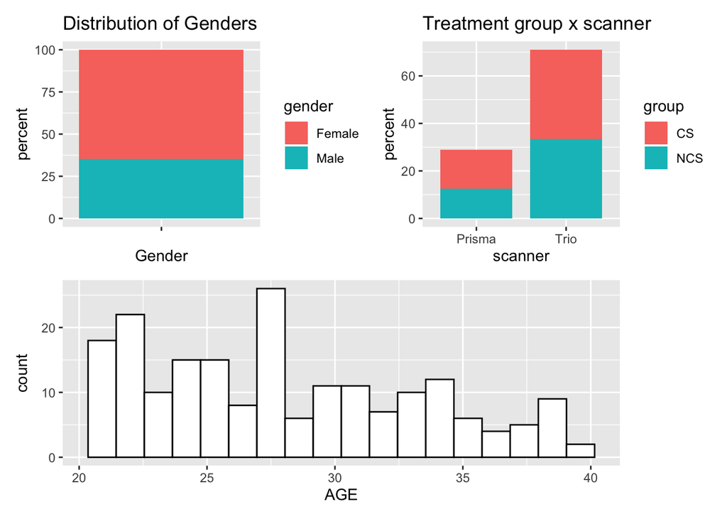

```r
df.gender <- data.frame(
  gender = c("Male", "Female"),
  percent = c(sum(p200_demographics$GENDER==1)/199*100, sum(p200_demographics$GENDER==2)/199*100)
)

df.scanner <- data.frame(
  scanner = c("Trio", "Prisma"),
  percent = c(sum(p200_demographics$SCANNER==1)/200*100, sum(p200_demographics$SCANNER==2)/200*100)
)

df.treat <- data.frame(
  group = c("CS", "NCS"),
  percent = c(sum(p200_demographics$GROUP==1)/200*100, sum(p200_demographics$GROUP==2)/200*100)
)

df.scanner.treat <- data.frame(
  scanner = c("Trio", "Trio", "Prisma", "Prisma"),
  group = c("CS", "NCS", "CS", "NCS"),
  percent = c(sum(p200_demographics$GROUP==1 & p200_demographics$SCANNER==1)/200*100, sum(p200_demographics$GROUP==1 & p200_demographics$SCANNER==2)/200*100, sum(p200_demographics$GROUP==2 & p200_demographics$SCANNER==1)/200*100, sum(p200_demographics$GROUP==2 & p200_demographics$SCANNER==2)/200*100)
)

bp.gender<- ggplot(df.gender, aes(x="", y=percent, fill=gender))+
  geom_bar(width = 1, stat = "identity")+
  xlab("Gender") +
  ggtitle("Distribution of Genders")

bp.scanner<- ggplot(df.scanner, aes(x="", y=percent, fill=scanner))+
  geom_bar(width = 1, stat = "identity")

bp.treat<- ggplot(df.treat, aes(x="", y=percent, fill=group))+
  geom_bar(width = 1, stat = "identity")

bp.scanner.treat <- ggplot(df.scanner.treat, aes(x=scanner, y=percent, fill=group))+
  geom_bar(width = .8, stat = "identity") +
  ggtitle("Treatment group x scanner")

hist.age <- ggplot(p200_demographics, aes(x=AGE))+
  geom_histogram(binwidth=1.1,color="black", fill="white")

(bp.gender | bp.scanner.treat) / hist.age
```

Need to remember to ask Jesse about whether different examples of same type of measures should be corrected for multiple comparisons or if they’re considered independent variables.

# Describe Cognitive Variables

## All Subjects

```r
skim(p200_cog_zscores)
```

Data summary

| Name | p200_cog_zscores |
| --- | --- |
| Number of rows | 200 |
| Number of columns | 19 |
| _______________________ |  |
| Column type frequency: |  |
| numeric | 19 |
| ________________________ |  |
| Group variables | None |

**Variable type: numeric**

| skim_variable | n_missing | complete_rate | mean | sd | p0 | p25 | p50 | p75 | p100 | hist |
| --- | --- | --- | --- | --- | --- | --- | --- | --- | --- | --- |
| PTID | 0 | 1.00 | 1669.32 | 437.06 | 1002.00 | 1524.75 | 1594.50 | 2011.25 | 2534.00 | ▃▇▃▃▂ |
| ANALYSIS_DIGITSPANFWD_RAW | 0 | 1.00 | 0.00 | 1.00 | -2.16 | -0.74 | -0.27 | 0.68 | 2.57 | ▃▂▇▁▂ |
| WMS_SYMS_TOTSCORE | 1 | 1.00 | 0.02 | 0.97 | -2.21 | -0.70 | -0.09 | 0.66 | 2.33 | ▂▆▇▆▂ |
| ANALYSIS_DIGITSPANBKW_RAW | 2 | 0.99 | -0.03 | 0.96 | -1.81 | -0.50 | -0.06 | 0.38 | 2.57 | ▆▇▆▃▁ |
| ANALYSIS_DIGITSPANSEQ_RAW | 1 | 1.00 | -0.02 | 0.97 | -2.24 | -0.85 | 0.07 | 0.54 | 2.85 | ▃▇▇▂▁ |
| SCORING_LETNUMSEQ_RAW | 2 | 0.99 | 0.00 | 0.95 | -2.57 | -0.48 | -0.13 | 0.56 | 2.31 | ▁▅▇▆▁ |
| WMS_SA_TOTSCORE | 0 | 1.00 | 0.00 | 1.00 | -2.93 | -0.68 | 0.32 | 0.82 | 1.82 | ▁▃▃▇▃ |
| SCORING_MATRIXREASONING_RAW | 2 | 0.99 | 0.04 | 0.93 | -3.00 | -0.36 | 0.17 | 0.70 | 1.49 | ▁▁▅▇▇ |
| VOCABULARY_TOTALRAWSCORE | 2 | 0.99 | 0.02 | 0.98 | -2.90 | -0.50 | 0.07 | 0.76 | 1.79 | ▁▁▇▇▅ |
| XLCD_K_MAX | 7 | 0.96 | 0.00 | 1.00 | -2.16 | -0.69 | 0.04 | 0.71 | 2.48 | ▃▇▇▅▂ |
| XSCAP_MAX_CAPAC | 2 | 0.99 | 0.00 | 1.00 | -2.97 | -0.61 | 0.34 | 0.87 | 1.31 | ▁▂▅▇▇ |
| XDFR_EEG_COW_L3 | 5 | 0.98 | 0.00 | 1.00 | -2.73 | -0.70 | 0.07 | 0.61 | 2.48 | ▁▅▇▆▂ |
| XDFR_MRI_COW_L3 | 16 | 0.92 | 0.00 | 1.00 | -2.77 | -0.60 | 0.03 | 0.65 | 2.05 | ▁▃▇▇▃ |
| XAOS_PART_SCORE | 5 | 0.98 | 0.07 | 0.90 | -3.00 | -0.34 | 0.25 | 0.70 | 1.22 | ▁▁▃▆▇ |
| XDPX_DPRIME | 9 | 0.96 | 0.02 | 0.98 | -2.87 | -0.63 | 0.13 | 0.79 | 1.47 | ▁▂▆▇▇ |
| XRISE_PR_ITEM | 8 | 0.96 | 0.07 | 0.83 | -2.85 | -0.34 | 0.18 | 0.61 | 1.24 | ▁▁▂▇▇ |
| XRISE_PR_RELAT | 8 | 0.96 | 0.06 | 0.90 | -2.63 | -0.48 | 0.14 | 0.65 | 1.54 | ▁▂▆▇▅ |
| XDFR_MRI_ACC_L3 | 16 | 0.92 | 0.00 | 1.00 | -2.66 | -0.49 | 0.13 | 0.75 | 2.30 | ▂▅▇▇▂ |
| XDFR_MRI_ACC_L1 | 18 | 0.91 | 0.05 | 0.90 | -2.65 | -0.44 | 0.44 | 0.88 | 0.88 | ▁▁▁▃▇ |

## Gender

```r
# males
skim(p200_cog %>% filter(p200_demographics$GENDER==1))
```

Data summary

| Name | p200_cog %>% filter(p200_… |
| --- | --- |
| Number of rows | 70 |
| Number of columns | 19 |
| _______________________ |  |
| Column type frequency: |  |
| numeric | 19 |
| ________________________ |  |
| Group variables | None |

**Variable type: numeric**

| skim_variable | n_missing | complete_rate | mean | sd | p0 | p25 | p50 | p75 | p100 | hist |
| --- | --- | --- | --- | --- | --- | --- | --- | --- | --- | --- |
| PTID | 0 | 1.00 | 1677.89 | 476.64 | 1002.00 | 1503.75 | 1598.50 | 2022.50 | 2531.00 | ▆▇▃▅▃ |
| ANALYSIS_DIGITSPANFWD_RAW | 0 | 1.00 | 10.60 | 2.29 | 6.00 | 9.00 | 10.00 | 12.00 | 16.00 | ▅▇▆▃▂ |
| WMS_SYMS_TOTSCORE | 0 | 1.00 | 24.46 | 7.15 | 3.00 | 20.00 | 23.50 | 29.75 | 40.00 | ▁▂▇▅▂ |
| ANALYSIS_DIGITSPANBKW_RAW | 0 | 1.00 | 9.21 | 2.24 | 5.00 | 8.00 | 9.00 | 10.00 | 14.00 | ▃▆▇▂▂ |
| ANALYSIS_DIGITSPANSEQ_RAW | 0 | 1.00 | 9.37 | 2.41 | 4.00 | 8.00 | 9.50 | 10.00 | 16.00 | ▂▅▇▂▁ |
| SCORING_LETNUMSEQ_RAW | 0 | 1.00 | 20.76 | 3.03 | 11.00 | 19.00 | 20.00 | 23.00 | 29.00 | ▁▃▇▆▁ |
| WMS_SA_TOTSCORE | 0 | 1.00 | 17.36 | 3.70 | 9.00 | 16.00 | 18.00 | 20.00 | 24.00 | ▃▂▆▇▂ |
| SCORING_MATRIXREASONING_RAW | 0 | 1.00 | 20.87 | 3.53 | 6.00 | 19.00 | 21.50 | 23.00 | 26.00 | ▁▁▂▇▇ |
| VOCABULARY_TOTALRAWSCORE | 0 | 1.00 | 41.07 | 9.29 | 16.00 | 36.25 | 42.00 | 47.75 | 57.00 | ▂▁▇▇▅ |
| XLCD_K_MAX | 3 | 0.96 | 2.72 | 0.85 | 0.93 | 2.22 | 2.70 | 3.27 | 4.64 | ▃▆▇▅▂ |
| XSCAP_MAX_CAPAC | 0 | 1.00 | 5.43 | 1.26 | 2.10 | 4.67 | 5.73 | 6.42 | 7.00 | ▂▂▃▇▆ |
| XDFR_EEG_COW_L3 | 3 | 0.96 | 1.59 | 0.48 | 0.32 | 1.20 | 1.62 | 1.98 | 2.50 | ▂▅▇▇▅ |
| XDFR_MRI_COW_L3 | 3 | 0.96 | 1.42 | 0.66 | 0.00 | 0.94 | 1.50 | 1.88 | 2.72 | ▂▅▇▇▃ |
| XAOS_PART_SCORE | 0 | 1.00 | 59.50 | 13.25 | 10.00 | 56.00 | 62.00 | 67.00 | 75.00 | ▁▁▂▆▇ |
| XDPX_DPRIME | 3 | 0.96 | 3.33 | 0.98 | 0.18 | 2.72 | 3.50 | 4.03 | 4.76 | ▁▂▅▇▇ |
| XRISE_PR_ITEM | 1 | 0.99 | 0.86 | 0.11 | 0.49 | 0.82 | 0.89 | 0.93 | 0.99 | ▁▁▂▅▇ |
| XRISE_PR_RELAT | 1 | 0.99 | 0.72 | 0.19 | 0.12 | 0.63 | 0.78 | 0.84 | 1.00 | ▁▁▃▇▇ |
| XDFR_MRI_ACC_L3 | 3 | 0.96 | 0.72 | 0.11 | 0.47 | 0.66 | 0.72 | 0.81 | 0.97 | ▃▅▇▇▂ |
| XDFR_MRI_ACC_L1 | 3 | 0.96 | 0.92 | 0.08 | 0.62 | 0.88 | 0.97 | 0.97 | 1.00 | ▁▁▂▂▇ |

```r
# females
skim(p200_cog %>% filter(p200_demographics$GENDER==2))
```

Data summary

| Name | p200_cog %>% filter(p200_… |
| --- | --- |
| Number of rows | 129 |
| Number of columns | 19 |
| _______________________ |  |
| Column type frequency: |  |
| numeric | 19 |
| ________________________ |  |
| Group variables | None |

**Variable type: numeric**

| skim_variable | n_missing | complete_rate | mean | sd | p0 | p25 | p50 | p75 | p100 | hist |
| --- | --- | --- | --- | --- | --- | --- | --- | --- | --- | --- |
| PTID | 0 | 1.00 | 1665.33 | 417.62 | 1003.00 | 1533.00 | 1592.00 | 2004.00 | 2534.00 | ▃▇▃▃▂ |
| ANALYSIS_DIGITSPANFWD_RAW | 0 | 1.00 | 10.57 | 2.01 | 7.00 | 9.00 | 10.00 | 12.00 | 15.00 | ▃▇▃▅▂ |
| WMS_SYMS_TOTSCORE | 0 | 1.00 | 24.79 | 6.28 | 11.00 | 20.00 | 24.00 | 29.00 | 38.00 | ▂▅▇▃▂ |
| ANALYSIS_DIGITSPANBKW_RAW | 0 | 1.00 | 9.09 | 2.32 | 5.00 | 7.00 | 9.00 | 11.00 | 16.00 | ▆▇▅▂▁ |
| ANALYSIS_DIGITSPANSEQ_RAW | 0 | 1.00 | 8.56 | 1.98 | 4.00 | 7.00 | 8.00 | 10.00 | 14.00 | ▂▇▆▂▁ |
| SCORING_LETNUMSEQ_RAW | 0 | 1.00 | 20.21 | 2.75 | 13.00 | 18.00 | 20.00 | 22.00 | 27.00 | ▁▅▇▆▁ |
| WMS_SA_TOTSCORE | 0 | 1.00 | 16.43 | 4.11 | 5.00 | 14.00 | 18.00 | 20.00 | 23.00 | ▁▃▃▇▆ |
| SCORING_MATRIXREASONING_RAW | 0 | 1.00 | 20.06 | 3.91 | 7.00 | 19.00 | 21.00 | 23.00 | 25.00 | ▁▁▂▆▇ |
| VOCABULARY_TOTALRAWSCORE | 1 | 0.99 | 41.53 | 8.50 | 13.00 | 37.00 | 41.00 | 48.00 | 57.00 | ▁▁▆▇▅ |
| XLCD_K_MAX | 4 | 0.97 | 2.60 | 0.79 | 0.90 | 2.05 | 2.61 | 3.15 | 4.44 | ▃▇▇▅▂ |
| XSCAP_MAX_CAPAC | 2 | 0.98 | 5.20 | 1.33 | 1.40 | 4.17 | 5.25 | 6.42 | 7.00 | ▁▂▇▇▇ |
| XDFR_EEG_COW_L3 | 2 | 0.98 | 1.60 | 0.45 | 0.43 | 1.32 | 1.60 | 1.88 | 2.75 | ▁▅▇▅▂ |
| XDFR_MRI_COW_L3 | 13 | 0.90 | 1.53 | 0.56 | -0.19 | 1.12 | 1.56 | 1.88 | 2.62 | ▁▃▇▇▃ |
| XAOS_PART_SCORE | 1 | 0.99 | 54.72 | 15.84 | 5.00 | 47.00 | 57.50 | 67.00 | 75.00 | ▁▁▃▇▇ |
| XDPX_DPRIME | 5 | 0.96 | 3.11 | 1.12 | -0.08 | 2.48 | 3.23 | 4.01 | 4.76 | ▂▁▆▇▇ |
| XRISE_PR_ITEM | 4 | 0.97 | 0.86 | 0.11 | 0.24 | 0.83 | 0.88 | 0.92 | 0.99 | ▁▁▁▃▇ |
| XRISE_PR_RELAT | 4 | 0.97 | 0.71 | 0.18 | 0.00 | 0.63 | 0.74 | 0.84 | 1.00 | ▁▁▂▇▆ |
| XDFR_MRI_ACC_L3 | 13 | 0.90 | 0.75 | 0.09 | 0.47 | 0.69 | 0.75 | 0.81 | 0.94 | ▁▃▇▇▂ |
| XDFR_MRI_ACC_L1 | 13 | 0.90 | 0.95 | 0.06 | 0.78 | 0.91 | 0.97 | 1.00 | 1.00 | ▁▁▃▂▇ |

ANALYSIS_DIGITSPANSEQ_RAW is the only test that differs based on gender at p < 0.05, uncorrected, with males > females.

```r
# one subject did not report gender --> remove this subject
p200_demographics_gender<-p200_demographics[p200_demographics$GENDER <3,]

p200_cog_gender <- p200_cog_zscores[p200_cog_zscores$PTID %in% p200_demographics_gender$PTID,]

t_test_df(p200_cog_gender, p200_demographics_gender$GENDER, "Gender")
```

```
##    split_var                    test_var           Statistic scanner used?
## 1     Gender   ANALYSIS_DIGITSPANFWD_RAW  -0.012469814107212            no
## 2     Gender           WMS_SYMS_TOTSCORE 0.00341981115102042            no
## 3     Gender   ANALYSIS_DIGITSPANBKW_RAW  -0.100787877106694            no
## 4     Gender   ANALYSIS_DIGITSPANSEQ_RAW  -0.331614693720679            no
## 5     Gender       SCORING_LETNUMSEQ_RAW  -0.198767105148279            no
## 6     Gender             WMS_SA_TOTSCORE  -0.230690667719284            no
## 7     Gender SCORING_MATRIXREASONING_RAW  -0.243511955326102            no
## 8     Gender    VOCABULARY_TOTALRAWSCORE  0.0782761036923541            no
## 9     Gender                  XLCD_K_MAX  -0.140931378203192            no
## 10    Gender             XSCAP_MAX_CAPAC  -0.174127474087569            no
## 11    Gender             XDFR_EEG_COW_L3  0.0209341225003194            no
## 12    Gender             XDFR_MRI_COW_L3   0.189783477715314            no
## 13    Gender             XAOS_PART_SCORE  -0.210500855758602            no
## 14    Gender                 XDPX_DPRIME  -0.180710757376799            no
```

[output cut: 23 more lines]

## Treatment Group

```r
# CS
skim(p200_cog %>% filter(p200_demographics$GROUP==1))
```

Data summary

| Name | p200_cog %>% filter(p200_… |
| --- | --- |
| Number of rows | 142 |
| Number of columns | 19 |
| _______________________ |  |
| Column type frequency: |  |
| numeric | 19 |
| ________________________ |  |
| Group variables | None |

**Variable type: numeric**

| skim_variable | n_missing | complete_rate | mean | sd | p0 | p25 | p50 | p75 | p100 | hist |
| --- | --- | --- | --- | --- | --- | --- | --- | --- | --- | --- |
| PTID | 0 | 1.00 | 1437.73 | 242.47 | 1002.00 | 1062.50 | 1553.50 | 1601.75 | 1654.00 | ▃▁▁▁▇ |
| ANALYSIS_DIGITSPANFWD_RAW | 0 | 1.00 | 10.39 | 2.10 | 6.00 | 9.00 | 10.00 | 12.00 | 16.00 | ▅▇▆▂▁ |
| WMS_SYMS_TOTSCORE | 0 | 1.00 | 24.08 | 6.91 | 3.00 | 19.25 | 24.00 | 29.00 | 40.00 | ▁▂▇▅▂ |
| ANALYSIS_DIGITSPANBKW_RAW | 0 | 1.00 | 8.99 | 2.21 | 5.00 | 8.00 | 9.00 | 10.00 | 16.00 | ▅▇▅▂▁ |
| ANALYSIS_DIGITSPANSEQ_RAW | 0 | 1.00 | 8.63 | 2.15 | 4.00 | 7.00 | 8.00 | 10.00 | 15.00 | ▃▇▇▂▁ |
| SCORING_LETNUMSEQ_RAW | 0 | 1.00 | 20.11 | 2.93 | 11.00 | 18.00 | 20.00 | 22.00 | 29.00 | ▁▆▇▆▁ |
| WMS_SA_TOTSCORE | 0 | 1.00 | 16.33 | 4.19 | 5.00 | 13.00 | 17.50 | 20.00 | 24.00 | ▁▅▃▇▃ |
| SCORING_MATRIXREASONING_RAW | 0 | 1.00 | 20.06 | 3.96 | 6.00 | 19.00 | 21.00 | 23.00 | 26.00 | ▁▁▂▇▅ |
| VOCABULARY_TOTALRAWSCORE | 0 | 1.00 | 41.30 | 8.36 | 17.00 | 37.00 | 41.50 | 47.75 | 57.00 | ▁▂▇▇▃ |
| XLCD_K_MAX | 7 | 0.95 | 2.57 | 0.84 | 0.90 | 1.98 | 2.50 | 3.06 | 4.64 | ▃▇▇▃▂ |
| XSCAP_MAX_CAPAC | 2 | 0.99 | 5.20 | 1.37 | 1.40 | 4.17 | 5.25 | 6.42 | 7.00 | ▁▂▅▇▇ |
| XDFR_EEG_COW_L3 | 5 | 0.96 | 1.59 | 0.49 | 0.32 | 1.25 | 1.60 | 1.88 | 2.75 | ▁▅▇▅▂ |
| XDFR_MRI_COW_L3 | 12 | 0.92 | 1.44 | 0.61 | -0.19 | 1.12 | 1.50 | 1.88 | 2.72 | ▁▅▇▇▃ |
| XAOS_PART_SCORE | 1 | 0.99 | 55.43 | 16.49 | 5.00 | 50.00 | 60.00 | 67.00 | 75.00 | ▁▁▂▆▇ |
| XDPX_DPRIME | 6 | 0.96 | 3.09 | 1.09 | -0.08 | 2.45 | 3.17 | 3.95 | 4.76 | ▂▁▆▇▆ |
| XRISE_PR_ITEM | 3 | 0.98 | 0.85 | 0.11 | 0.24 | 0.82 | 0.88 | 0.93 | 0.99 | ▁▁▁▂▇ |
| XRISE_PR_RELAT | 3 | 0.98 | 0.71 | 0.18 | 0.12 | 0.63 | 0.72 | 0.84 | 1.00 | ▁▁▅▇▇ |
| XDFR_MRI_ACC_L3 | 12 | 0.92 | 0.73 | 0.10 | 0.47 | 0.66 | 0.75 | 0.81 | 0.97 | ▂▅▇▇▂ |
| XDFR_MRI_ACC_L1 | 12 | 0.92 | 0.93 | 0.07 | 0.66 | 0.91 | 0.97 | 1.00 | 1.00 | ▁▁▁▂▇ |

```r
# NCS
skim(p200_cog %>% filter(p200_demographics$GROUP==2))
```

Data summary

| Name | p200_cog %>% filter(p200_… |
| --- | --- |
| Number of rows | 58 |
| Number of columns | 19 |
| _______________________ |  |
| Column type frequency: |  |
| numeric | 19 |
| ________________________ |  |
| Group variables | None |

**Variable type: numeric**

| skim_variable | n_missing | complete_rate | mean | sd | p0 | p25 | p50 | p75 | p100 | hist |
| --- | --- | --- | --- | --- | --- | --- | --- | --- | --- | --- |
| PTID | 0 | 1.00 | 2236.31 | 246.48 | 2002.00 | 2020.25 | 2042.50 | 2513.50 | 2534.00 | ▇▁▁▁▆ |
| ANALYSIS_DIGITSPANFWD_RAW | 0 | 1.00 | 11.00 | 2.11 | 7.00 | 9.00 | 11.00 | 12.00 | 15.00 | ▃▇▃▇▃ |
| WMS_SYMS_TOTSCORE | 0 | 1.00 | 25.97 | 5.63 | 13.00 | 22.00 | 26.00 | 29.00 | 38.00 | ▂▆▇▃▂ |
| ANALYSIS_DIGITSPANBKW_RAW | 0 | 1.00 | 9.47 | 2.44 | 5.00 | 7.25 | 9.50 | 11.00 | 16.00 | ▆▆▇▂▂ |
| ANALYSIS_DIGITSPANSEQ_RAW | 0 | 1.00 | 9.34 | 2.14 | 5.00 | 8.00 | 9.00 | 10.00 | 16.00 | ▃▇▆▃▁ |
| SCORING_LETNUMSEQ_RAW | 0 | 1.00 | 21.05 | 2.61 | 15.00 | 19.25 | 21.00 | 23.00 | 27.00 | ▁▃▇▃▂ |
| WMS_SA_TOTSCORE | 0 | 1.00 | 17.69 | 3.33 | 9.00 | 16.25 | 18.00 | 20.00 | 22.00 | ▂▂▂▇▇ |
| SCORING_MATRIXREASONING_RAW | 0 | 1.00 | 21.12 | 3.25 | 9.00 | 19.00 | 22.00 | 23.75 | 26.00 | ▁▁▅▆▇ |
| VOCABULARY_TOTALRAWSCORE | 1 | 0.98 | 41.51 | 9.72 | 13.00 | 38.00 | 42.00 | 48.00 | 57.00 | ▂▁▆▇▅ |
| XLCD_K_MAX | 0 | 1.00 | 2.81 | 0.70 | 1.50 | 2.32 | 2.78 | 3.32 | 4.46 | ▃▇▇▅▁ |
| XSCAP_MAX_CAPAC | 0 | 1.00 | 5.48 | 1.13 | 2.92 | 4.67 | 5.83 | 6.42 | 7.00 | ▂▂▆▇▇ |
| XDFR_EEG_COW_L3 | 0 | 1.00 | 1.61 | 0.42 | 0.70 | 1.38 | 1.62 | 1.88 | 2.45 | ▂▆▇▆▃ |
| XDFR_MRI_COW_L3 | 4 | 0.93 | 1.59 | 0.57 | 0.00 | 1.31 | 1.69 | 1.88 | 2.62 | ▁▃▅▇▃ |
| XAOS_PART_SCORE | 0 | 1.00 | 58.02 | 12.28 | 23.00 | 49.50 | 60.00 | 67.00 | 75.00 | ▁▂▃▆▇ |
| XDPX_DPRIME | 2 | 0.97 | 3.42 | 1.01 | 0.12 | 2.90 | 3.68 | 4.11 | 4.76 | ▁▂▃▆▇ |
| XRISE_PR_ITEM | 2 | 0.97 | 0.86 | 0.08 | 0.62 | 0.82 | 0.86 | 0.92 | 0.99 | ▁▁▆▇▆ |
| XRISE_PR_RELAT | 2 | 0.97 | 0.73 | 0.20 | 0.00 | 0.67 | 0.78 | 0.85 | 1.00 | ▁▁▁▇▆ |
| XDFR_MRI_ACC_L3 | 4 | 0.93 | 0.75 | 0.09 | 0.47 | 0.70 | 0.78 | 0.81 | 0.94 | ▁▃▆▇▂ |
| XDFR_MRI_ACC_L1 | 4 | 0.93 | 0.95 | 0.07 | 0.62 | 0.91 | 0.97 | 1.00 | 1.00 | ▁▁▁▂▇ |

WMS_SYMS_TOTSCORE, ANALYSIS_DIGITSPANSEQ_RAW, SCORING_LETNUMSEQ_RAW, WMS_SA_TOTSCORE, XLCD_K_MAX, XDPX_DPRIME all show differences across treatment group. The non-care seeking group had higher scores on all of these measures.

```r
t_test_df(p200_cog, p200_demographics$GROUP, "Treatment Group")
```

```
##          split_var                    test_var           Statistic
## 1  Treatment Group   ANALYSIS_DIGITSPANFWD_RAW   0.605633802816898
## 2  Treatment Group           WMS_SYMS_TOTSCORE    1.88805245264691
## 3  Treatment Group   ANALYSIS_DIGITSPANBKW_RAW   0.472559494900438
## 4  Treatment Group   ANALYSIS_DIGITSPANSEQ_RAW   0.711024769305485
## 5  Treatment Group       SCORING_LETNUMSEQ_RAW   0.946090335114131
## 6  Treatment Group             WMS_SA_TOTSCORE    1.35866925692083
## 7  Treatment Group SCORING_MATRIXREASONING_RAW     1.0643516270034
## 8  Treatment Group    VOCABULARY_TOTALRAWSCORE   0.205955028416111
## 9  Treatment Group                  XLCD_K_MAX   0.237335404853128
## 10 Treatment Group             XSCAP_MAX_CAPAC    0.27707669950739
## 11 Treatment Group             XDFR_EEG_COW_L3  0.0223678605587719
## 12 Treatment Group             XDFR_MRI_COW_L3   0.152991398860397
## 13 Treatment Group             XAOS_PART_SCORE    2.58461726583517
## 14 Treatment Group                 XDPX_DPRIME   0.327955761554623
```

[output cut: 23 more lines]

## Scanner

```r
# Trio
skim(p200_cog %>% filter(p200_demographics$SCANNER==1))
```

Data summary

| Name | p200_cog %>% filter(p200_… |
| --- | --- |
| Number of rows | 108 |
| Number of columns | 19 |
| _______________________ |  |
| Column type frequency: |  |
| numeric | 19 |
| ________________________ |  |
| Group variables | None |

**Variable type: numeric**

| skim_variable | n_missing | complete_rate | mean | sd | p0 | p25 | p50 | p75 | p100 | hist |
| --- | --- | --- | --- | --- | --- | --- | --- | --- | --- | --- |
| PTID | 0 | 1.00 | 1545.72 | 403.73 | 1002.00 | 1050.75 | 1625.50 | 2009.25 | 2051.00 | ▇▁▅▃▇ |
| ANALYSIS_DIGITSPANFWD_RAW | 0 | 1.00 | 10.84 | 2.10 | 7.00 | 9.00 | 11.00 | 12.00 | 16.00 | ▃▇▇▃▂ |
| WMS_SYMS_TOTSCORE | 0 | 1.00 | 25.24 | 5.82 | 10.00 | 21.00 | 25.00 | 29.00 | 40.00 | ▁▆▇▅▁ |
| ANALYSIS_DIGITSPANBKW_RAW | 0 | 1.00 | 9.15 | 2.36 | 5.00 | 8.00 | 9.00 | 11.00 | 16.00 | ▅▇▅▃▁ |
| ANALYSIS_DIGITSPANSEQ_RAW | 0 | 1.00 | 9.13 | 2.29 | 4.00 | 8.00 | 9.00 | 10.00 | 16.00 | ▂▆▇▂▁ |
| SCORING_LETNUMSEQ_RAW | 0 | 1.00 | 20.74 | 2.79 | 14.00 | 19.00 | 21.00 | 23.00 | 29.00 | ▃▇▇▂▁ |
| WMS_SA_TOTSCORE | 0 | 1.00 | 17.18 | 3.61 | 7.00 | 15.75 | 18.00 | 20.00 | 22.00 | ▂▂▃▇▆ |
| SCORING_MATRIXREASONING_RAW | 0 | 1.00 | 20.63 | 3.58 | 7.00 | 19.00 | 21.00 | 23.00 | 26.00 | ▁▁▂▇▅ |
| VOCABULARY_TOTALRAWSCORE | 0 | 1.00 | 41.44 | 8.59 | 13.00 | 36.00 | 42.00 | 47.25 | 57.00 | ▁▁▆▇▅ |
| XLCD_K_MAX | 2 | 0.98 | 2.59 | 0.78 | 0.92 | 2.06 | 2.60 | 3.03 | 4.46 | ▂▆▇▃▂ |
| XSCAP_MAX_CAPAC | 0 | 1.00 | 5.30 | 1.32 | 1.40 | 4.65 | 5.83 | 6.42 | 7.00 | ▁▂▅▇▇ |
| XDFR_EEG_COW_L3 | 1 | 0.99 | 1.63 | 0.48 | 0.32 | 1.29 | 1.62 | 1.98 | 2.75 | ▁▅▇▆▂ |
| XDFR_MRI_COW_L3 | 8 | 0.93 | 1.56 | 0.58 | -0.19 | 1.12 | 1.69 | 1.88 | 2.72 | ▁▃▆▇▃ |
| XAOS_PART_SCORE | 0 | 1.00 | 57.94 | 14.22 | 7.00 | 51.75 | 61.00 | 68.00 | 75.00 | ▁▁▂▆▇ |
| XDPX_DPRIME | 2 | 0.98 | 3.19 | 1.09 | -0.08 | 2.51 | 3.38 | 4.07 | 4.76 | ▂▁▆▇▇ |
| XRISE_PR_ITEM | 1 | 0.99 | 0.86 | 0.10 | 0.47 | 0.83 | 0.89 | 0.93 | 0.99 | ▁▁▁▆▇ |
| XRISE_PR_RELAT | 1 | 0.99 | 0.73 | 0.18 | 0.12 | 0.66 | 0.74 | 0.85 | 1.00 | ▁▁▂▇▇ |
| XDFR_MRI_ACC_L3 | 8 | 0.93 | 0.75 | 0.10 | 0.47 | 0.69 | 0.75 | 0.81 | 0.97 | ▁▃▇▇▂ |
| XDFR_MRI_ACC_L1 | 8 | 0.93 | 0.94 | 0.07 | 0.62 | 0.91 | 0.97 | 1.00 | 1.00 | ▁▁▁▂▇ |

```r
# Prisma
skim(p200_cog %>% filter(p200_demographics$SCANNER==2))
```

Data summary

| Name | p200_cog %>% filter(p200_… |
| --- | --- |
| Number of rows | 92 |
| Number of columns | 19 |
| _______________________ |  |
| Column type frequency: |  |
| numeric | 19 |
| ________________________ |  |
| Group variables | None |

**Variable type: numeric**

| skim_variable | n_missing | complete_rate | mean | sd | p0 | p25 | p50 | p75 | p100 | hist |
| --- | --- | --- | --- | --- | --- | --- | --- | --- | --- | --- |
| PTID | 0 | 1.00 | 1814.41 | 432.05 | 1501.00 | 1539.75 | 1568.00 | 2502.25 | 2534.00 | ▇▁▁▁▃ |
| ANALYSIS_DIGITSPANFWD_RAW | 0 | 1.00 | 10.25 | 2.10 | 6.00 | 8.75 | 10.00 | 12.00 | 15.00 | ▂▇▇▅▂ |
| WMS_SYMS_TOTSCORE | 0 | 1.00 | 23.90 | 7.38 | 3.00 | 18.75 | 23.00 | 28.25 | 38.00 | ▁▅▇▆▅ |
| ANALYSIS_DIGITSPANBKW_RAW | 0 | 1.00 | 9.11 | 2.21 | 5.00 | 7.75 | 9.00 | 10.00 | 15.00 | ▆▇▇▂▁ |
| ANALYSIS_DIGITSPANSEQ_RAW | 0 | 1.00 | 8.50 | 1.96 | 5.00 | 7.00 | 8.00 | 10.00 | 14.00 | ▃▇▇▂▁ |
| SCORING_LETNUMSEQ_RAW | 0 | 1.00 | 19.96 | 2.92 | 11.00 | 18.00 | 20.00 | 22.00 | 26.00 | ▁▂▇▆▂ |
| WMS_SA_TOTSCORE | 0 | 1.00 | 16.20 | 4.38 | 5.00 | 12.00 | 17.00 | 20.00 | 24.00 | ▁▅▃▇▃ |
| SCORING_MATRIXREASONING_RAW | 0 | 1.00 | 20.05 | 4.02 | 6.00 | 19.00 | 21.00 | 23.00 | 25.00 | ▁▁▂▆▇ |
| VOCABULARY_TOTALRAWSCORE | 1 | 0.99 | 41.26 | 8.97 | 16.00 | 37.00 | 41.00 | 48.00 | 56.00 | ▂▁▇▆▅ |
| XLCD_K_MAX | 5 | 0.95 | 2.71 | 0.84 | 0.90 | 2.12 | 2.70 | 3.30 | 4.64 | ▃▇▇▆▂ |
| XSCAP_MAX_CAPAC | 2 | 0.98 | 5.26 | 1.30 | 2.10 | 4.31 | 5.25 | 6.40 | 7.00 | ▂▂▆▇▇ |
| XDFR_EEG_COW_L3 | 4 | 0.96 | 1.54 | 0.45 | 0.43 | 1.27 | 1.62 | 1.85 | 2.62 | ▂▃▇▅▁ |
| XDFR_MRI_COW_L3 | 8 | 0.91 | 1.40 | 0.62 | -0.19 | 1.08 | 1.50 | 1.88 | 2.62 | ▂▅▇▇▃ |
| XAOS_PART_SCORE | 1 | 0.99 | 54.11 | 16.54 | 5.00 | 47.50 | 58.00 | 66.00 | 75.00 | ▁▁▃▇▇ |
| XDPX_DPRIME | 6 | 0.93 | 3.19 | 1.05 | 0.35 | 2.53 | 3.22 | 3.98 | 4.76 | ▂▂▆▇▇ |
| XRISE_PR_ITEM | 4 | 0.96 | 0.85 | 0.11 | 0.24 | 0.81 | 0.86 | 0.92 | 0.99 | ▁▁▁▃▇ |
| XRISE_PR_RELAT | 4 | 0.96 | 0.70 | 0.19 | 0.00 | 0.62 | 0.70 | 0.84 | 1.00 | ▁▁▃▇▆ |
| XDFR_MRI_ACC_L3 | 8 | 0.91 | 0.72 | 0.11 | 0.47 | 0.62 | 0.75 | 0.81 | 0.94 | ▂▃▇▇▂ |
| XDFR_MRI_ACC_L1 | 8 | 0.91 | 0.94 | 0.07 | 0.75 | 0.91 | 0.97 | 1.00 | 1.00 | ▁▂▁▂▇ |

ANALYSIS_DIGITSPANFWD_RAW and ANALYSIS_DIGITSPANSEQ_RAW showed signifcant differences at p < 0.05, uncorrected, with Trio > Prisma.

```r
t_test_df(p200_cog, p200_demographics$SCANNER, "Scanner")
```

```
##    split_var                    test_var            Statistic scanner used?
## 1    Scanner   ANALYSIS_DIGITSPANFWD_RAW   -0.592592592592597            no
## 2    Scanner           WMS_SYMS_TOTSCORE    -1.33856682769727            no
## 3    Scanner   ANALYSIS_DIGITSPANBKW_RAW  -0.0394524959742348            no
## 4    Scanner   ANALYSIS_DIGITSPANSEQ_RAW   -0.629629629629634            no
## 5    Scanner       SCORING_LETNUMSEQ_RAW   -0.784219001610309            no
## 6    Scanner             WMS_SA_TOTSCORE   -0.980273752012885            no
## 7    Scanner SCORING_MATRIXREASONING_RAW   -0.575281803542675            no
## 8    Scanner    VOCABULARY_TOTALRAWSCORE    -0.18070818070818            no
## 9    Scanner                  XLCD_K_MAX     0.12607633159835            no
## 10   Scanner             XSCAP_MAX_CAPAC  -0.0421618518518524            no
## 11   Scanner             XDFR_EEG_COW_L3  -0.0863706860662706            no
## 12   Scanner             XDFR_MRI_COW_L3   -0.162809595238096            no
## 13   Scanner             XAOS_PART_SCORE    -3.82529507529506            no
## 14   Scanner                 XDPX_DPRIME  0.00462721039929905            no
```

[output cut: 23 more lines]

## Correlation with Age

```r
#cognitive
age_cog_corr <- matrix(nrow = 2, ncol = 16)

for (idx in seq.int(2,17)){
  temp <- cor.test(p200_demographics$AGE,p200_cog_zscores[,idx],use = "pairwise.complete.obs")
  age_cog_corr[1,idx-1] <- temp$estimate
  age_cog_corr[2,idx-2] <- temp$p.value
}

colnames(age_cog_corr) <- colnames(p200_cog_zscores)[2:17]
rownames(age_cog_corr) <- c("r value","p value")

age_cog_corr
```

```
##         ANALYSIS_DIGITSPANFWD_RAW WMS_SYMS_TOTSCORE ANALYSIS_DIGITSPANBKW_RAW
## r value                0.09327804        -0.1413516              -0.004632449
## p value                0.04813231         0.9487528               0.325012903
##         ANALYSIS_DIGITSPANSEQ_RAW SCORING_LETNUMSEQ_RAW WMS_SA_TOTSCORE
## r value               -0.07066469         -4.690490e-02   -0.3019075736
## p value                0.51495698          1.621167e-05    0.0002487604
##         SCORING_MATRIXREASONING_RAW VOCABULARY_TOTALRAWSCORE XLCD_K_MAX
## r value                  -0.2595105            -0.0418137433 -0.2517344
## p value                   0.5616469             0.0004589896  0.7780389
##         XSCAP_MAX_CAPAC XDFR_EEG_COW_L3 XDFR_MRI_COW_L3 XAOS_PART_SCORE
## r value     -0.02031405     -0.06952298    -0.109972777      -0.2308662
## p value      0.33795787      0.13944039     0.001274229       0.1676197
##         XDPX_DPRIME XRISE_PR_ITEM XRISE_PR_RELAT
## r value  -0.1010552   -0.10849416     -0.1474658
## p value   0.1372677    0.04287195             NA
```

# Describe Clinical Variables

## Overall

```r
skim(p200_clinical_zscores)
```

Data summary

| Name | p200_clinical_zscores |
| --- | --- |
| Number of rows | 200 |
| Number of columns | 13 |
| _______________________ |  |
| Column type frequency: |  |
| numeric | 13 |
| ________________________ |  |
| Group variables | None |

**Variable type: numeric**

| skim_variable | n_missing | complete_rate | mean | sd | p0 | p25 | p50 | p75 | p100 | hist |
| --- | --- | --- | --- | --- | --- | --- | --- | --- | --- | --- |
| PTID | 0 | 1.00 | 1669.32 | 437.06 | 1002.00 | 1524.75 | 1594.50 | 2011.25 | 2534.00 | ▃▇▃▃▂ |
| WHO_ST_S32 | 1 | 1.00 | 0.00 | 1.00 | -1.05 | -0.84 | -0.29 | 0.54 | 2.83 | ▇▃▂▁▁ |
| BPRS_ANX | 0 | 1.00 | 0.00 | 1.00 | -1.58 | -0.88 | -0.17 | 0.54 | 2.66 | ▇▅▆▂▂ |
| BPRS_DEP | 0 | 1.00 | 0.00 | 1.00 | -1.16 | -1.16 | 0.08 | 0.70 | 2.56 | ▇▃▂▂▁ |
| BPRS_DIST | 0 | 1.00 | 0.00 | 1.00 | -0.56 | -0.56 | -0.56 | 1.09 | 2.74 | ▇▁▂▁▁ |
| EDD_TS | 1 | 1.00 | 0.00 | 1.00 | -2.18 | -0.75 | 0.13 | 0.76 | 2.30 | ▂▆▇▆▂ |
| ANX_TS | 1 | 1.00 | 0.00 | 1.00 | -3.19 | -0.76 | 0.13 | 0.72 | 2.07 | ▁▃▅▇▃ |
| BPRS_TOT | 0 | 1.00 | 0.00 | 1.00 | -1.39 | -0.61 | -0.23 | 0.42 | 5.06 | ▇▅▁▁▁ |
| OCI_RT_SUM | 1 | 1.00 | 0.00 | 1.00 | -0.73 | -0.73 | -0.22 | 0.28 | 3.31 | ▇▂▁▁▁ |
| K10_Total_Sum | 1 | 1.00 | 0.00 | 1.00 | -1.40 | -0.95 | -0.07 | 0.71 | 2.38 | ▇▅▆▃▂ |
| PHQ_SS_SUM | 1 | 1.00 | 0.00 | 1.00 | -0.67 | -0.67 | -0.67 | 0.29 | 4.45 | ▇▂▁▁▁ |
| PQ_TotalSum | 2 | 0.99 | 0.00 | 1.00 | -0.90 | -0.66 | -0.29 | 0.44 | 5.31 | ▇▂▁▁▁ |
| sum_lev1man | 1 | 1.00 | 0.00 | 1.00 | -0.88 | -0.88 | -0.27 | 0.34 | 4.01 | ▇▃▁▁▁ |

## Gender

```r
# males
skim(p200_clinical %>% filter(p200_demographics$GENDER==1))
```

Data summary

| Name | p200_clinical %>% filter(… |
| --- | --- |
| Number of rows | 70 |
| Number of columns | 13 |
| _______________________ |  |
| Column type frequency: |  |
| numeric | 13 |
| ________________________ |  |
| Group variables | None |

**Variable type: numeric**

| skim_variable | n_missing | complete_rate | mean | sd | p0 | p25 | p50 | p75 | p100 | hist |
| --- | --- | --- | --- | --- | --- | --- | --- | --- | --- | --- |
| PTID | 0 | 1.00 | 1677.89 | 476.64 | 1002.0 | 1503.75 | 1598.50 | 2022.50 | 2531.0 | ▆▇▃▅▃ |
| WHO_ST_S32 | 0 | 1.00 | 14.88 | 13.89 | 0.0 | 3.53 | 12.50 | 21.47 | 58.7 | ▇▅▂▁▁ |
| BPRS_ANX | 0 | 1.00 | 3.04 | 1.49 | 1.0 | 2.00 | 3.00 | 4.00 | 7.0 | ▇▃▅▁▂ |
| BPRS_DEP | 0 | 1.00 | 2.66 | 1.65 | 1.0 | 1.00 | 2.00 | 4.00 | 7.0 | ▇▂▂▁▁ |
| BPRS_DIST | 0 | 1.00 | 1.36 | 0.68 | 1.0 | 1.00 | 1.00 | 1.00 | 3.0 | ▇▁▂▁▁ |
| EDD_TS | 0 | 1.00 | 54.09 | 8.52 | 34.2 | 45.80 | 56.15 | 59.30 | 69.6 | ▂▅▃▇▂ |
| ANX_TS | 0 | 1.00 | 57.61 | 8.08 | 32.9 | 51.20 | 59.70 | 63.30 | 72.7 | ▁▂▅▇▃ |
| BPRS_TOT | 0 | 1.00 | 35.40 | 8.58 | 24.0 | 30.00 | 33.50 | 40.00 | 62.0 | ▇▆▃▂▁ |
| OCI_RT_SUM | 0 | 1.00 | 1.59 | 2.20 | 0.0 | 0.00 | 1.00 | 2.00 | 8.0 | ▇▃▁▁▁ |
| K10_Total_Sum | 0 | 1.00 | 17.50 | 13.33 | 0.0 | 6.00 | 17.00 | 25.00 | 51.0 | ▇▃▅▂▁ |
| PHQ_SS_SUM | 0 | 1.00 | 0.90 | 1.42 | 0.0 | 0.00 | 0.00 | 1.00 | 6.0 | ▇▁▁▁▁ |
| PQ_TotalSum | 1 | 0.99 | 6.81 | 8.87 | 0.0 | 0.00 | 4.00 | 10.00 | 50.0 | ▇▂▁▁▁ |
| sum_lev1man | 0 | 1.00 | 1.53 | 1.73 | 0.0 | 0.00 | 1.00 | 2.00 | 8.0 | ▇▅▁▁▁ |

```r
# females
skim(p200_clinical %>% filter(p200_demographics$GENDER==2))
```

Data summary

| Name | p200_clinical %>% filter(… |
| --- | --- |
| Number of rows | 129 |
| Number of columns | 13 |
| _______________________ |  |
| Column type frequency: |  |
| numeric | 13 |
| ________________________ |  |
| Group variables | None |

**Variable type: numeric**

| skim_variable | n_missing | complete_rate | mean | sd | p0 | p25 | p50 | p75 | p100 | hist |
| --- | --- | --- | --- | --- | --- | --- | --- | --- | --- | --- |
| PTID | 0 | 1.00 | 1665.33 | 417.62 | 1003.0 | 1533.00 | 1592.00 | 2004.00 | 2534.00 | ▃▇▃▃▂ |
| WHO_ST_S32 | 1 | 0.99 | 17.02 | 16.27 | 0.0 | 3.26 | 11.96 | 25.00 | 60.87 | ▇▃▂▁▁ |
| BPRS_ANX | 0 | 1.00 | 3.33 | 1.35 | 1.0 | 2.00 | 3.00 | 4.00 | 6.00 | ▇▅▇▂▂ |
| BPRS_DEP | 0 | 1.00 | 2.95 | 1.55 | 1.0 | 2.00 | 3.00 | 4.00 | 7.00 | ▇▅▃▂▁ |
| BPRS_DIST | 0 | 1.00 | 1.33 | 0.56 | 1.0 | 1.00 | 1.00 | 2.00 | 3.00 | ▇▁▂▁▁ |
| EDD_TS | 1 | 0.99 | 55.33 | 9.97 | 34.2 | 48.18 | 56.20 | 62.32 | 76.90 | ▂▇▇▇▂ |
| ANX_TS | 1 | 0.99 | 60.00 | 8.23 | 36.6 | 53.65 | 61.30 | 65.40 | 76.20 | ▁▅▇▇▅ |
| BPRS_TOT | 0 | 1.00 | 34.34 | 7.26 | 24.0 | 30.00 | 33.00 | 38.00 | 74.00 | ▇▆▁▁▁ |
| OCI_RT_SUM | 1 | 0.99 | 1.34 | 1.84 | 0.0 | 0.00 | 0.50 | 2.00 | 8.00 | ▇▂▁▁▁ |
| K10_Total_Sum | 1 | 0.99 | 19.47 | 13.48 | 0.0 | 6.00 | 19.00 | 29.25 | 50.00 | ▇▅▆▃▂ |
| PHQ_SS_SUM | 1 | 0.99 | 1.09 | 1.62 | 0.0 | 0.00 | 0.00 | 2.00 | 8.00 | ▇▂▁▁▁ |
| PQ_TotalSum | 1 | 0.99 | 7.68 | 7.86 | 0.0 | 2.00 | 5.50 | 11.25 | 51.00 | ▇▃▁▁▁ |
| sum_lev1man | 1 | 0.99 | 1.38 | 1.59 | 0.0 | 0.00 | 1.00 | 2.00 | 8.00 | ▇▂▁▁▁ |

ANX_TS showed a just barerly not significant difference between genders, with females having higher scores than males.

```r
p200_clinical_gender <- p200_clinical_zscores[p200_clinical_zscores$PTID %in% p200_demographics_gender$PTID,]
t_test_df(p200_clinical_gender, p200_demographics_gender$GENDER, "Gender", p200_demographics_gender$SCANNER)
```

```
##    split_var      test_var           Statistic scanner used?            p.value
## 1     Gender    WHO_ST_S32   0.136544242489723            no  0.353202169755585
## 2     Gender      BPRS_ANX    0.19979579257156            no  0.175870652818566
## 3     Gender      BPRS_DEP   0.178985922285362            no  0.222155804132241
## 4     Gender     BPRS_DIST -0.0521530204735872            no  0.726181206894388
## 5     Gender        EDD_TS   0.130294123669502            no  0.380445135782136
## 6     Gender        ANX_TS   0.290335256129131            no 0.0505928898014396
## 7     Gender      BPRS_TOT  -0.107146465782248           yes  0.461488801846208
## 8     Gender    OCI_RT_SUM  -0.125919249689425            no  0.395638478106922
## 9     Gender K10_Total_Sum   0.145715288286669            no  0.325172858697029
## 10    Gender    PHQ_SS_SUM   0.123964109025503            no  0.402579765462949
## 11    Gender   PQ_TotalSum   0.105770920991897            no  0.480613840275205
## 12    Gender   sum_lev1man -0.0890091978454159            no  0.551561333161583
```

## Treatment Group

```r
# CS
skim(p200_clinical %>% filter(p200_demographics$GROUP==1))
```

Data summary

| Name | p200_clinical %>% filter(… |
| --- | --- |
| Number of rows | 142 |
| Number of columns | 13 |
| _______________________ |  |
| Column type frequency: |  |
| numeric | 13 |
| ________________________ |  |
| Group variables | None |

**Variable type: numeric**

| skim_variable | n_missing | complete_rate | mean | sd | p0 | p25 | p50 | p75 | p100 | hist |
| --- | --- | --- | --- | --- | --- | --- | --- | --- | --- | --- |
| PTID | 0 | 1.00 | 1437.73 | 242.47 | 1002.0 | 1062.50 | 1553.50 | 1601.75 | 1654.00 | ▃▁▁▁▇ |
| WHO_ST_S32 | 0 | 1.00 | 20.61 | 15.94 | 0.0 | 7.88 | 18.48 | 27.99 | 60.87 | ▇▆▃▂▂ |
| BPRS_ANX | 0 | 1.00 | 3.63 | 1.32 | 1.0 | 3.00 | 4.00 | 4.00 | 7.00 | ▆▆▇▂▃ |
| BPRS_DEP | 0 | 1.00 | 3.30 | 1.59 | 1.0 | 2.00 | 3.00 | 4.00 | 7.00 | ▇▅▃▃▂ |
| BPRS_DIST | 0 | 1.00 | 1.42 | 0.65 | 1.0 | 1.00 | 1.00 | 2.00 | 3.00 | ▇▁▃▁▁ |
| EDD_TS | 0 | 1.00 | 57.50 | 8.80 | 34.2 | 51.70 | 58.00 | 63.70 | 76.90 | ▁▅▇▆▂ |
| ANX_TS | 0 | 1.00 | 62.10 | 6.84 | 43.4 | 59.40 | 63.00 | 65.47 | 76.20 | ▂▂▇▇▂ |
| BPRS_TOT | 0 | 1.00 | 36.50 | 7.73 | 25.0 | 31.00 | 35.00 | 40.00 | 74.00 | ▇▆▂▁▁ |
| OCI_RT_SUM | 0 | 1.00 | 1.81 | 2.13 | 0.0 | 0.00 | 1.00 | 3.00 | 8.00 | ▇▃▁▁▁ |
| K10_Total_Sum | 0 | 1.00 | 22.86 | 12.69 | 0.0 | 12.00 | 23.00 | 31.75 | 51.00 | ▆▅▇▅▃ |
| PHQ_SS_SUM | 0 | 1.00 | 1.27 | 1.70 | 0.0 | 0.00 | 1.00 | 2.00 | 8.00 | ▇▂▁▁▁ |
| PQ_TotalSum | 1 | 0.99 | 9.21 | 8.70 | 0.0 | 4.00 | 7.00 | 12.00 | 51.00 | ▇▃▁▁▁ |
| sum_lev1man | 0 | 1.00 | 1.65 | 1.79 | 0.0 | 0.00 | 1.00 | 2.75 | 8.00 | ▇▃▁▁▁ |

```r
# NCS
skim(p200_clinical %>% filter(p200_demographics$GROUP==2))
```

Data summary

| Name | p200_clinical %>% filter(… |
| --- | --- |
| Number of rows | 58 |
| Number of columns | 13 |
| _______________________ |  |
| Column type frequency: |  |
| numeric | 13 |
| ________________________ |  |
| Group variables | None |

**Variable type: numeric**

| skim_variable | n_missing | complete_rate | mean | sd | p0 | p25 | p50 | p75 | p100 | hist |
| --- | --- | --- | --- | --- | --- | --- | --- | --- | --- | --- |
| PTID | 0 | 1.00 | 2236.31 | 246.48 | 2002.0 | 2020.25 | 2042.50 | 2513.50 | 2534.00 | ▇▁▁▁▆ |
| WHO_ST_S32 | 1 | 0.98 | 6.12 | 8.76 | 0.0 | 0.00 | 3.26 | 6.52 | 32.61 | ▇▁▁▁▁ |
| BPRS_ANX | 0 | 1.00 | 2.28 | 1.17 | 1.0 | 1.00 | 2.00 | 3.00 | 6.00 | ▇▂▂▁▁ |
| BPRS_DEP | 0 | 1.00 | 1.79 | 1.07 | 1.0 | 1.00 | 1.00 | 2.75 | 5.00 | ▇▂▂▁▁ |
| BPRS_DIST | 0 | 1.00 | 1.16 | 0.41 | 1.0 | 1.00 | 1.00 | 1.00 | 3.00 | ▇▁▁▁▁ |
| EDD_TS | 1 | 0.98 | 48.66 | 8.27 | 34.2 | 44.80 | 46.10 | 55.00 | 66.50 | ▃▇▅▃▂ |
| ANX_TS | 1 | 0.98 | 51.95 | 6.86 | 32.9 | 49.00 | 51.20 | 56.20 | 69.40 | ▁▃▇▃▁ |
| BPRS_TOT | 0 | 1.00 | 30.52 | 6.06 | 24.0 | 26.00 | 29.00 | 33.75 | 52.00 | ▇▅▂▁▁ |
| OCI_RT_SUM | 1 | 0.98 | 0.53 | 1.12 | 0.0 | 0.00 | 0.00 | 0.00 | 4.00 | ▇▁▁▁▁ |
| K10_Total_Sum | 1 | 0.98 | 9.04 | 10.07 | 0.0 | 0.00 | 6.00 | 13.00 | 36.00 | ▇▂▁▂▁ |
| PHQ_SS_SUM | 1 | 0.98 | 0.47 | 0.93 | 0.0 | 0.00 | 0.00 | 1.00 | 4.00 | ▇▂▁▁▁ |
| PQ_TotalSum | 1 | 0.98 | 2.96 | 4.42 | 0.0 | 0.00 | 1.00 | 4.00 | 16.00 | ▇▂▁▁▁ |
| sum_lev1man | 1 | 0.98 | 0.89 | 1.01 | 0.0 | 0.00 | 1.00 | 2.00 | 4.00 | ▇▅▃▁▁ |

```r
t_test_df(p200_clinical, p200_demographics$GROUP, "Treatment Group",p200_demographics$SCANNER)
```

```
##          split_var      test_var          Statistic scanner used?
## 1  Treatment Group    WHO_ST_S32  -14.4845119841858            no
## 2  Treatment Group      BPRS_ANX  -1.35794074793589            no
## 3  Treatment Group      BPRS_DEP  -1.50971345313259            no
## 4  Treatment Group     BPRS_DIST -0.260320543953375            no
## 5  Treatment Group        EDD_TS  -8.84385964912281            no
## 6  Treatment Group        ANX_TS  -10.1435013590314            no
## 7  Treatment Group      BPRS_TOT  -6.12784140969163           yes
## 8  Treatment Group    OCI_RT_SUM  -1.28354336545589            no
## 9  Treatment Group K10_Total_Sum  -13.8240672102792            no
## 10 Treatment Group    PHQ_SS_SUM -0.793921423276501            no
## 11 Treatment Group   PQ_TotalSum  -6.24076147816349            no
## 12 Treatment Group   sum_lev1man -0.760192735359526            no
##                 p.value
## 1  7.55822401254137e-10
## 2  1.03350028222693e-10
## 3  3.21684026671981e-10
## 4   0.00548816848792928
## 5  5.80579830622479e-10
## 6  1.01468726602963e-17
## 7  9.17460498276207e-08
## 8  2.62374998714887e-05
## 9  5.27250775324072e-12
## 10  0.00107041502125379
## 11 6.35978747178254e-07
## 12   0.0028560359017944
```

## Scanner Group

```r
skim(p200_clinical %>% filter(p200_demographics$SCANNER==1))
```

Data summary

| Name | p200_clinical %>% filter(… |
| --- | --- |
| Number of rows | 108 |
| Number of columns | 13 |
| _______________________ |  |
| Column type frequency: |  |
| numeric | 13 |
| ________________________ |  |
| Group variables | None |

**Variable type: numeric**

| skim_variable | n_missing | complete_rate | mean | sd | p0 | p25 | p50 | p75 | p100 | hist |
| --- | --- | --- | --- | --- | --- | --- | --- | --- | --- | --- |
| PTID | 0 | 1.00 | 1545.72 | 403.73 | 1002.0 | 1050.75 | 1625.50 | 2009.25 | 2051.00 | ▇▁▅▃▇ |
| WHO_ST_S32 | 0 | 1.00 | 16.31 | 15.89 | 0.0 | 3.26 | 11.95 | 22.83 | 60.87 | ▇▅▂▁▁ |
| BPRS_ANX | 0 | 1.00 | 3.20 | 1.41 | 1.0 | 2.00 | 3.00 | 4.00 | 7.00 | ▇▅▇▁▂ |
| BPRS_DEP | 0 | 1.00 | 2.92 | 1.61 | 1.0 | 2.00 | 3.00 | 4.00 | 7.00 | ▇▃▂▂▂ |
| BPRS_DIST | 0 | 1.00 | 1.34 | 0.63 | 1.0 | 1.00 | 1.00 | 2.00 | 3.00 | ▇▁▂▁▁ |
| EDD_TS | 1 | 0.99 | 55.26 | 9.64 | 34.2 | 48.10 | 57.30 | 62.20 | 76.90 | ▂▆▇▆▂ |
| ANX_TS | 1 | 0.99 | 59.37 | 7.60 | 41.0 | 52.90 | 61.30 | 65.10 | 76.20 | ▂▇▆▇▃ |
| BPRS_TOT | 0 | 1.00 | 36.31 | 8.50 | 24.0 | 31.00 | 34.00 | 41.00 | 74.00 | ▇▅▂▁▁ |
| OCI_RT_SUM | 0 | 1.00 | 1.38 | 2.02 | 0.0 | 0.00 | 0.50 | 2.00 | 8.00 | ▇▃▁▁▁ |
| K10_Total_Sum | 0 | 1.00 | 19.11 | 13.24 | 0.0 | 8.75 | 18.00 | 28.00 | 51.00 | ▇▅▆▃▂ |
| PHQ_SS_SUM | 0 | 1.00 | 1.02 | 1.60 | 0.0 | 0.00 | 0.00 | 1.00 | 8.00 | ▇▁▁▁▁ |
| PQ_TotalSum | 0 | 1.00 | 7.72 | 8.81 | 0.0 | 2.00 | 5.00 | 11.00 | 50.00 | ▇▂▁▁▁ |
| sum_lev1man | 0 | 1.00 | 1.57 | 1.67 | 0.0 | 0.00 | 1.00 | 2.00 | 8.00 | ▇▃▁▁▁ |

```r
skim(p200_clinical %>% filter(p200_demographics$SCANNER==2))
```

Data summary

| Name | p200_clinical %>% filter(… |
| --- | --- |
| Number of rows | 92 |
| Number of columns | 13 |
| _______________________ |  |
| Column type frequency: |  |
| numeric | 13 |
| ________________________ |  |
| Group variables | None |

**Variable type: numeric**

| skim_variable | n_missing | complete_rate | mean | sd | p0 | p25 | p50 | p75 | p100 | hist |
| --- | --- | --- | --- | --- | --- | --- | --- | --- | --- | --- |
| PTID | 0 | 1.00 | 1814.41 | 432.05 | 1501.0 | 1539.75 | 1568.00 | 2502.25 | 2534.00 | ▇▁▁▁▃ |
| WHO_ST_S32 | 1 | 0.99 | 16.63 | 15.51 | 0.0 | 3.26 | 11.96 | 25.55 | 60.87 | ▇▃▂▁▁ |
| BPRS_ANX | 0 | 1.00 | 3.28 | 1.43 | 1.0 | 2.00 | 3.00 | 4.00 | 6.00 | ▇▅▅▂▂ |
| BPRS_DEP | 0 | 1.00 | 2.80 | 1.62 | 1.0 | 1.00 | 3.00 | 4.00 | 7.00 | ▇▃▂▂▁ |
| BPRS_DIST | 0 | 1.00 | 1.34 | 0.58 | 1.0 | 1.00 | 1.00 | 2.00 | 3.00 | ▇▁▂▁▁ |
| EDD_TS | 0 | 1.00 | 54.63 | 9.41 | 34.2 | 47.23 | 55.00 | 61.00 | 76.40 | ▂▇▇▆▂ |
| ANX_TS | 0 | 1.00 | 58.98 | 8.95 | 32.9 | 53.10 | 59.80 | 64.90 | 76.00 | ▁▃▅▇▃ |
| BPRS_TOT | 0 | 1.00 | 32.96 | 6.37 | 24.0 | 27.75 | 32.00 | 37.00 | 62.00 | ▇▇▂▁▁ |
| OCI_RT_SUM | 1 | 0.99 | 1.52 | 1.95 | 0.0 | 0.00 | 1.00 | 2.00 | 8.00 | ▇▂▁▁▁ |
| K10_Total_Sum | 1 | 0.99 | 18.65 | 13.90 | 0.0 | 6.00 | 19.00 | 29.50 | 50.00 | ▇▃▅▃▂ |
| PHQ_SS_SUM | 1 | 0.99 | 1.07 | 1.53 | 0.0 | 0.00 | 0.00 | 2.00 | 7.00 | ▇▁▂▁▁ |
| PQ_TotalSum | 2 | 0.98 | 7.03 | 7.46 | 0.0 | 2.00 | 5.00 | 11.00 | 51.00 | ▇▂▁▁▁ |
| sum_lev1man | 1 | 0.99 | 1.27 | 1.59 | 0.0 | 0.00 | 1.00 | 2.00 | 8.00 | ▇▂▁▁▁ |

BPRS_TOT is the only variable that showed difference across scanner groups, with higher values in Trio vs Prisma. Again, need to consider distribution of subjects across scanner. There are more CS subjects on the Trio scanner.

```r
t_test_df(p200_clinical, p200_demographics$SCANNER, "Treatment Group")
```

```
##          split_var      test_var            Statistic scanner used?
## 1  Treatment Group    WHO_ST_S32    0.312739112739119            no
## 2  Treatment Group      BPRS_ANX   0.0789049919484695            no
## 3  Treatment Group      BPRS_DEP    -0.11231884057971            no
## 4  Treatment Group     BPRS_DIST -0.00563607085346179            no
## 5  Treatment Group        EDD_TS    -0.62563998374644            no
## 6  Treatment Group        ANX_TS   -0.386245428687519            no
## 7  Treatment Group      BPRS_TOT    -3.34903381642512            no
## 8  Treatment Group    OCI_RT_SUM    0.136853886853887            no
## 9  Treatment Group K10_Total_Sum   -0.462759462759467            no
## 10 Treatment Group    PHQ_SS_SUM   0.0474155474155476            no
## 11 Treatment Group   PQ_TotalSum    -0.68888888888889            no
## 12 Treatment Group   sum_lev1man   -0.299348799348801            no
##                p.value
## 1    0.888947933643288
## 2    0.695341852474061
## 3    0.624637486552708
## 4    0.947858892415859
## 5    0.644939261358178
## 6    0.742277952426248
## 7  0.00216187912992212
## 8    0.628989510343425
## 9    0.810481931180745
## 10    0.83179465513277
## 11   0.557799526110787
## 12   0.199684093024769
```

## Correlate age with clinical measures

No measures had a significant correlation with age.

```r
#clinical
age_clinical_corr <- matrix(nrow = 2, ncol= 12)
for (idx in seq.int(2,13)){
  temp <- cor.test(p200_demographics$AGE,p200_clinical_zscores[,idx],use="pairwise.complete.obs")
  age_clinical_corr[1,idx-1] <- temp$estimate
  age_clinical_corr[2,idx-1] <- temp$p.value
}

colnames(age_clinical_corr) <- colnames(p200_clinical_zscores)[2:13]
rownames(age_clinical_corr) <- c("r value","p value")

age_clinical_corr
```

```
##          WHO_ST_S32   BPRS_ANX  BPRS_DEP   BPRS_DIST      EDD_TS      ANX_TS
## r value -0.01561263 0.06014142 0.0464719 -0.06966495 -0.07542925 -0.09308386
## p value  0.82805873 0.40118122 0.5166850  0.33067554  0.29337221  0.19440498
##           BPRS_TOT  OCI_RT_SUM K10_Total_Sum PHQ_SS_SUM PQ_TotalSum sum_lev1man
## r value 0.12750716 -0.02401201   -0.07521427 -0.0112758 0.004472647  0.03771691
## p value 0.07417141  0.73832974    0.29475412  0.8753580 0.950518339  0.59969026
```

# Describe Load Effects

## Overall

```r
skim(p200_indiv_ROI_DFR_delay)
```

Data summary

| Name | p200_indiv_ROI_DFR_delay |
| --- | --- |
| Number of rows | 170 |
| Number of columns | 37 |
| _______________________ |  |
| Column type frequency: |  |
| numeric | 37 |
| ________________________ |  |
| Group variables | None |

**Variable type: numeric**

| skim_variable | n_missing | complete_rate | mean | sd | p0 | p25 | p50 | p75 | p100 | hist |
| --- | --- | --- | --- | --- | --- | --- | --- | --- | --- | --- |
| PTID | 0 | 1.00 | 1676.89 | 454.84 | 1002.00 | 1535.25 | 1600.50 | 2018.75 | 2534.00 | ▅▇▃▅▃ |
| DFR_L_aMFG | 0 | 1.00 | 0.15 | 0.29 | -0.60 | -0.03 | 0.14 | 0.29 | 1.21 | ▂▇▇▂▁ |
| DFR_L_cerebellum | 0 | 1.00 | 0.08 | 0.17 | -0.33 | -0.01 | 0.07 | 0.17 | 0.67 | ▂▇▇▂▁ |
| DFR_L_dlPFC | 0 | 1.00 | 0.15 | 0.27 | -0.77 | -0.02 | 0.12 | 0.31 | 1.11 | ▁▃▇▃▁ |
| DFR_L_dMFG | 0 | 1.00 | 0.12 | 0.24 | -0.48 | -0.02 | 0.09 | 0.23 | 0.97 | ▂▇▇▂▁ |
| DFR_L_IPS | 0 | 1.00 | 0.14 | 0.23 | -0.63 | 0.00 | 0.13 | 0.28 | 1.03 | ▁▅▇▂▁ |
| DFR_L_occipital | 0 | 1.00 | 0.04 | 0.08 | -0.21 | -0.01 | 0.04 | 0.10 | 0.34 | ▁▆▇▃▁ |
| DFR_L_preSMA | 0 | 1.00 | 0.11 | 0.25 | -0.65 | -0.05 | 0.10 | 0.25 | 1.10 | ▁▆▇▂▁ |
| DFR_R_dlPFC | 0 | 1.00 | 0.17 | 0.28 | -0.48 | 0.01 | 0.14 | 0.33 | 1.48 | ▂▇▃▁▁ |
| DFR_R_dMFG | 0 | 1.00 | 0.14 | 0.26 | -0.60 | -0.02 | 0.11 | 0.27 | 1.36 | ▁▇▅▁▁ |
| DFR_R_IPS | 0 | 1.00 | 0.16 | 0.28 | -0.55 | -0.02 | 0.13 | 0.32 | 1.46 | ▂▇▃▁▁ |
| DFR_R_medParietal | 0 | 1.00 | 0.21 | 0.45 | -0.94 | -0.07 | 0.17 | 0.39 | 2.09 | ▁▇▃▁▁ |
| DFR_R_occipital | 0 | 1.00 | 0.04 | 0.10 | -0.24 | -0.03 | 0.04 | 0.10 | 0.28 | ▁▃▇▅▂ |
| DFR_ROI_9 | 0 | 1.00 | 0.04 | 0.10 | -0.21 | -0.03 | 0.03 | 0.11 | 0.38 | ▂▇▇▂▁ |
| DFR_ROIs | 0 | 1.00 | 0.19 | 0.45 | -0.75 | -0.05 | 0.12 | 0.32 | 2.56 | ▃▇▂▁▁ |
| NS_L_aMFG | 0 | 1.00 | 0.13 | 0.30 | -0.88 | -0.05 | 0.12 | 0.28 | 1.22 | ▁▃▇▂▁ |
| NS_L_dlPFC | 0 | 1.00 | 0.01 | 0.20 | -0.74 | -0.12 | 0.01 | 0.11 | 0.59 | ▁▂▇▅▁ |
| NS_L_dMFG | 0 | 1.00 | 0.01 | 0.21 | -0.62 | -0.11 | 0.01 | 0.13 | 0.64 | ▁▃▇▃▁ |
| NS_L_insula | 0 | 1.00 | 0.09 | 0.25 | -0.91 | -0.04 | 0.09 | 0.20 | 1.01 | ▁▂▇▂▁ |
| NS_L_IPS | 0 | 1.00 | 0.04 | 0.17 | -0.36 | -0.06 | 0.04 | 0.13 | 0.91 | ▂▇▂▁▁ |
| NS_R_cerebellum | 0 | 1.00 | 0.15 | 0.29 | -0.58 | 0.01 | 0.14 | 0.29 | 1.63 | ▂▇▂▁▁ |
| NS_R_dlPFC | 0 | 1.00 | 0.03 | 0.22 | -0.62 | -0.08 | 0.00 | 0.13 | 1.06 | ▁▇▅▁▁ |
| NS_R_dMFG | 0 | 1.00 | -0.03 | 0.22 | -0.88 | -0.16 | -0.03 | 0.11 | 0.57 | ▁▂▇▇▂ |
| NS_R_insula | 0 | 1.00 | 0.10 | 0.25 | -0.81 | -0.04 | 0.09 | 0.22 | 1.14 | ▁▃▇▁▁ |
| NS_R_IPS | 0 | 1.00 | 0.20 | 0.45 | -1.19 | -0.05 | 0.17 | 0.39 | 1.60 | ▁▃▇▂▁ |
| NS_R_medParietal | 0 | 1.00 | -0.03 | 0.25 | -1.07 | -0.15 | -0.04 | 0.11 | 0.78 | ▁▁▇▅▁ |
| NS_ROI_7 | 0 | 1.00 | -0.02 | 0.30 | -0.90 | -0.22 | -0.01 | 0.14 | 1.37 | ▁▇▇▁▁ |
| NS_ROIs | 0 | 1.00 | 0.14 | 0.22 | -0.46 | -0.01 | 0.12 | 0.25 | 1.16 | ▁▇▅▁▁ |
| NS_R_preSMA | 0 | 1.00 | 0.07 | 0.23 | -0.67 | -0.05 | 0.06 | 0.18 | 1.01 | ▁▅▇▁▁ |
| L_FFA_DELAY_LE | 1 | 0.99 | -0.04 | 0.21 | -0.58 | -0.19 | -0.03 | 0.08 | 0.69 | ▂▆▇▂▁ |
| R_FFA_DELAY_LE | 1 | 0.99 | -0.03 | 0.19 | -0.50 | -0.15 | -0.03 | 0.08 | 0.61 | ▁▆▇▂▁ |
| L_HPC_Ant_DELAY_LE | 1 | 0.99 | -0.04 | 0.19 | -0.67 | -0.12 | -0.04 | 0.08 | 0.55 | ▁▂▇▃▁ |
| R_HPC_Ant_DELAY_LE | 1 | 0.99 | -0.04 | 0.18 | -0.68 | -0.13 | -0.04 | 0.07 | 0.42 | ▁▁▇▆▂ |
| L_HPC_Med_DELAY_LE | 1 | 0.99 | -0.05 | 0.16 | -0.83 | -0.13 | -0.04 | 0.04 | 0.44 | ▁▁▆▇▁ |
| R_HPC_Med_DELAY_LE | 1 | 0.99 | -0.05 | 0.15 | -0.58 | -0.12 | -0.05 | 0.04 | 0.55 | ▁▃▇▂▁ |
| L_HPC_Post_DELAY_LE | 1 | 0.99 | -0.05 | 0.13 | -0.76 | -0.12 | -0.05 | 0.03 | 0.35 | ▁▁▃▇▁ |
| R_HPC_Post_DELAY_LE | 1 | 0.99 | -0.05 | 0.12 | -0.43 | -0.12 | -0.05 | 0.02 | 0.23 | ▁▂▇▇▂ |

## Gender

```r
skim(p200_indiv_ROI_DFR_delay %>% filter(p200_demographics[p200_demographics$PTID %in% p200_indiv_ROI_DFR_delay$PTID,]$GENDER==1))
```

Data summary

| Name | %>%(…) |
| --- | --- |
| Number of rows | 62 |
| Number of columns | 37 |
| _______________________ |  |
| Column type frequency: |  |
| numeric | 37 |
| ________________________ |  |
| Group variables | None |

**Variable type: numeric**

| skim_variable | n_missing | complete_rate | mean | sd | p0 | p25 | p50 | p75 | p100 | hist |
| --- | --- | --- | --- | --- | --- | --- | --- | --- | --- | --- |
| PTID | 0 | 1 | 1705.98 | 495.80 | 1002.00 | 1535.25 | 1616.50 | 2028.50 | 2531.00 | ▇▇▃▇▅ |
| DFR_L_aMFG | 0 | 1 | 0.18 | 0.33 | -0.60 | 0.00 | 0.13 | 0.32 | 1.21 | ▂▇▇▁▁ |
| DFR_L_cerebellum | 0 | 1 | 0.07 | 0.14 | -0.23 | -0.01 | 0.07 | 0.17 | 0.39 | ▃▇▇▆▂ |
| DFR_L_dlPFC | 0 | 1 | 0.16 | 0.29 | -0.60 | 0.03 | 0.14 | 0.33 | 1.11 | ▁▃▇▂▁ |
| DFR_L_dMFG | 0 | 1 | 0.15 | 0.25 | -0.36 | 0.00 | 0.14 | 0.29 | 0.97 | ▃▇▇▁▁ |
| DFR_L_IPS | 0 | 1 | 0.13 | 0.24 | -0.63 | 0.01 | 0.10 | 0.28 | 0.81 | ▁▃▇▅▁ |
| DFR_L_occipital | 0 | 1 | 0.04 | 0.08 | -0.16 | -0.03 | 0.05 | 0.10 | 0.22 | ▁▅▆▇▂ |
| DFR_L_preSMA | 0 | 1 | 0.13 | 0.25 | -0.65 | -0.05 | 0.14 | 0.29 | 0.70 | ▁▂▇▆▂ |
| DFR_R_dlPFC | 0 | 1 | 0.18 | 0.28 | -0.40 | 0.03 | 0.14 | 0.34 | 1.01 | ▂▇▆▂▁ |
| DFR_R_dMFG | 0 | 1 | 0.16 | 0.23 | -0.44 | 0.00 | 0.15 | 0.28 | 0.80 | ▁▇▇▃▁ |
| DFR_R_IPS | 0 | 1 | 0.15 | 0.28 | -0.55 | 0.00 | 0.13 | 0.32 | 0.81 | ▁▃▇▅▂ |
| DFR_R_medParietal | 0 | 1 | 0.16 | 0.43 | -0.94 | -0.10 | 0.16 | 0.35 | 1.27 | ▁▃▇▂▂ |
| DFR_R_occipital | 0 | 1 | 0.04 | 0.10 | -0.19 | -0.01 | 0.04 | 0.09 | 0.28 | ▁▃▇▂▁ |
| DFR_ROI_9 | 0 | 1 | 0.04 | 0.09 | -0.13 | -0.02 | 0.02 | 0.11 | 0.27 | ▂▇▅▃▁ |
| DFR_ROIs | 0 | 1 | 0.19 | 0.48 | -0.75 | -0.02 | 0.14 | 0.31 | 2.56 | ▃▇▂▁▁ |
| NS_L_aMFG | 0 | 1 | 0.15 | 0.32 | -0.87 | 0.03 | 0.16 | 0.35 | 0.83 | ▁▂▆▇▂ |
| NS_L_dlPFC | 0 | 1 | 0.02 | 0.19 | -0.74 | -0.07 | 0.02 | 0.12 | 0.43 | ▁▁▅▇▂ |
| NS_L_dMFG | 0 | 1 | 0.03 | 0.23 | -0.62 | -0.09 | 0.03 | 0.16 | 0.51 | ▁▁▇▆▂ |
| NS_L_insula | 0 | 1 | 0.06 | 0.25 | -0.91 | -0.05 | 0.09 | 0.21 | 0.68 | ▁▁▆▇▁ |
| NS_L_IPS | 0 | 1 | 0.04 | 0.15 | -0.33 | -0.06 | 0.04 | 0.13 | 0.41 | ▂▅▇▃▁ |
| NS_R_cerebellum | 0 | 1 | 0.16 | 0.28 | -0.47 | 0.03 | 0.15 | 0.29 | 0.75 | ▁▂▇▂▂ |
| NS_R_dlPFC | 0 | 1 | 0.02 | 0.16 | -0.43 | -0.07 | 0.02 | 0.12 | 0.41 | ▁▃▇▆▁ |
| NS_R_dMFG | 0 | 1 | -0.01 | 0.25 | -0.88 | -0.14 | -0.01 | 0.14 | 0.52 | ▁▂▆▇▂ |
| NS_R_insula | 0 | 1 | 0.07 | 0.23 | -0.81 | -0.05 | 0.08 | 0.20 | 0.53 | ▁▁▃▇▂ |
| NS_R_IPS | 0 | 1 | 0.16 | 0.41 | -0.66 | -0.08 | 0.10 | 0.36 | 1.35 | ▃▇▇▂▁ |
| NS_R_medParietal | 0 | 1 | -0.03 | 0.27 | -1.07 | -0.14 | -0.01 | 0.12 | 0.71 | ▁▁▇▇▁ |
| NS_ROI_7 | 0 | 1 | -0.01 | 0.29 | -0.74 | -0.14 | 0.00 | 0.11 | 0.69 | ▁▂▇▂▁ |
| NS_ROIs | 0 | 1 | 0.14 | 0.23 | -0.37 | 0.01 | 0.12 | 0.30 | 0.81 | ▂▇▇▃▁ |
| NS_R_preSMA | 0 | 1 | 0.06 | 0.22 | -0.67 | -0.03 | 0.06 | 0.19 | 0.52 | ▁▁▅▇▂ |
| L_FFA_DELAY_LE | 0 | 1 | -0.04 | 0.20 | -0.58 | -0.19 | -0.02 | 0.09 | 0.55 | ▁▆▇▅▁ |
| R_FFA_DELAY_LE | 0 | 1 | -0.02 | 0.17 | -0.49 | -0.14 | -0.02 | 0.09 | 0.34 | ▁▅▇▆▃ |
| L_HPC_Ant_DELAY_LE | 0 | 1 | -0.07 | 0.19 | -0.66 | -0.17 | -0.07 | 0.05 | 0.39 | ▁▂▇▆▂ |
| R_HPC_Ant_DELAY_LE | 0 | 1 | -0.06 | 0.18 | -0.60 | -0.13 | -0.05 | 0.06 | 0.30 | ▁▂▆▇▂ |
| L_HPC_Med_DELAY_LE | 0 | 1 | -0.06 | 0.14 | -0.49 | -0.13 | -0.05 | 0.02 | 0.23 | ▁▂▇▇▃ |
| R_HPC_Med_DELAY_LE | 0 | 1 | -0.05 | 0.13 | -0.44 | -0.11 | -0.05 | 0.03 | 0.28 | ▁▃▇▅▂ |
| L_HPC_Post_DELAY_LE | 0 | 1 | -0.05 | 0.12 | -0.40 | -0.11 | -0.04 | 0.03 | 0.25 | ▁▃▇▇▂ |
| R_HPC_Post_DELAY_LE | 0 | 1 | -0.04 | 0.11 | -0.38 | -0.09 | -0.04 | 0.03 | 0.23 | ▁▃▇▇▂ |

```r
skim(p200_indiv_ROI_DFR_delay %>% filter(p200_demographics[p200_demographics$PTID %in% p200_indiv_ROI_DFR_delay$PTID,]$GENDER==2))
```

Data summary

| Name | %>%(…) |
| --- | --- |
| Number of rows | 107 |
| Number of columns | 37 |
| _______________________ |  |
| Column type frequency: |  |
| numeric | 37 |
| ________________________ |  |
| Group variables | None |

**Variable type: numeric**

| skim_variable | n_missing | complete_rate | mean | sd | p0 | p25 | p50 | p75 | p100 | hist |
| --- | --- | --- | --- | --- | --- | --- | --- | --- | --- | --- |
| PTID | 0 | 1.00 | 1660.89 | 433.06 | 1003.00 | 1535.00 | 1598.00 | 2006.00 | 2534.00 | ▃▇▃▃▂ |
| DFR_L_aMFG | 0 | 1.00 | 0.14 | 0.27 | -0.50 | -0.04 | 0.15 | 0.28 | 0.90 | ▁▅▇▂▁ |
| DFR_L_cerebellum | 0 | 1.00 | 0.08 | 0.18 | -0.33 | -0.01 | 0.07 | 0.17 | 0.67 | ▂▇▇▂▁ |
| DFR_L_dlPFC | 0 | 1.00 | 0.14 | 0.26 | -0.77 | -0.03 | 0.11 | 0.30 | 0.81 | ▁▁▇▅▁ |
| DFR_L_dMFG | 0 | 1.00 | 0.11 | 0.23 | -0.48 | -0.02 | 0.08 | 0.21 | 0.92 | ▁▇▆▁▁ |
| DFR_L_IPS | 0 | 1.00 | 0.14 | 0.22 | -0.36 | 0.00 | 0.15 | 0.26 | 1.03 | ▂▇▅▁▁ |
| DFR_L_occipital | 0 | 1.00 | 0.04 | 0.08 | -0.21 | -0.01 | 0.03 | 0.09 | 0.34 | ▁▅▇▂▁ |
| DFR_L_preSMA | 0 | 1.00 | 0.10 | 0.25 | -0.44 | -0.05 | 0.09 | 0.21 | 1.10 | ▂▇▃▁▁ |
| DFR_R_dlPFC | 0 | 1.00 | 0.16 | 0.28 | -0.48 | 0.00 | 0.14 | 0.33 | 1.48 | ▂▇▃▁▁ |
| DFR_R_dMFG | 0 | 1.00 | 0.12 | 0.28 | -0.60 | -0.04 | 0.08 | 0.24 | 1.36 | ▁▇▅▁▁ |
| DFR_R_IPS | 0 | 1.00 | 0.16 | 0.28 | -0.37 | -0.02 | 0.15 | 0.31 | 1.46 | ▃▇▂▁▁ |
| DFR_R_medParietal | 0 | 1.00 | 0.23 | 0.46 | -0.79 | -0.02 | 0.17 | 0.45 | 2.09 | ▂▇▂▁▁ |
| DFR_R_occipital | 0 | 1.00 | 0.04 | 0.10 | -0.24 | -0.03 | 0.04 | 0.10 | 0.28 | ▁▃▇▅▂ |
| DFR_ROI_9 | 0 | 1.00 | 0.04 | 0.11 | -0.21 | -0.04 | 0.04 | 0.10 | 0.38 | ▂▆▇▂▁ |
| DFR_ROIs | 0 | 1.00 | 0.19 | 0.44 | -0.72 | -0.05 | 0.11 | 0.33 | 2.08 | ▂▇▁▁▁ |
| NS_L_aMFG | 0 | 1.00 | 0.12 | 0.30 | -0.88 | -0.05 | 0.10 | 0.22 | 1.22 | ▁▅▇▂▁ |
| NS_L_dlPFC | 0 | 1.00 | 0.00 | 0.21 | -0.70 | -0.14 | -0.01 | 0.10 | 0.59 | ▁▃▇▃▂ |
| NS_L_dMFG | 0 | 1.00 | 0.00 | 0.20 | -0.58 | -0.12 | 0.01 | 0.10 | 0.64 | ▁▅▇▃▁ |
| NS_L_insula | 0 | 1.00 | 0.10 | 0.25 | -0.43 | -0.04 | 0.09 | 0.20 | 1.01 | ▂▇▆▁▁ |
| NS_L_IPS | 0 | 1.00 | 0.05 | 0.19 | -0.36 | -0.06 | 0.04 | 0.13 | 0.91 | ▂▇▂▁▁ |
| NS_R_cerebellum | 0 | 1.00 | 0.15 | 0.29 | -0.58 | -0.02 | 0.13 | 0.28 | 1.63 | ▂▇▂▁▁ |
| NS_R_dlPFC | 0 | 1.00 | 0.03 | 0.24 | -0.62 | -0.09 | -0.01 | 0.15 | 1.06 | ▁▇▃▁▁ |
| NS_R_dMFG | 0 | 1.00 | -0.04 | 0.21 | -0.59 | -0.17 | -0.04 | 0.10 | 0.57 | ▁▅▇▃▁ |
| NS_R_insula | 0 | 1.00 | 0.12 | 0.25 | -0.36 | -0.04 | 0.11 | 0.23 | 1.14 | ▃▇▂▁▁ |
| NS_R_IPS | 0 | 1.00 | 0.22 | 0.48 | -1.19 | -0.05 | 0.17 | 0.44 | 1.60 | ▁▂▇▂▁ |
| NS_R_medParietal | 0 | 1.00 | -0.03 | 0.24 | -0.55 | -0.18 | -0.05 | 0.10 | 0.78 | ▂▇▆▁▁ |
| NS_ROI_7 | 0 | 1.00 | -0.03 | 0.31 | -0.90 | -0.25 | -0.01 | 0.15 | 1.37 | ▁▇▆▁▁ |
| NS_ROIs | 0 | 1.00 | 0.14 | 0.22 | -0.46 | -0.02 | 0.12 | 0.24 | 1.16 | ▁▇▅▁▁ |
| NS_R_preSMA | 0 | 1.00 | 0.08 | 0.23 | -0.51 | -0.08 | 0.06 | 0.17 | 1.01 | ▁▇▅▁▁ |
| L_FFA_DELAY_LE | 1 | 0.99 | -0.05 | 0.21 | -0.46 | -0.20 | -0.04 | 0.04 | 0.69 | ▃▇▅▂▁ |
| R_FFA_DELAY_LE | 1 | 0.99 | -0.03 | 0.21 | -0.50 | -0.16 | -0.03 | 0.05 | 0.61 | ▂▇▇▂▁ |
| L_HPC_Ant_DELAY_LE | 1 | 0.99 | -0.02 | 0.19 | -0.67 | -0.10 | -0.03 | 0.10 | 0.55 | ▁▂▇▃▁ |
| R_HPC_Ant_DELAY_LE | 1 | 0.99 | -0.03 | 0.19 | -0.68 | -0.14 | -0.04 | 0.07 | 0.42 | ▁▁▇▆▂ |
| L_HPC_Med_DELAY_LE | 1 | 0.99 | -0.04 | 0.17 | -0.83 | -0.12 | -0.04 | 0.04 | 0.44 | ▁▁▆▇▁ |
| R_HPC_Med_DELAY_LE | 1 | 0.99 | -0.05 | 0.16 | -0.58 | -0.13 | -0.05 | 0.04 | 0.55 | ▁▃▇▂▁ |
| L_HPC_Post_DELAY_LE | 1 | 0.99 | -0.06 | 0.14 | -0.76 | -0.14 | -0.05 | 0.03 | 0.35 | ▁▁▅▇▁ |
| R_HPC_Post_DELAY_LE | 1 | 0.99 | -0.07 | 0.12 | -0.43 | -0.13 | -0.07 | 0.02 | 0.20 | ▁▂▇▇▃ |

No differences across gender.

```r
indiv_load_effects_gender <- p200_indiv_ROI_DFR_delay[ p200_indiv_ROI_DFR_delay$PTID %in% p200_demographics_gender$PTID,]

t_test_df(indiv_load_effects_gender, p200_demographics_gender[p200_demographics_gender$PTID %in% indiv_load_effects_gender$PTID,]$GENDER, "Gender", p200_demographics_gender[p200_demographics_gender$PTID %in% indiv_load_effects_gender$PTID,]$SCANNER)
```

```
##    split_var            test_var            Statistic scanner used?
## 1     Gender          DFR_L_aMFG  -0.0319874102940175           yes
## 2     Gender    DFR_L_cerebellum   0.0175451258574977            no
## 3     Gender         DFR_L_dlPFC  -0.0237783993580212            no
## 4     Gender          DFR_L_dMFG  -0.0310989291335424            no
## 5     Gender           DFR_L_IPS   0.0186202247074122            no
## 6     Gender     DFR_L_occipital -0.00076504641181297            no
## 7     Gender        DFR_L_preSMA  -0.0311449475597975            no
## 8     Gender         DFR_R_dlPFC  -0.0127829213020576           yes
## 9     Gender          DFR_R_dMFG  -0.0331684064057933            no
## 10    Gender           DFR_R_IPS   0.0184438618433374            no
## 11    Gender   DFR_R_medParietal   0.0741732243086216            no
## 12    Gender     DFR_R_occipital 0.000385734285721354            no
## 13    Gender           DFR_ROI_9  0.00542993553095047            no
## 14    Gender            DFR_ROIs    0.020039737453151           yes
```

[output cut: 59 more lines]

## Treatment Group

```r
skim(p200_indiv_ROI_DFR_delay %>% filter(p200_demographics[p200_demographics$PTID %in% p200_indiv_ROI_DFR_delay$PTID,]$GROUP==1))
```

Data summary

| Name | %>%(…) |
| --- | --- |
| Number of rows | 117 |
| Number of columns | 37 |
| _______________________ |  |
| Column type frequency: |  |
| numeric | 37 |
| ________________________ |  |
| Group variables | None |

**Variable type: numeric**

| skim_variable | n_missing | complete_rate | mean | sd | p0 | p25 | p50 | p75 | p100 | hist |
| --- | --- | --- | --- | --- | --- | --- | --- | --- | --- | --- |
| PTID | 0 | 1.00 | 1422.56 | 255.13 | 1002.00 | 1056.00 | 1558.00 | 1605.00 | 1654.00 | ▃▁▁▁▇ |
| DFR_L_aMFG | 0 | 1.00 | 0.15 | 0.28 | -0.60 | 0.00 | 0.14 | 0.28 | 1.14 | ▁▆▇▁▁ |
| DFR_L_cerebellum | 0 | 1.00 | 0.09 | 0.18 | -0.23 | 0.00 | 0.08 | 0.17 | 0.67 | ▃▇▅▂▁ |
| DFR_L_dlPFC | 0 | 1.00 | 0.15 | 0.24 | -0.60 | -0.02 | 0.14 | 0.30 | 0.79 | ▁▃▇▅▁ |
| DFR_L_dMFG | 0 | 1.00 | 0.13 | 0.21 | -0.30 | 0.01 | 0.09 | 0.22 | 0.83 | ▂▇▅▁▁ |
| DFR_L_IPS | 0 | 1.00 | 0.14 | 0.23 | -0.63 | 0.01 | 0.14 | 0.28 | 1.03 | ▁▅▇▂▁ |
| DFR_L_occipital | 0 | 1.00 | 0.04 | 0.08 | -0.21 | -0.01 | 0.03 | 0.09 | 0.34 | ▁▆▇▃▁ |
| DFR_L_preSMA | 0 | 1.00 | 0.09 | 0.24 | -0.65 | -0.05 | 0.10 | 0.24 | 0.87 | ▁▃▇▃▁ |
| DFR_R_dlPFC | 0 | 1.00 | 0.19 | 0.28 | -0.40 | 0.03 | 0.15 | 0.35 | 1.48 | ▂▇▃▁▁ |
| DFR_R_dMFG | 0 | 1.00 | 0.16 | 0.26 | -0.58 | -0.01 | 0.12 | 0.27 | 1.36 | ▁▇▅▁▁ |
| DFR_R_IPS | 0 | 1.00 | 0.17 | 0.28 | -0.55 | -0.01 | 0.14 | 0.32 | 1.46 | ▁▇▃▁▁ |
| DFR_R_medParietal | 0 | 1.00 | 0.24 | 0.46 | -0.94 | -0.05 | 0.17 | 0.45 | 2.09 | ▁▇▃▂▁ |
| DFR_R_occipital | 0 | 1.00 | 0.04 | 0.09 | -0.24 | -0.01 | 0.03 | 0.09 | 0.28 | ▁▂▇▃▁ |
| DFR_ROI_9 | 0 | 1.00 | 0.05 | 0.10 | -0.14 | -0.03 | 0.04 | 0.11 | 0.38 | ▅▇▅▂▁ |
| DFR_ROIs | 0 | 1.00 | 0.19 | 0.41 | -0.75 | -0.04 | 0.12 | 0.32 | 2.08 | ▂▇▁▁▁ |
| NS_L_aMFG | 0 | 1.00 | 0.14 | 0.28 | -0.87 | -0.03 | 0.12 | 0.26 | 1.01 | ▁▂▇▂▁ |
| NS_L_dlPFC | 0 | 1.00 | 0.01 | 0.21 | -0.74 | -0.10 | 0.01 | 0.10 | 0.59 | ▁▂▇▃▂ |
| NS_L_dMFG | 0 | 1.00 | 0.01 | 0.22 | -0.59 | -0.11 | 0.01 | 0.13 | 0.64 | ▁▅▇▃▁ |
| NS_L_insula | 0 | 1.00 | 0.09 | 0.24 | -0.91 | -0.03 | 0.09 | 0.20 | 0.99 | ▁▁▇▂▁ |
| NS_L_IPS | 0 | 1.00 | 0.05 | 0.19 | -0.36 | -0.07 | 0.03 | 0.14 | 0.91 | ▂▇▃▁▁ |
| NS_R_cerebellum | 0 | 1.00 | 0.17 | 0.29 | -0.47 | 0.02 | 0.15 | 0.30 | 1.63 | ▂▇▂▁▁ |
| NS_R_dlPFC | 0 | 1.00 | 0.05 | 0.21 | -0.47 | -0.08 | 0.01 | 0.15 | 1.06 | ▁▇▃▁▁ |
| NS_R_dMFG | 0 | 1.00 | -0.02 | 0.21 | -0.59 | -0.17 | -0.03 | 0.12 | 0.57 | ▁▅▇▅▁ |
| NS_R_insula | 0 | 1.00 | 0.12 | 0.26 | -0.81 | -0.03 | 0.11 | 0.23 | 1.14 | ▁▃▇▂▁ |
| NS_R_IPS | 0 | 1.00 | 0.24 | 0.45 | -0.66 | -0.05 | 0.18 | 0.44 | 1.60 | ▂▇▅▁▁ |
| NS_R_medParietal | 0 | 1.00 | -0.03 | 0.24 | -1.07 | -0.15 | -0.05 | 0.11 | 0.55 | ▁▁▆▇▂ |
| NS_ROI_7 | 0 | 1.00 | -0.01 | 0.30 | -0.68 | -0.22 | -0.01 | 0.15 | 1.37 | ▃▇▃▁▁ |
| NS_ROIs | 0 | 1.00 | 0.15 | 0.22 | -0.37 | 0.02 | 0.13 | 0.26 | 1.16 | ▂▇▃▁▁ |
| NS_R_preSMA | 0 | 1.00 | 0.08 | 0.22 | -0.67 | -0.04 | 0.06 | 0.19 | 1.01 | ▁▅▇▁▁ |
| L_FFA_DELAY_LE | 1 | 0.99 | -0.03 | 0.21 | -0.58 | -0.19 | -0.02 | 0.08 | 0.69 | ▁▅▇▂▁ |
| R_FFA_DELAY_LE | 1 | 0.99 | -0.01 | 0.20 | -0.43 | -0.14 | -0.02 | 0.08 | 0.61 | ▂▇▆▂▁ |
| L_HPC_Ant_DELAY_LE | 1 | 0.99 | -0.03 | 0.20 | -0.66 | -0.13 | -0.04 | 0.10 | 0.55 | ▁▃▇▅▁ |
| R_HPC_Ant_DELAY_LE | 1 | 0.99 | -0.03 | 0.20 | -0.60 | -0.14 | -0.04 | 0.09 | 0.42 | ▁▂▇▆▂ |
| L_HPC_Med_DELAY_LE | 1 | 0.99 | -0.04 | 0.16 | -0.54 | -0.14 | -0.05 | 0.07 | 0.44 | ▁▃▇▅▁ |
| R_HPC_Med_DELAY_LE | 1 | 0.99 | -0.04 | 0.16 | -0.44 | -0.14 | -0.05 | 0.06 | 0.55 | ▁▇▇▁▁ |
| L_HPC_Post_DELAY_LE | 1 | 0.99 | -0.05 | 0.13 | -0.40 | -0.13 | -0.05 | 0.03 | 0.35 | ▁▅▇▃▁ |
| R_HPC_Post_DELAY_LE | 1 | 0.99 | -0.05 | 0.12 | -0.38 | -0.13 | -0.05 | 0.02 | 0.23 | ▁▃▇▆▂ |

```r
skim(p200_indiv_ROI_DFR_delay %>% filter(p200_demographics[p200_demographics$PTID %in% p200_indiv_ROI_DFR_delay$PTID,]$GROUP==2))
```

Data summary

| Name | %>%(…) |
| --- | --- |
| Number of rows | 53 |
| Number of columns | 37 |
| _______________________ |  |
| Column type frequency: |  |
| numeric | 37 |
| ________________________ |  |
| Group variables | None |

**Variable type: numeric**

| skim_variable | n_missing | complete_rate | mean | sd | p0 | p25 | p50 | p75 | p100 | hist |
| --- | --- | --- | --- | --- | --- | --- | --- | --- | --- | --- |
| PTID | 0 | 1 | 2238.34 | 245.60 | 2004.00 | 2023.00 | 2043.00 | 2512.00 | 2534.00 | ▇▁▁▁▆ |
| DFR_L_aMFG | 0 | 1 | 0.15 | 0.32 | -0.50 | -0.03 | 0.12 | 0.29 | 1.21 | ▂▇▅▂▁ |
| DFR_L_cerebellum | 0 | 1 | 0.05 | 0.15 | -0.33 | -0.02 | 0.05 | 0.15 | 0.47 | ▁▆▇▃▁ |
| DFR_L_dlPFC | 0 | 1 | 0.13 | 0.33 | -0.77 | -0.04 | 0.11 | 0.34 | 1.11 | ▁▃▇▃▁ |
| DFR_L_dMFG | 0 | 1 | 0.11 | 0.29 | -0.48 | -0.06 | 0.08 | 0.24 | 0.97 | ▃▇▇▂▁ |
| DFR_L_IPS | 0 | 1 | 0.13 | 0.24 | -0.36 | -0.03 | 0.09 | 0.26 | 0.81 | ▂▇▆▂▁ |
| DFR_L_occipital | 0 | 1 | 0.04 | 0.09 | -0.14 | -0.03 | 0.04 | 0.10 | 0.22 | ▃▃▇▅▃ |
| DFR_L_preSMA | 0 | 1 | 0.14 | 0.26 | -0.44 | -0.06 | 0.10 | 0.29 | 1.10 | ▂▇▅▁▁ |
| DFR_R_dlPFC | 0 | 1 | 0.13 | 0.28 | -0.48 | -0.03 | 0.11 | 0.27 | 1.01 | ▃▇▇▂▁ |
| DFR_R_dMFG | 0 | 1 | 0.09 | 0.27 | -0.60 | -0.06 | 0.06 | 0.24 | 0.80 | ▂▅▇▃▁ |
| DFR_R_IPS | 0 | 1 | 0.13 | 0.27 | -0.37 | -0.09 | 0.12 | 0.32 | 0.81 | ▃▇▇▃▁ |
| DFR_R_medParietal | 0 | 1 | 0.14 | 0.42 | -0.79 | -0.07 | 0.17 | 0.34 | 1.36 | ▂▃▇▂▁ |
| DFR_R_occipital | 0 | 1 | 0.05 | 0.10 | -0.19 | -0.03 | 0.06 | 0.11 | 0.28 | ▁▇▇▅▂ |
| DFR_ROI_9 | 0 | 1 | 0.04 | 0.10 | -0.21 | -0.03 | 0.02 | 0.11 | 0.32 | ▂▆▇▃▁ |
| DFR_ROIs | 0 | 1 | 0.18 | 0.54 | -0.72 | -0.20 | 0.14 | 0.33 | 2.56 | ▅▇▂▁▁ |
| NS_L_aMFG | 0 | 1 | 0.12 | 0.36 | -0.88 | -0.07 | 0.11 | 0.35 | 1.22 | ▁▅▇▃▁ |
| NS_L_dlPFC | 0 | 1 | -0.01 | 0.19 | -0.70 | -0.15 | -0.02 | 0.11 | 0.39 | ▁▁▆▇▂ |
| NS_L_dMFG | 0 | 1 | 0.01 | 0.21 | -0.62 | -0.10 | 0.03 | 0.12 | 0.51 | ▁▂▇▇▁ |
| NS_L_insula | 0 | 1 | 0.08 | 0.26 | -0.46 | -0.05 | 0.08 | 0.23 | 1.01 | ▃▇▆▁▁ |
| NS_L_IPS | 0 | 1 | 0.03 | 0.14 | -0.35 | -0.02 | 0.04 | 0.10 | 0.32 | ▁▂▇▆▂ |
| NS_R_cerebellum | 0 | 1 | 0.11 | 0.27 | -0.58 | -0.04 | 0.08 | 0.21 | 1.01 | ▁▇▇▂▁ |
| NS_R_dlPFC | 0 | 1 | -0.02 | 0.21 | -0.62 | -0.10 | -0.02 | 0.10 | 0.59 | ▁▂▇▃▁ |
| NS_R_dMFG | 0 | 1 | -0.04 | 0.23 | -0.88 | -0.16 | -0.03 | 0.06 | 0.52 | ▁▁▇▇▁ |
| NS_R_insula | 0 | 1 | 0.07 | 0.22 | -0.42 | -0.08 | 0.08 | 0.18 | 0.88 | ▂▇▅▁▁ |
| NS_R_IPS | 0 | 1 | 0.11 | 0.45 | -1.19 | -0.08 | 0.10 | 0.28 | 1.48 | ▁▂▇▂▁ |
| NS_R_medParietal | 0 | 1 | -0.03 | 0.27 | -0.55 | -0.14 | -0.01 | 0.10 | 0.78 | ▂▆▇▁▁ |
| NS_ROI_7 | 0 | 1 | -0.05 | 0.30 | -0.90 | -0.20 | -0.03 | 0.11 | 0.69 | ▁▃▇▇▁ |
| NS_ROIs | 0 | 1 | 0.11 | 0.24 | -0.46 | -0.05 | 0.12 | 0.23 | 0.81 | ▁▆▇▂▁ |
| NS_R_preSMA | 0 | 1 | 0.05 | 0.23 | -0.51 | -0.12 | 0.06 | 0.17 | 0.78 | ▁▆▇▂▁ |
| L_FFA_DELAY_LE | 0 | 1 | -0.07 | 0.21 | -0.57 | -0.19 | -0.06 | 0.02 | 0.34 | ▂▂▇▅▃ |
| R_FFA_DELAY_LE | 0 | 1 | -0.07 | 0.18 | -0.50 | -0.21 | -0.04 | 0.05 | 0.30 | ▂▅▇▇▂ |
| L_HPC_Ant_DELAY_LE | 0 | 1 | -0.05 | 0.16 | -0.67 | -0.11 | -0.03 | 0.05 | 0.20 | ▁▁▂▇▆ |
| R_HPC_Ant_DELAY_LE | 0 | 1 | -0.06 | 0.15 | -0.68 | -0.12 | -0.06 | 0.04 | 0.22 | ▁▁▂▇▃ |
| L_HPC_Med_DELAY_LE | 0 | 1 | -0.07 | 0.14 | -0.83 | -0.11 | -0.04 | 0.02 | 0.11 | ▁▁▁▅▇ |
| R_HPC_Med_DELAY_LE | 0 | 1 | -0.05 | 0.12 | -0.58 | -0.09 | -0.05 | 0.01 | 0.16 | ▁▁▂▇▃ |
| L_HPC_Post_DELAY_LE | 0 | 1 | -0.06 | 0.15 | -0.76 | -0.10 | -0.04 | 0.03 | 0.25 | ▁▁▂▇▂ |
| R_HPC_Post_DELAY_LE | 0 | 1 | -0.06 | 0.12 | -0.43 | -0.11 | -0.05 | 0.03 | 0.14 | ▁▁▇▇▇ |

```r
t_test_df(p200_indiv_ROI_DFR_delay, p200_demographics[p200_demographics$PTID %in% p200_indiv_ROI_DFR_delay$PTID,]$GROUP, "Treatment Group",p200_demographics[p200_demographics$PTID %in% p200_indiv_ROI_DFR_delay$PTID,]$SCANNER)
```

```
##          split_var            test_var            Statistic scanner used?
## 1  Treatment Group          DFR_L_aMFG  0.00170944167939439           yes
## 2  Treatment Group    DFR_L_cerebellum  -0.0365089576911414            no
## 3  Treatment Group         DFR_L_dlPFC  -0.0211053501899623            no
## 4  Treatment Group          DFR_L_dMFG  -0.0260618803074893            no
## 5  Treatment Group           DFR_L_IPS -0.00934733474316442            no
## 6  Treatment Group     DFR_L_occipital -0.00450274851432438            no
## 7  Treatment Group        DFR_L_preSMA   0.0403044226958313            no
## 8  Treatment Group         DFR_R_dlPFC  -0.0623266644587228           yes
## 9  Treatment Group          DFR_R_dMFG  -0.0708911217962508            no
## 10 Treatment Group           DFR_R_IPS  -0.0424139752126998            no
## 11 Treatment Group   DFR_R_medParietal  -0.0973777214268866            no
## 12 Treatment Group     DFR_R_occipital   0.0132828440794405            no
## 13 Treatment Group           DFR_ROI_9  -0.0100698512384738            no
## 14 Treatment Group            DFR_ROIs -0.00362759311227522           yes
```

[output cut: 59 more lines]

## Scanner

```r
skim(p200_indiv_ROI_DFR_delay %>% filter(p200_demographics[p200_demographics$PTID %in% p200_indiv_ROI_DFR_delay$PTID,]$SCANNER==1))
```

Data summary

| Name | %>%(…) |
| --- | --- |
| Number of rows | 98 |
| Number of columns | 37 |
| _______________________ |  |
| Column type frequency: |  |
| numeric | 37 |
| ________________________ |  |
| Group variables | None |

**Variable type: numeric**

| skim_variable | n_missing | complete_rate | mean | sd | p0 | p25 | p50 | p75 | p100 | hist |
| --- | --- | --- | --- | --- | --- | --- | --- | --- | --- | --- |
| PTID | 0 | 1.00 | 1538.12 | 408.63 | 1002.00 | 1050.25 | 1624.00 | 2011.75 | 2051.00 | ▇▁▅▃▇ |
| DFR_L_aMFG | 0 | 1.00 | 0.21 | 0.34 | -0.60 | -0.01 | 0.16 | 0.40 | 1.21 | ▂▇▇▂▁ |
| DFR_L_cerebellum | 0 | 1.00 | 0.08 | 0.17 | -0.23 | -0.01 | 0.06 | 0.15 | 0.67 | ▃▇▃▁▁ |
| DFR_L_dlPFC | 0 | 1.00 | 0.17 | 0.30 | -0.77 | -0.02 | 0.14 | 0.37 | 1.11 | ▁▃▇▃▁ |
| DFR_L_dMFG | 0 | 1.00 | 0.14 | 0.25 | -0.48 | 0.00 | 0.13 | 0.24 | 0.97 | ▂▇▇▂▁ |
| DFR_L_IPS | 0 | 1.00 | 0.15 | 0.26 | -0.63 | 0.00 | 0.16 | 0.30 | 1.03 | ▁▆▇▂▁ |
| DFR_L_occipital | 0 | 1.00 | 0.04 | 0.09 | -0.21 | -0.02 | 0.04 | 0.09 | 0.34 | ▁▇▇▃▁ |
| DFR_L_preSMA | 0 | 1.00 | 0.13 | 0.27 | -0.65 | -0.05 | 0.13 | 0.29 | 1.10 | ▁▆▇▂▁ |
| DFR_R_dlPFC | 0 | 1.00 | 0.21 | 0.32 | -0.48 | 0.00 | 0.17 | 0.39 | 1.48 | ▂▇▅▁▁ |
| DFR_R_dMFG | 0 | 1.00 | 0.17 | 0.30 | -0.60 | -0.02 | 0.11 | 0.30 | 1.36 | ▁▇▅▁▁ |
| DFR_R_IPS | 0 | 1.00 | 0.18 | 0.31 | -0.55 | -0.04 | 0.16 | 0.34 | 1.46 | ▂▇▆▁▁ |
| DFR_R_medParietal | 0 | 1.00 | 0.21 | 0.49 | -0.94 | -0.10 | 0.15 | 0.46 | 2.09 | ▁▇▃▁▁ |
| DFR_R_occipital | 0 | 1.00 | 0.04 | 0.09 | -0.19 | -0.03 | 0.03 | 0.08 | 0.28 | ▁▅▇▂▁ |
| DFR_ROI_9 | 0 | 1.00 | 0.04 | 0.10 | -0.15 | -0.03 | 0.03 | 0.10 | 0.38 | ▅▇▅▂▁ |
| DFR_ROIs | 0 | 1.00 | 0.27 | 0.55 | -0.75 | -0.05 | 0.18 | 0.41 | 2.56 | ▃▇▂▁▁ |
| NS_L_aMFG | 0 | 1.00 | 0.16 | 0.34 | -0.88 | -0.05 | 0.14 | 0.36 | 1.22 | ▁▃▇▃▁ |
| NS_L_dlPFC | 0 | 1.00 | 0.00 | 0.21 | -0.74 | -0.10 | 0.01 | 0.11 | 0.59 | ▁▂▇▅▁ |
| NS_L_dMFG | 0 | 1.00 | 0.04 | 0.21 | -0.59 | -0.10 | 0.03 | 0.16 | 0.64 | ▁▃▇▃▁ |
| NS_L_insula | 0 | 1.00 | 0.09 | 0.27 | -0.91 | -0.04 | 0.09 | 0.21 | 1.01 | ▁▂▇▂▁ |
| NS_L_IPS | 0 | 1.00 | 0.04 | 0.18 | -0.35 | -0.05 | 0.04 | 0.12 | 0.91 | ▂▇▂▁▁ |
| NS_R_cerebellum | 0 | 1.00 | 0.19 | 0.34 | -0.58 | 0.02 | 0.16 | 0.35 | 1.63 | ▂▇▃▁▁ |
| NS_R_dlPFC | 0 | 1.00 | 0.02 | 0.24 | -0.62 | -0.10 | -0.02 | 0.13 | 1.06 | ▁▇▃▁▁ |
| NS_R_dMFG | 0 | 1.00 | 0.00 | 0.22 | -0.59 | -0.13 | -0.01 | 0.13 | 0.57 | ▁▃▇▅▁ |
| NS_R_insula | 0 | 1.00 | 0.10 | 0.28 | -0.81 | -0.07 | 0.09 | 0.23 | 1.14 | ▁▃▇▂▁ |
| NS_R_IPS | 0 | 1.00 | 0.19 | 0.46 | -0.72 | -0.09 | 0.14 | 0.39 | 1.60 | ▃▇▆▂▁ |
| NS_R_medParietal | 0 | 1.00 | -0.04 | 0.27 | -1.07 | -0.16 | -0.05 | 0.11 | 0.78 | ▁▁▇▃▁ |
| NS_ROI_7 | 0 | 1.00 | 0.01 | 0.31 | -0.68 | -0.16 | 0.01 | 0.13 | 1.37 | ▂▇▂▁▁ |
| NS_ROIs | 0 | 1.00 | 0.16 | 0.26 | -0.46 | -0.02 | 0.14 | 0.30 | 1.16 | ▁▇▅▁▁ |
| NS_R_preSMA | 0 | 1.00 | 0.08 | 0.25 | -0.67 | -0.06 | 0.07 | 0.20 | 1.01 | ▁▅▇▁▁ |
| L_FFA_DELAY_LE | 1 | 0.99 | -0.06 | 0.21 | -0.58 | -0.20 | -0.04 | 0.05 | 0.69 | ▂▆▇▂▁ |
| R_FFA_DELAY_LE | 1 | 0.99 | -0.02 | 0.19 | -0.49 | -0.13 | -0.03 | 0.08 | 0.61 | ▁▆▇▂▁ |
| L_HPC_Ant_DELAY_LE | 1 | 0.99 | -0.05 | 0.19 | -0.66 | -0.14 | -0.04 | 0.06 | 0.55 | ▁▃▇▃▁ |
| R_HPC_Ant_DELAY_LE | 1 | 0.99 | -0.05 | 0.18 | -0.60 | -0.14 | -0.05 | 0.07 | 0.42 | ▁▂▇▆▁ |
| L_HPC_Med_DELAY_LE | 1 | 0.99 | -0.05 | 0.14 | -0.49 | -0.11 | -0.04 | 0.04 | 0.40 | ▁▃▇▃▁ |
| R_HPC_Med_DELAY_LE | 1 | 0.99 | -0.05 | 0.13 | -0.44 | -0.11 | -0.05 | 0.03 | 0.55 | ▁▇▇▁▁ |
| L_HPC_Post_DELAY_LE | 1 | 0.99 | -0.06 | 0.11 | -0.40 | -0.11 | -0.05 | 0.01 | 0.34 | ▁▃▇▂▁ |
| R_HPC_Post_DELAY_LE | 1 | 0.99 | -0.06 | 0.11 | -0.38 | -0.12 | -0.05 | 0.01 | 0.20 | ▁▃▇▇▂ |

```r
skim(p200_indiv_ROI_DFR_delay %>% filter(p200_demographics[p200_demographics$PTID %in% p200_indiv_ROI_DFR_delay$PTID,]$SCANNER==2))
```

Data summary

| Name | %>%(…) |
| --- | --- |
| Number of rows | 72 |
| Number of columns | 37 |
| _______________________ |  |
| Column type frequency: |  |
| numeric | 37 |
| ________________________ |  |
| Group variables | None |

**Variable type: numeric**

| skim_variable | n_missing | complete_rate | mean | sd | p0 | p25 | p50 | p75 | p100 | hist |
| --- | --- | --- | --- | --- | --- | --- | --- | --- | --- | --- |
| PTID | 0 | 1 | 1865.76 | 448.95 | 1523.00 | 1550.75 | 1583.50 | 2505.25 | 2534.00 | ▇▁▁▁▃ |
| DFR_L_aMFG | 0 | 1 | 0.08 | 0.20 | -0.41 | -0.06 | 0.10 | 0.22 | 0.51 | ▂▅▇▇▂ |
| DFR_L_cerebellum | 0 | 1 | 0.08 | 0.16 | -0.33 | -0.01 | 0.10 | 0.17 | 0.41 | ▂▃▇▇▂ |
| DFR_L_dlPFC | 0 | 1 | 0.11 | 0.22 | -0.43 | -0.04 | 0.11 | 0.26 | 0.53 | ▂▃▇▅▃ |
| DFR_L_dMFG | 0 | 1 | 0.10 | 0.21 | -0.38 | -0.03 | 0.08 | 0.22 | 0.83 | ▂▇▇▁▁ |
| DFR_L_IPS | 0 | 1 | 0.11 | 0.19 | -0.28 | 0.01 | 0.11 | 0.22 | 0.57 | ▃▃▇▃▂ |
| DFR_L_occipital | 0 | 1 | 0.04 | 0.08 | -0.14 | 0.01 | 0.05 | 0.10 | 0.20 | ▂▃▇▇▂ |
| DFR_L_preSMA | 0 | 1 | 0.07 | 0.20 | -0.38 | -0.05 | 0.08 | 0.20 | 0.59 | ▂▆▇▃▁ |
| DFR_R_dlPFC | 0 | 1 | 0.12 | 0.20 | -0.38 | 0.02 | 0.08 | 0.21 | 0.56 | ▁▂▇▅▂ |
| DFR_R_dMFG | 0 | 1 | 0.10 | 0.19 | -0.44 | -0.04 | 0.10 | 0.22 | 0.59 | ▁▅▇▅▂ |
| DFR_R_IPS | 0 | 1 | 0.13 | 0.21 | -0.37 | -0.01 | 0.13 | 0.25 | 0.68 | ▂▆▇▃▂ |
| DFR_R_medParietal | 0 | 1 | 0.21 | 0.40 | -0.79 | 0.01 | 0.19 | 0.34 | 1.24 | ▁▃▇▂▁ |
| DFR_R_occipital | 0 | 1 | 0.05 | 0.10 | -0.24 | -0.03 | 0.04 | 0.11 | 0.28 | ▁▃▇▆▂ |
| DFR_ROI_9 | 0 | 1 | 0.05 | 0.11 | -0.21 | -0.02 | 0.03 | 0.12 | 0.34 | ▁▅▇▃▁ |
| DFR_ROIs | 0 | 1 | 0.08 | 0.25 | -0.72 | -0.05 | 0.10 | 0.25 | 0.70 | ▁▃▇▆▁ |
| NS_L_aMFG | 0 | 1 | 0.08 | 0.24 | -0.51 | -0.05 | 0.06 | 0.19 | 0.82 | ▁▆▇▂▁ |
| NS_L_dlPFC | 0 | 1 | 0.01 | 0.19 | -0.29 | -0.13 | -0.01 | 0.11 | 0.46 | ▆▇▇▂▃ |
| NS_L_dMFG | 0 | 1 | -0.04 | 0.21 | -0.62 | -0.13 | -0.03 | 0.10 | 0.48 | ▁▃▇▆▁ |
| NS_L_insula | 0 | 1 | 0.08 | 0.21 | -0.46 | -0.02 | 0.07 | 0.19 | 0.70 | ▁▃▇▂▁ |
| NS_L_IPS | 0 | 1 | 0.04 | 0.17 | -0.36 | -0.07 | 0.03 | 0.14 | 0.59 | ▁▆▇▂▁ |
| NS_R_cerebellum | 0 | 1 | 0.10 | 0.19 | -0.46 | 0.00 | 0.09 | 0.22 | 0.52 | ▁▃▇▇▃ |
| NS_R_dlPFC | 0 | 1 | 0.03 | 0.19 | -0.44 | -0.05 | 0.02 | 0.13 | 0.59 | ▁▅▇▃▁ |
| NS_R_dMFG | 0 | 1 | -0.06 | 0.22 | -0.88 | -0.19 | -0.06 | 0.05 | 0.52 | ▁▂▇▇▂ |
| NS_R_insula | 0 | 1 | 0.10 | 0.20 | -0.42 | -0.01 | 0.10 | 0.20 | 0.62 | ▁▃▇▂▁ |
| NS_R_IPS | 0 | 1 | 0.21 | 0.45 | -1.19 | -0.02 | 0.17 | 0.31 | 1.48 | ▁▁▇▂▁ |
| NS_R_medParietal | 0 | 1 | -0.02 | 0.21 | -0.55 | -0.15 | -0.01 | 0.10 | 0.45 | ▂▅▇▇▂ |
| NS_ROI_7 | 0 | 1 | -0.06 | 0.28 | -0.90 | -0.23 | -0.05 | 0.15 | 0.55 | ▁▂▇▇▂ |
| NS_ROIs | 0 | 1 | 0.11 | 0.17 | -0.26 | 0.00 | 0.10 | 0.19 | 0.50 | ▂▃▇▃▂ |
| NS_R_preSMA | 0 | 1 | 0.06 | 0.18 | -0.47 | -0.04 | 0.05 | 0.14 | 0.54 | ▁▃▇▂▁ |
| L_FFA_DELAY_LE | 0 | 1 | -0.02 | 0.20 | -0.57 | -0.15 | -0.03 | 0.12 | 0.55 | ▁▅▇▃▁ |
| R_FFA_DELAY_LE | 0 | 1 | -0.04 | 0.20 | -0.50 | -0.18 | -0.02 | 0.08 | 0.51 | ▁▆▇▂▁ |
| L_HPC_Ant_DELAY_LE | 0 | 1 | -0.03 | 0.18 | -0.67 | -0.12 | -0.03 | 0.10 | 0.39 | ▁▁▇▇▂ |
| R_HPC_Ant_DELAY_LE | 0 | 1 | -0.03 | 0.19 | -0.68 | -0.12 | -0.04 | 0.07 | 0.35 | ▁▁▆▇▃ |
| L_HPC_Med_DELAY_LE | 0 | 1 | -0.05 | 0.17 | -0.83 | -0.14 | -0.05 | 0.03 | 0.44 | ▁▁▇▇▁ |
| R_HPC_Med_DELAY_LE | 0 | 1 | -0.05 | 0.17 | -0.58 | -0.13 | -0.05 | 0.04 | 0.43 | ▁▂▇▅▁ |
| L_HPC_Post_DELAY_LE | 0 | 1 | -0.05 | 0.16 | -0.76 | -0.14 | -0.03 | 0.05 | 0.35 | ▁▁▅▇▁ |
| R_HPC_Post_DELAY_LE | 0 | 1 | -0.05 | 0.13 | -0.43 | -0.13 | -0.05 | 0.04 | 0.23 | ▁▂▇▇▂ |

DFR_L_aMFG, DFR_R_dlPFC, DFR_ROIs, NS_L_dMFG, NS_R_cerebellum show differences across scanner, with increased load effects in Trio vs Prisma. Good to keep note, but again, consider the differences in care group. We’re probably okay here, since the only thing that showed differences across group is in the R FFA, but there still could be an interaction, so we should be mindful of this.

```r
t_test_df(p200_indiv_ROI_DFR_delay, p200_demographics[p200_demographics$PTID %in% p200_indiv_ROI_DFR_delay$PTID,]$SCANNER, "Scanner")
```

```
##    split_var            test_var             Statistic scanner used?
## 1    Scanner          DFR_L_aMFG    -0.124868443058486            no
## 2    Scanner    DFR_L_cerebellum  1.41849281466459e-05            no
## 3    Scanner         DFR_L_dlPFC   -0.0677917399492201            no
## 4    Scanner          DFR_L_dMFG   -0.0468012497147766            no
## 5    Scanner           DFR_L_IPS   -0.0375257503009667            no
## 6    Scanner     DFR_L_occipital   0.00447283756183788            no
## 7    Scanner        DFR_L_preSMA   -0.0577376685559343            no
## 8    Scanner         DFR_R_dlPFC   -0.0905840381110474            no
## 9    Scanner          DFR_R_dMFG   -0.0712789438134276            no
## 10   Scanner           DFR_R_IPS   -0.0469168976750631            no
## 11   Scanner   DFR_R_medParietal -0.000171170033748056            no
## 12   Scanner     DFR_R_occipital     0.008235664941962            no
## 13   Scanner           DFR_ROI_9   0.00934962812518117            no
## 14   Scanner            DFR_ROIs    -0.183232818778164            no
```

[output cut: 59 more lines]

# Describe Resting State Functional Connectivity

## Overall

```r
skim(p200_RS)
```

Data summary

| Name | p200_RS |
| --- | --- |
| Number of rows | 182 |
| Number of columns | 22 |
| _______________________ |  |
| Column type frequency: |  |
| numeric | 22 |
| ________________________ |  |
| Group variables | None |

**Variable type: numeric**

| skim_variable | n_missing | complete_rate | mean | sd | p0 | p25 | p50 | p75 | p100 | hist |
| --- | --- | --- | --- | --- | --- | --- | --- | --- | --- | --- |
| PTID | 0 | 1 | 1686.65 | 443.76 | 1002.00 | 1539.25 | 1606.50 | 2015.50 | 2534.00 | ▅▇▃▅▃ |
| Default/Default | 0 | 1 | 0.15 | 0.05 | 0.05 | 0.11 | 0.14 | 0.17 | 0.28 | ▃▇▆▃▁ |
| Visual/Default | 0 | 1 | -0.02 | 0.09 | -0.24 | -0.07 | -0.02 | 0.04 | 0.27 | ▂▆▇▂▁ |
| CinguloOperc/Default | 0 | 1 | -0.06 | 0.10 | -0.35 | -0.13 | -0.05 | 0.00 | 0.40 | ▂▇▇▁▁ |
| DorsalAttn/Default | 0 | 1 | -0.04 | 0.09 | -0.25 | -0.10 | -0.05 | 0.01 | 0.34 | ▂▇▅▁▁ |
| FrontoParietal/Default | 0 | 1 | 0.11 | 0.09 | -0.12 | 0.05 | 0.11 | 0.17 | 0.44 | ▁▇▇▂▁ |
| VentralAttn/Default | 0 | 1 | 0.14 | 0.09 | -0.04 | 0.07 | 0.13 | 0.19 | 0.43 | ▃▇▆▂▁ |
| Visual/Visual | 0 | 1 | 0.25 | 0.06 | 0.08 | 0.20 | 0.24 | 0.28 | 0.44 | ▁▆▇▃▁ |
| CinguloOperc/Visual | 0 | 1 | 0.08 | 0.11 | -0.29 | 0.01 | 0.08 | 0.15 | 0.47 | ▁▃▇▃▁ |
| DorsalAttn/Visual | 0 | 1 | 0.11 | 0.11 | -0.11 | 0.02 | 0.10 | 0.17 | 0.41 | ▅▇▇▃▁ |
| FrontoParietal/Visual | 0 | 1 | -0.02 | 0.08 | -0.18 | -0.08 | -0.02 | 0.02 | 0.26 | ▃▇▅▂▁ |
| VentralAttn/Visual | 0 | 1 | 0.05 | 0.10 | -0.26 | -0.02 | 0.05 | 0.11 | 0.40 | ▁▅▇▃▁ |
| CinguloOperc/CinguloOperc | 0 | 1 | 0.20 | 0.04 | 0.09 | 0.18 | 0.21 | 0.23 | 0.33 | ▂▅▇▃▁ |
| DorsalAttn/CinguloOperc | 0 | 1 | 0.16 | 0.09 | -0.06 | 0.10 | 0.16 | 0.23 | 0.45 | ▂▆▇▂▁ |
| FrontoParietal/CinguloOperc | 0 | 1 | 0.02 | 0.10 | -0.24 | -0.04 | 0.02 | 0.07 | 0.42 | ▂▇▆▁▁ |
| VentralAttn/CinguloOperc | 0 | 1 | 0.11 | 0.10 | -0.13 | 0.04 | 0.10 | 0.17 | 0.51 | ▂▇▅▁▁ |
| DorsalAttn/DorsalAttn | 0 | 1 | 0.15 | 0.04 | 0.06 | 0.12 | 0.14 | 0.17 | 0.28 | ▃▇▅▂▁ |
| FrontoParietal/DorsalAttn | 0 | 1 | 0.12 | 0.07 | -0.06 | 0.07 | 0.11 | 0.16 | 0.41 | ▂▇▅▁▁ |
| VentralAttn/DorsalAttn | 0 | 1 | 0.02 | 0.09 | -0.30 | -0.03 | 0.02 | 0.07 | 0.36 | ▁▃▇▂▁ |
| FrontoParietal/FrontoParietal | 0 | 1 | 0.13 | 0.04 | 0.04 | 0.10 | 0.13 | 0.16 | 0.24 | ▂▆▇▃▁ |
| VentralAttn/FrontoParietal | 0 | 1 | 0.06 | 0.08 | -0.16 | 0.01 | 0.05 | 0.11 | 0.37 | ▁▇▇▁▁ |
| VentralAttn/VentralAttn | 0 | 1 | 0.15 | 0.05 | 0.06 | 0.11 | 0.14 | 0.18 | 0.28 | ▆▇▆▃▁ |

## Gender

```r
# males
skim(p200_RS %>% filter(p200_demographics[p200_demographics$PTID %in% p200_RS$PTID,]$GENDER==1))
```

Data summary

| Name | %>%(…) |
| --- | --- |
| Number of rows | 64 |
| Number of columns | 22 |
| _______________________ |  |
| Column type frequency: |  |
| numeric | 22 |
| ________________________ |  |
| Group variables | None |

**Variable type: numeric**

| skim_variable | n_missing | complete_rate | mean | sd | p0 | p25 | p50 | p75 | p100 | hist |
| --- | --- | --- | --- | --- | --- | --- | --- | --- | --- | --- |
| PTID | 0 | 1 | 1693.94 | 495.75 | 1002.00 | 1417.25 | 1616.50 | 2027.50 | 2531.00 | ▇▇▃▇▅ |
| Default/Default | 0 | 1 | 0.14 | 0.04 | 0.05 | 0.11 | 0.14 | 0.16 | 0.24 | ▂▆▇▃▂ |
| Visual/Default | 0 | 1 | -0.01 | 0.08 | -0.18 | -0.07 | -0.02 | 0.04 | 0.25 | ▂▇▆▂▁ |
| CinguloOperc/Default | 0 | 1 | -0.04 | 0.10 | -0.20 | -0.12 | -0.04 | 0.02 | 0.40 | ▆▇▃▁▁ |
| DorsalAttn/Default | 0 | 1 | -0.03 | 0.08 | -0.22 | -0.09 | -0.03 | 0.02 | 0.30 | ▂▇▅▁▁ |
| FrontoParietal/Default | 0 | 1 | 0.10 | 0.09 | -0.05 | 0.03 | 0.09 | 0.15 | 0.41 | ▆▇▅▂▁ |
| VentralAttn/Default | 0 | 1 | 0.13 | 0.09 | -0.04 | 0.05 | 0.12 | 0.19 | 0.43 | ▆▇▇▂▁ |
| Visual/Visual | 0 | 1 | 0.24 | 0.06 | 0.08 | 0.20 | 0.24 | 0.27 | 0.38 | ▁▆▇▃▂ |
| CinguloOperc/Visual | 0 | 1 | 0.05 | 0.11 | -0.29 | 0.00 | 0.05 | 0.12 | 0.38 | ▁▃▇▅▁ |
| DorsalAttn/Visual | 0 | 1 | 0.10 | 0.11 | -0.10 | 0.01 | 0.09 | 0.17 | 0.37 | ▅▅▇▃▂ |
| FrontoParietal/Visual | 0 | 1 | -0.01 | 0.09 | -0.18 | -0.07 | -0.01 | 0.05 | 0.26 | ▃▇▇▂▁ |
| VentralAttn/Visual | 0 | 1 | 0.04 | 0.10 | -0.13 | -0.03 | 0.03 | 0.10 | 0.40 | ▇▇▅▂▁ |
| CinguloOperc/CinguloOperc | 0 | 1 | 0.20 | 0.05 | 0.10 | 0.17 | 0.21 | 0.23 | 0.33 | ▂▆▇▂▁ |
| DorsalAttn/CinguloOperc | 0 | 1 | 0.16 | 0.10 | -0.06 | 0.11 | 0.16 | 0.23 | 0.42 | ▂▅▇▅▁ |
| FrontoParietal/CinguloOperc | 0 | 1 | 0.03 | 0.11 | -0.18 | -0.03 | 0.02 | 0.09 | 0.42 | ▂▇▅▁▁ |
| VentralAttn/CinguloOperc | 0 | 1 | 0.12 | 0.10 | -0.13 | 0.05 | 0.12 | 0.18 | 0.51 | ▁▇▆▁▁ |
| DorsalAttn/DorsalAttn | 0 | 1 | 0.14 | 0.04 | 0.07 | 0.11 | 0.14 | 0.16 | 0.28 | ▃▇▅▂▁ |
| FrontoParietal/DorsalAttn | 0 | 1 | 0.12 | 0.08 | -0.02 | 0.07 | 0.11 | 0.16 | 0.41 | ▃▇▃▁▁ |
| VentralAttn/DorsalAttn | 0 | 1 | 0.03 | 0.09 | -0.15 | -0.02 | 0.02 | 0.09 | 0.36 | ▃▇▃▁▁ |
| FrontoParietal/FrontoParietal | 0 | 1 | 0.13 | 0.04 | 0.04 | 0.10 | 0.12 | 0.15 | 0.24 | ▃▇▇▃▂ |
| VentralAttn/FrontoParietal | 0 | 1 | 0.06 | 0.09 | -0.11 | 0.00 | 0.05 | 0.11 | 0.37 | ▃▇▆▁▁ |
| VentralAttn/VentralAttn | 0 | 1 | 0.15 | 0.05 | 0.06 | 0.11 | 0.15 | 0.18 | 0.25 | ▅▅▇▃▂ |

```r
# females
skim(p200_RS %>% filter(p200_demographics[p200_demographics$PTID %in% p200_RS$PTID,]$GENDER==2))
```

Data summary

| Name | %>%(…) |
| --- | --- |
| Number of rows | 117 |
| Number of columns | 22 |
| _______________________ |  |
| Column type frequency: |  |
| numeric | 22 |
| ________________________ |  |
| Group variables | None |

**Variable type: numeric**

| skim_variable | n_missing | complete_rate | mean | sd | p0 | p25 | p50 | p75 | p100 | hist |
| --- | --- | --- | --- | --- | --- | --- | --- | --- | --- | --- |
| PTID | 0 | 1 | 1683.53 | 416.72 | 1003.00 | 1543.00 | 1601.00 | 2007.00 | 2534.00 | ▃▇▃▃▂ |
| Default/Default | 0 | 1 | 0.15 | 0.05 | 0.05 | 0.12 | 0.15 | 0.18 | 0.28 | ▃▇▇▅▁ |
| Visual/Default | 0 | 1 | -0.02 | 0.09 | -0.24 | -0.07 | -0.02 | 0.04 | 0.27 | ▂▆▇▂▁ |
| CinguloOperc/Default | 0 | 1 | -0.07 | 0.10 | -0.35 | -0.13 | -0.06 | 0.00 | 0.28 | ▁▅▇▂▁ |
| DorsalAttn/Default | 0 | 1 | -0.05 | 0.09 | -0.25 | -0.11 | -0.06 | 0.00 | 0.34 | ▂▇▃▁▁ |
| FrontoParietal/Default | 0 | 1 | 0.12 | 0.09 | -0.12 | 0.05 | 0.12 | 0.17 | 0.44 | ▁▇▇▂▁ |
| VentralAttn/Default | 0 | 1 | 0.14 | 0.09 | -0.04 | 0.08 | 0.14 | 0.18 | 0.41 | ▂▇▆▂▁ |
| Visual/Visual | 0 | 1 | 0.25 | 0.07 | 0.08 | 0.21 | 0.25 | 0.28 | 0.44 | ▁▅▇▃▁ |
| CinguloOperc/Visual | 0 | 1 | 0.10 | 0.11 | -0.15 | 0.03 | 0.10 | 0.16 | 0.47 | ▃▆▇▂▁ |
| DorsalAttn/Visual | 0 | 1 | 0.11 | 0.11 | -0.11 | 0.03 | 0.11 | 0.18 | 0.41 | ▃▆▇▃▁ |
| FrontoParietal/Visual | 0 | 1 | -0.03 | 0.08 | -0.17 | -0.09 | -0.03 | 0.02 | 0.23 | ▅▇▆▁▁ |
| VentralAttn/Visual | 0 | 1 | 0.06 | 0.10 | -0.26 | -0.01 | 0.06 | 0.11 | 0.40 | ▁▅▇▃▁ |
| CinguloOperc/CinguloOperc | 0 | 1 | 0.20 | 0.04 | 0.09 | 0.18 | 0.21 | 0.23 | 0.31 | ▂▂▇▅▂ |
| DorsalAttn/CinguloOperc | 0 | 1 | 0.17 | 0.09 | -0.02 | 0.10 | 0.16 | 0.23 | 0.45 | ▃▇▇▂▁ |
| FrontoParietal/CinguloOperc | 0 | 1 | 0.01 | 0.10 | -0.24 | -0.04 | 0.02 | 0.07 | 0.30 | ▂▃▇▂▁ |
| VentralAttn/CinguloOperc | 0 | 1 | 0.10 | 0.10 | -0.10 | 0.04 | 0.08 | 0.17 | 0.41 | ▃▇▆▁▁ |
| DorsalAttn/DorsalAttn | 0 | 1 | 0.15 | 0.04 | 0.06 | 0.12 | 0.14 | 0.17 | 0.28 | ▂▇▅▂▁ |
| FrontoParietal/DorsalAttn | 0 | 1 | 0.12 | 0.07 | -0.06 | 0.08 | 0.10 | 0.15 | 0.34 | ▁▇▆▂▁ |
| VentralAttn/DorsalAttn | 0 | 1 | 0.02 | 0.10 | -0.30 | -0.04 | 0.01 | 0.07 | 0.31 | ▁▃▇▃▁ |
| FrontoParietal/FrontoParietal | 0 | 1 | 0.13 | 0.04 | 0.04 | 0.10 | 0.13 | 0.16 | 0.23 | ▂▆▇▅▁ |
| VentralAttn/FrontoParietal | 0 | 1 | 0.06 | 0.08 | -0.16 | 0.02 | 0.06 | 0.11 | 0.30 | ▁▅▇▃▁ |
| VentralAttn/VentralAttn | 0 | 1 | 0.15 | 0.05 | 0.07 | 0.11 | 0.14 | 0.18 | 0.28 | ▆▇▅▃▁ |

CinguloOperc/Visual (F>M) only significant difference.

```r
t_test_df(p200_RS[p200_RS$PTID %in% p200_demographics_gender$PTID,], p200_demographics_gender[p200_demographics_gender$PTID %in% p200_RS$PTID,]$GENDER, "Gender", p200_demographics_gender[p200_demographics_gender$PTID %in% p200_RS$PTID,]$SCANNER)
```

```
##    split_var                      test_var             Statistic scanner used?
## 1     Gender               Default/Default    0.0125509932838351           yes
## 2     Gender                Visual/Default  -0.00287229931089747            no
## 3     Gender          CinguloOperc/Default   -0.0314337424813035            no
## 4     Gender            DorsalAttn/Default   -0.0174300022162127            no
## 5     Gender        FrontoParietal/Default    0.0125284461184903           yes
## 6     Gender           VentralAttn/Default    0.0100400808914571           yes
## 7     Gender                 Visual/Visual   0.00887567218762498           yes
## 8     Gender           CinguloOperc/Visual    0.0402034967402625           yes
## 9     Gender             DorsalAttn/Visual    0.0129717653917457           yes
## 10    Gender         FrontoParietal/Visual   -0.0192224710069446            no
## 11    Gender            VentralAttn/Visual    0.0143262827998069           yes
## 12    Gender     CinguloOperc/CinguloOperc  -0.00370768455709656           yes
## 13    Gender       DorsalAttn/CinguloOperc   0.00354293438835469            no
## 14    Gender   FrontoParietal/CinguloOperc   -0.0243773136965813            no
```

[output cut: 29 more lines]

## Treatment Group

```r
# CS
skim(p200_RS %>% filter(p200_demographics[p200_demographics$PTID %in% p200_RS$PTID,]$GROUP==1))
```

Data summary

| Name | %>%(…) |
| --- | --- |
| Number of rows | 125 |
| Number of columns | 22 |
| _______________________ |  |
| Column type frequency: |  |
| numeric | 22 |
| ________________________ |  |
| Group variables | None |

**Variable type: numeric**

| skim_variable | n_missing | complete_rate | mean | sd | p0 | p25 | p50 | p75 | p100 | hist |
| --- | --- | --- | --- | --- | --- | --- | --- | --- | --- | --- |
| PTID | 0 | 1 | 1438.31 | 248.39 | 1002.00 | 1060.00 | 1561.00 | 1610.00 | 1654.00 | ▃▁▁▁▇ |
| Default/Default | 0 | 1 | 0.15 | 0.05 | 0.05 | 0.12 | 0.15 | 0.18 | 0.28 | ▃▇▇▃▁ |
| Visual/Default | 0 | 1 | -0.02 | 0.09 | -0.24 | -0.07 | -0.03 | 0.04 | 0.27 | ▂▇▇▂▁ |
| CinguloOperc/Default | 0 | 1 | -0.05 | 0.10 | -0.35 | -0.12 | -0.05 | 0.00 | 0.40 | ▁▇▇▁▁ |
| DorsalAttn/Default | 0 | 1 | -0.04 | 0.09 | -0.24 | -0.11 | -0.05 | 0.00 | 0.34 | ▂▇▃▁▁ |
| FrontoParietal/Default | 0 | 1 | 0.12 | 0.09 | -0.12 | 0.05 | 0.12 | 0.17 | 0.44 | ▁▇▇▂▁ |
| VentralAttn/Default | 0 | 1 | 0.15 | 0.09 | -0.03 | 0.08 | 0.14 | 0.19 | 0.43 | ▃▇▅▂▁ |
| Visual/Visual | 0 | 1 | 0.25 | 0.06 | 0.08 | 0.21 | 0.25 | 0.29 | 0.42 | ▁▅▇▃▁ |
| CinguloOperc/Visual | 0 | 1 | 0.09 | 0.12 | -0.29 | 0.02 | 0.10 | 0.16 | 0.47 | ▁▃▇▃▁ |
| DorsalAttn/Visual | 0 | 1 | 0.12 | 0.11 | -0.11 | 0.04 | 0.12 | 0.18 | 0.41 | ▃▆▇▃▁ |
| FrontoParietal/Visual | 0 | 1 | -0.02 | 0.08 | -0.17 | -0.08 | -0.02 | 0.02 | 0.26 | ▅▇▆▂▁ |
| VentralAttn/Visual | 0 | 1 | 0.06 | 0.11 | -0.26 | -0.02 | 0.06 | 0.12 | 0.40 | ▁▆▇▃▁ |
| CinguloOperc/CinguloOperc | 0 | 1 | 0.21 | 0.05 | 0.09 | 0.18 | 0.21 | 0.23 | 0.33 | ▂▃▇▃▁ |
| DorsalAttn/CinguloOperc | 0 | 1 | 0.17 | 0.10 | -0.02 | 0.11 | 0.17 | 0.23 | 0.45 | ▃▇▇▃▁ |
| FrontoParietal/CinguloOperc | 0 | 1 | 0.03 | 0.10 | -0.23 | -0.04 | 0.02 | 0.08 | 0.42 | ▁▇▆▁▁ |
| VentralAttn/CinguloOperc | 0 | 1 | 0.11 | 0.10 | -0.10 | 0.04 | 0.10 | 0.18 | 0.51 | ▃▇▆▁▁ |
| DorsalAttn/DorsalAttn | 0 | 1 | 0.15 | 0.05 | 0.07 | 0.12 | 0.14 | 0.17 | 0.28 | ▃▇▅▂▁ |
| FrontoParietal/DorsalAttn | 0 | 1 | 0.12 | 0.07 | -0.06 | 0.08 | 0.11 | 0.16 | 0.41 | ▁▇▅▁▁ |
| VentralAttn/DorsalAttn | 0 | 1 | 0.03 | 0.10 | -0.30 | -0.03 | 0.02 | 0.09 | 0.36 | ▁▃▇▃▁ |
| FrontoParietal/FrontoParietal | 0 | 1 | 0.13 | 0.04 | 0.04 | 0.10 | 0.13 | 0.16 | 0.24 | ▂▆▇▃▁ |
| VentralAttn/FrontoParietal | 0 | 1 | 0.07 | 0.08 | -0.16 | 0.02 | 0.07 | 0.12 | 0.37 | ▁▆▇▂▁ |
| VentralAttn/VentralAttn | 0 | 1 | 0.15 | 0.05 | 0.07 | 0.11 | 0.14 | 0.18 | 0.28 | ▇▇▇▃▂ |

```r
# NCS
skim(p200_RS %>% filter(p200_demographics[p200_demographics$PTID %in% p200_RS$PTID,]$GROUP==2))
```

Data summary

| Name | %>%(…) |
| --- | --- |
| Number of rows | 57 |
| Number of columns | 22 |
| _______________________ |  |
| Column type frequency: |  |
| numeric | 22 |
| ________________________ |  |
| Group variables | None |

**Variable type: numeric**

| skim_variable | n_missing | complete_rate | mean | sd | p0 | p25 | p50 | p75 | p100 | hist |
| --- | --- | --- | --- | --- | --- | --- | --- | --- | --- | --- |
| PTID | 0 | 1 | 2231.25 | 245.61 | 2002.00 | 2020.00 | 2042.00 | 2512.00 | 2534.00 | ▇▁▁▁▆ |
| Default/Default | 0 | 1 | 0.14 | 0.05 | 0.05 | 0.11 | 0.13 | 0.17 | 0.26 | ▂▇▆▂▂ |
| Visual/Default | 0 | 1 | -0.01 | 0.08 | -0.18 | -0.05 | 0.00 | 0.04 | 0.23 | ▂▅▇▂▁ |
| CinguloOperc/Default | 0 | 1 | -0.07 | 0.10 | -0.24 | -0.13 | -0.07 | 0.00 | 0.15 | ▃▇▆▅▂ |
| DorsalAttn/Default | 0 | 1 | -0.04 | 0.08 | -0.25 | -0.09 | -0.04 | 0.01 | 0.13 | ▂▃▇▅▂ |
| FrontoParietal/Default | 0 | 1 | 0.10 | 0.08 | -0.05 | 0.05 | 0.09 | 0.15 | 0.32 | ▃▇▅▃▂ |
| VentralAttn/Default | 0 | 1 | 0.11 | 0.08 | -0.04 | 0.05 | 0.11 | 0.16 | 0.37 | ▃▇▆▂▁ |
| Visual/Visual | 0 | 1 | 0.24 | 0.06 | 0.08 | 0.20 | 0.23 | 0.27 | 0.44 | ▁▇▇▂▁ |
| CinguloOperc/Visual | 0 | 1 | 0.06 | 0.09 | -0.09 | -0.03 | 0.05 | 0.13 | 0.23 | ▆▅▇▃▃ |
| DorsalAttn/Visual | 0 | 1 | 0.08 | 0.10 | -0.10 | -0.01 | 0.07 | 0.13 | 0.37 | ▇▇▆▃▁ |
| FrontoParietal/Visual | 0 | 1 | -0.03 | 0.08 | -0.18 | -0.08 | -0.03 | 0.02 | 0.18 | ▃▇▇▃▂ |
| VentralAttn/Visual | 0 | 1 | 0.04 | 0.08 | -0.14 | -0.02 | 0.04 | 0.09 | 0.25 | ▂▅▇▃▂ |
| CinguloOperc/CinguloOperc | 0 | 1 | 0.19 | 0.03 | 0.13 | 0.17 | 0.20 | 0.22 | 0.27 | ▃▇▇▇▂ |
| DorsalAttn/CinguloOperc | 0 | 1 | 0.15 | 0.08 | -0.06 | 0.08 | 0.15 | 0.20 | 0.35 | ▁▆▇▅▂ |
| FrontoParietal/CinguloOperc | 0 | 1 | 0.00 | 0.10 | -0.24 | -0.04 | 0.00 | 0.07 | 0.30 | ▂▃▇▂▁ |
| VentralAttn/CinguloOperc | 0 | 1 | 0.09 | 0.09 | -0.13 | 0.04 | 0.08 | 0.15 | 0.26 | ▁▃▇▆▃ |
| DorsalAttn/DorsalAttn | 0 | 1 | 0.14 | 0.04 | 0.06 | 0.11 | 0.13 | 0.16 | 0.24 | ▂▇▇▂▂ |
| FrontoParietal/DorsalAttn | 0 | 1 | 0.11 | 0.07 | -0.02 | 0.07 | 0.11 | 0.16 | 0.29 | ▃▇▇▃▂ |
| VentralAttn/DorsalAttn | 0 | 1 | 0.00 | 0.06 | -0.15 | -0.03 | -0.01 | 0.03 | 0.15 | ▁▆▇▃▂ |
| FrontoParietal/FrontoParietal | 0 | 1 | 0.12 | 0.04 | 0.06 | 0.10 | 0.12 | 0.14 | 0.23 | ▅▇▅▃▁ |
| VentralAttn/FrontoParietal | 0 | 1 | 0.04 | 0.07 | -0.15 | -0.01 | 0.04 | 0.09 | 0.23 | ▂▆▇▆▁ |
| VentralAttn/VentralAttn | 0 | 1 | 0.14 | 0.04 | 0.06 | 0.11 | 0.14 | 0.16 | 0.23 | ▃▇▇▃▂ |

VentralAttn/Default, DorsalAttn/Visual, VentralAttn/DorsalAttn, VentralAttn/FrontoParietal (CS > NCS).

```r
t_test_df(p200_RS[p200_RS$PTID %in% p200_demographics$PTID,], p200_demographics[p200_demographics$PTID %in% p200_RS$PTID,]$GROUP, "Treatment Group",p200_demographics[p200_demographics$PTID %in% p200_RS$PTID,]$SCANNER)
```

```
##          split_var                      test_var            Statistic
## 1  Treatment Group               Default/Default  -0.0112247850318471
## 2  Treatment Group                Visual/Default   0.0089094372336842
## 3  Treatment Group          CinguloOperc/Default  -0.0143090928533334
## 4  Treatment Group            DorsalAttn/Default  0.00126088895789472
## 5  Treatment Group        FrontoParietal/Default  -0.0182862146457006
## 6  Treatment Group           VentralAttn/Default  -0.0344078229432059
## 7  Treatment Group                 Visual/Visual  -0.0115013655785563
## 8  Treatment Group           CinguloOperc/Visual  -0.0368672381701168
## 9  Treatment Group             DorsalAttn/Visual  -0.0470364860536094
## 10 Treatment Group         FrontoParietal/Visual  -0.0117905145614035
## 11 Treatment Group            VentralAttn/Visual  -0.0191047723447453
## 12 Treatment Group     CinguloOperc/CinguloOperc  -0.0109489752521232
## 13 Treatment Group       DorsalAttn/CinguloOperc  -0.0225486447298246
## 14 Treatment Group   FrontoParietal/CinguloOperc  -0.0246685334764913
```

[output cut: 29 more lines]

## Scanner

```r
# Trio
skim(p200_RS %>% filter(p200_demographics[p200_demographics$PTID %in% p200_RS$PTID,]$SCANNER==1))
```

Data summary

| Name | %>%(…) |
| --- | --- |
| Number of rows | 105 |
| Number of columns | 22 |
| _______________________ |  |
| Column type frequency: |  |
| numeric | 22 |
| ________________________ |  |
| Group variables | None |

**Variable type: numeric**

| skim_variable | n_missing | complete_rate | mean | sd | p0 | p25 | p50 | p75 | p100 | hist |
| --- | --- | --- | --- | --- | --- | --- | --- | --- | --- | --- |
| PTID | 0 | 1 | 1560.79 | 399.31 | 1002.00 | 1054.00 | 1627.00 | 2010.00 | 2051.00 | ▇▁▅▃▇ |
| Default/Default | 0 | 1 | 0.13 | 0.04 | 0.05 | 0.10 | 0.13 | 0.16 | 0.27 | ▃▇▆▂▁ |
| Visual/Default | 0 | 1 | -0.02 | 0.08 | -0.24 | -0.05 | -0.02 | 0.04 | 0.26 | ▂▅▇▂▁ |
| CinguloOperc/Default | 0 | 1 | -0.06 | 0.09 | -0.35 | -0.12 | -0.06 | 0.00 | 0.28 | ▁▅▇▂▁ |
| DorsalAttn/Default | 0 | 1 | -0.05 | 0.08 | -0.24 | -0.10 | -0.05 | 0.00 | 0.34 | ▂▇▃▁▁ |
| FrontoParietal/Default | 0 | 1 | 0.08 | 0.08 | -0.12 | 0.03 | 0.08 | 0.13 | 0.39 | ▂▇▇▂▁ |
| VentralAttn/Default | 0 | 1 | 0.12 | 0.08 | -0.04 | 0.06 | 0.11 | 0.16 | 0.41 | ▃▇▅▁▁ |
| Visual/Visual | 0 | 1 | 0.23 | 0.06 | 0.08 | 0.19 | 0.23 | 0.27 | 0.44 | ▂▇▇▃▁ |
| CinguloOperc/Visual | 0 | 1 | 0.06 | 0.12 | -0.29 | -0.03 | 0.05 | 0.13 | 0.47 | ▁▆▇▂▁ |
| DorsalAttn/Visual | 0 | 1 | 0.09 | 0.09 | -0.08 | 0.01 | 0.09 | 0.15 | 0.36 | ▇▇▇▂▁ |
| FrontoParietal/Visual | 0 | 1 | -0.02 | 0.07 | -0.18 | -0.07 | -0.03 | 0.02 | 0.23 | ▂▇▅▁▁ |
| VentralAttn/Visual | 0 | 1 | 0.04 | 0.10 | -0.26 | -0.03 | 0.03 | 0.09 | 0.32 | ▁▅▇▅▁ |
| CinguloOperc/CinguloOperc | 0 | 1 | 0.19 | 0.04 | 0.10 | 0.17 | 0.20 | 0.23 | 0.28 | ▂▃▇▇▂ |
| DorsalAttn/CinguloOperc | 0 | 1 | 0.16 | 0.09 | -0.06 | 0.08 | 0.16 | 0.22 | 0.41 | ▁▇▇▅▁ |
| FrontoParietal/CinguloOperc | 0 | 1 | 0.02 | 0.08 | -0.23 | -0.02 | 0.02 | 0.07 | 0.23 | ▁▂▇▅▁ |
| VentralAttn/CinguloOperc | 0 | 1 | 0.10 | 0.09 | -0.13 | 0.04 | 0.08 | 0.17 | 0.41 | ▁▇▅▂▁ |
| DorsalAttn/DorsalAttn | 0 | 1 | 0.14 | 0.04 | 0.07 | 0.11 | 0.13 | 0.16 | 0.25 | ▃▇▅▂▂ |
| FrontoParietal/DorsalAttn | 0 | 1 | 0.11 | 0.07 | -0.06 | 0.07 | 0.10 | 0.15 | 0.34 | ▁▇▆▂▁ |
| VentralAttn/DorsalAttn | 0 | 1 | 0.01 | 0.09 | -0.30 | -0.03 | 0.02 | 0.06 | 0.31 | ▁▂▇▂▁ |
| FrontoParietal/FrontoParietal | 0 | 1 | 0.12 | 0.04 | 0.04 | 0.10 | 0.12 | 0.14 | 0.23 | ▂▇▇▃▁ |
| VentralAttn/FrontoParietal | 0 | 1 | 0.04 | 0.07 | -0.16 | -0.01 | 0.04 | 0.09 | 0.24 | ▁▆▇▅▁ |
| VentralAttn/VentralAttn | 0 | 1 | 0.14 | 0.05 | 0.06 | 0.11 | 0.14 | 0.18 | 0.28 | ▅▇▇▂▁ |

```r
# Prisma
skim(p200_RS %>% filter(p200_demographics[p200_demographics$PTID %in% p200_RS$PTID,]$SCANNER==2))
```

Data summary

| Name | %>%(…) |
| --- | --- |
| Number of rows | 77 |
| Number of columns | 22 |
| _______________________ |  |
| Column type frequency: |  |
| numeric | 22 |
| ________________________ |  |
| Group variables | None |

**Variable type: numeric**

| skim_variable | n_missing | complete_rate | mean | sd | p0 | p25 | p50 | p75 | p100 | hist |
| --- | --- | --- | --- | --- | --- | --- | --- | --- | --- | --- |
| PTID | 0 | 1 | 1858.27 | 446.17 | 1523.00 | 1550.00 | 1581.00 | 2505.00 | 2534.00 | ▇▁▁▁▃ |
| Default/Default | 0 | 1 | 0.16 | 0.05 | 0.07 | 0.13 | 0.16 | 0.19 | 0.28 | ▃▇▇▅▁ |
| Visual/Default | 0 | 1 | -0.02 | 0.10 | -0.20 | -0.09 | -0.01 | 0.04 | 0.27 | ▅▆▇▂▁ |
| CinguloOperc/Default | 0 | 1 | -0.05 | 0.12 | -0.24 | -0.14 | -0.05 | 0.02 | 0.40 | ▇▇▅▁▁ |
| DorsalAttn/Default | 0 | 1 | -0.04 | 0.10 | -0.25 | -0.11 | -0.04 | 0.02 | 0.30 | ▃▇▇▁▁ |
| FrontoParietal/Default | 0 | 1 | 0.16 | 0.09 | 0.00 | 0.09 | 0.15 | 0.20 | 0.44 | ▅▇▅▂▁ |
| VentralAttn/Default | 0 | 1 | 0.16 | 0.10 | -0.04 | 0.09 | 0.15 | 0.23 | 0.43 | ▂▇▇▃▁ |
| Visual/Visual | 0 | 1 | 0.26 | 0.06 | 0.10 | 0.22 | 0.26 | 0.30 | 0.42 | ▁▅▇▃▂ |
| CinguloOperc/Visual | 0 | 1 | 0.11 | 0.10 | -0.12 | 0.05 | 0.11 | 0.17 | 0.38 | ▂▆▇▃▁ |
| DorsalAttn/Visual | 0 | 1 | 0.13 | 0.12 | -0.11 | 0.04 | 0.14 | 0.21 | 0.41 | ▃▅▇▅▂ |
| FrontoParietal/Visual | 0 | 1 | -0.02 | 0.10 | -0.17 | -0.10 | -0.01 | 0.03 | 0.26 | ▇▇▇▃▁ |
| VentralAttn/Visual | 0 | 1 | 0.07 | 0.10 | -0.14 | 0.00 | 0.06 | 0.12 | 0.40 | ▂▇▅▂▁ |
| CinguloOperc/CinguloOperc | 0 | 1 | 0.21 | 0.05 | 0.09 | 0.19 | 0.21 | 0.24 | 0.33 | ▁▃▇▃▁ |
| DorsalAttn/CinguloOperc | 0 | 1 | 0.17 | 0.10 | -0.01 | 0.12 | 0.17 | 0.23 | 0.45 | ▃▇▇▂▁ |
| FrontoParietal/CinguloOperc | 0 | 1 | 0.02 | 0.12 | -0.24 | -0.04 | 0.02 | 0.09 | 0.42 | ▃▇▆▁▁ |
| VentralAttn/CinguloOperc | 0 | 1 | 0.11 | 0.11 | -0.10 | 0.04 | 0.11 | 0.17 | 0.51 | ▃▇▆▁▁ |
| DorsalAttn/DorsalAttn | 0 | 1 | 0.16 | 0.05 | 0.06 | 0.12 | 0.15 | 0.18 | 0.28 | ▂▇▆▃▁ |
| FrontoParietal/DorsalAttn | 0 | 1 | 0.13 | 0.08 | -0.02 | 0.08 | 0.13 | 0.17 | 0.41 | ▃▇▃▁▁ |
| VentralAttn/DorsalAttn | 0 | 1 | 0.04 | 0.10 | -0.15 | -0.03 | 0.02 | 0.09 | 0.36 | ▃▇▅▁▁ |
| FrontoParietal/FrontoParietal | 0 | 1 | 0.14 | 0.04 | 0.06 | 0.11 | 0.14 | 0.16 | 0.24 | ▅▆▇▃▁ |
| VentralAttn/FrontoParietal | 0 | 1 | 0.09 | 0.09 | -0.15 | 0.03 | 0.08 | 0.13 | 0.37 | ▁▅▇▂▁ |
| VentralAttn/VentralAttn | 0 | 1 | 0.15 | 0.05 | 0.07 | 0.11 | 0.14 | 0.17 | 0.25 | ▆▆▇▃▃ |

Default/Default, FrontoParietal/Default, Visual/Visual, CinguloOperc/Visual, VentralAttn/Default, DorsalAttn/Visual, VentralAttn/Visual, CinguloOperc/CinguloOperc, DorsalAttn/DorsalAttn, FrontoParietal/DorsalAttn, FrontoParietal/FrontoParietal, VentralAttn/FrontoParietal all show differences; Prisma > Trio

```r
t_test_df(p200_RS[p200_RS$PTID %in% p200_demographics$PTID,], p200_demographics[p200_demographics$PTID %in% p200_RS$PTID,]$SCANNER, "Scanner")
```

```
##    split_var                      test_var             Statistic scanner used?
## 1    Scanner               Default/Default    0.0308079004329005            no
## 2    Scanner                Visual/Default -0.000695544978355012            no
## 3    Scanner          CinguloOperc/Default   0.00673319579220775            no
## 4    Scanner            DorsalAttn/Default   0.00678018690476186            no
## 5    Scanner        FrontoParietal/Default    0.0728680911082253            no
## 6    Scanner           VentralAttn/Default    0.0472014485714287            no
## 7    Scanner                 Visual/Visual             0.0288946            no
## 8    Scanner           CinguloOperc/Visual    0.0463806037229439            no
## 9    Scanner             DorsalAttn/Visual    0.0455236806926408            no
## 10   Scanner         FrontoParietal/Visual   0.00813221051948048            no
## 11   Scanner            VentralAttn/Visual    0.0365351653419914            no
## 12   Scanner     CinguloOperc/CinguloOperc    0.0172045497835498            no
## 13   Scanner       DorsalAttn/CinguloOperc    0.0158336316017317            no
## 14   Scanner   FrontoParietal/CinguloOperc   0.00924293307359304            no
```

[output cut: 29 more lines]

# Graph Theory Measures

## Overall

```r
skim(p200_BCT_forCorr)
```

Data summary

| Name | p200_BCT_forCorr |
| --- | --- |
| Number of rows | 197 |
| Number of columns | 4 |
| _______________________ |  |
| Column type frequency: |  |
| numeric | 4 |
| ________________________ |  |
| Group variables | None |

**Variable type: numeric**

| skim_variable | n_missing | complete_rate | mean | sd | p0 | p25 | p50 | p75 | p100 | hist |
| --- | --- | --- | --- | --- | --- | --- | --- | --- | --- | --- |
| PTID | 0 | 1 | 1673.79 | 437.78 | 1002.00 | 1526.00 | 1596.00 | 2012.00 | 2534.00 | ▃▇▃▃▂ |
| Participation_Coef_Mean | 0 | 1 | 1.70 | 0.27 | 0.97 | 1.54 | 1.73 | 1.88 | 2.26 | ▂▃▇▇▃ |
| Global_Eff | 0 | 1 | 1.05 | 0.08 | 0.92 | 1.01 | 1.04 | 1.08 | 1.84 | ▇▁▁▁▁ |
| Modularity_Louvain_N | 0 | 1 | 19.95 | 8.35 | 13.00 | 17.50 | 19.00 | 21.00 | 129.00 | ▇▁▁▁▁ |

## Gender

```r
# males
skim(p200_BCT_forCorr %>% filter(p200_demographics[p200_demographics$PTID %in% p200_BCT_forCorr$PTID,]$GENDER==1))
```

Data summary

| Name | %>%(…) |
| --- | --- |
| Number of rows | 69 |
| Number of columns | 4 |
| _______________________ |  |
| Column type frequency: |  |
| numeric | 4 |
| ________________________ |  |
| Group variables | None |

**Variable type: numeric**

| skim_variable | n_missing | complete_rate | mean | sd | p0 | p25 | p50 | p75 | p100 | hist |
| --- | --- | --- | --- | --- | --- | --- | --- | --- | --- | --- |
| PTID | 0 | 1 | 1680.29 | 479.70 | 1002.00 | 1503.00 | 1602.00 | 2023.00 | 2531.00 | ▆▇▃▅▃ |
| Participation_Coef_Mean | 0 | 1 | 1.72 | 0.26 | 1.11 | 1.56 | 1.74 | 1.94 | 2.21 | ▂▃▇▇▅ |
| Global_Eff | 0 | 1 | 1.05 | 0.08 | 0.93 | 1.01 | 1.05 | 1.08 | 1.49 | ▇▇▁▁▁ |
| Modularity_Louvain_N | 0 | 1 | 19.92 | 2.88 | 15.00 | 18.00 | 19.50 | 21.00 | 35.50 | ▇▇▁▁▁ |

```r
# females
skim(p200_BCT_forCorr %>% filter(p200_demographics[p200_demographics$PTID %in% p200_BCT_forCorr$PTID,]$GENDER==2))
```

Data summary

| Name | %>%(…) |
| --- | --- |
| Number of rows | 127 |
| Number of columns | 4 |
| _______________________ |  |
| Column type frequency: |  |
| numeric | 4 |
| ________________________ |  |
| Group variables | None |

**Variable type: numeric**

| skim_variable | n_missing | complete_rate | mean | sd | p0 | p25 | p50 | p75 | p100 | hist |
| --- | --- | --- | --- | --- | --- | --- | --- | --- | --- | --- |
| PTID | 0 | 1 | 1670.95 | 416.93 | 1003.00 | 1535.00 | 1596.00 | 2004.50 | 2534.00 | ▃▇▃▃▂ |
| Participation_Coef_Mean | 0 | 1 | 1.69 | 0.28 | 0.97 | 1.52 | 1.71 | 1.87 | 2.26 | ▂▃▇▇▂ |
| Global_Eff | 0 | 1 | 1.05 | 0.09 | 0.92 | 1.01 | 1.04 | 1.08 | 1.84 | ▇▁▁▁▁ |
| Modularity_Louvain_N | 0 | 1 | 19.99 | 10.19 | 13.00 | 17.50 | 19.00 | 20.50 | 129.00 | ▇▁▁▁▁ |

Nothing significant

```r
t_test_df(p200_BCT_forCorr[p200_BCT_forCorr$PTID %in% p200_demographics_gender$PTID,], p200_demographics_gender[p200_demographics_gender$PTID %in% p200_BCT_forCorr$PTID,]$GENDER, "Gender",p200_demographics_gender[p200_demographics_gender$PTID %in% p200_BCT_forCorr$PTID,]$SCANNER)
```

```
##   split_var                test_var           Statistic scanner used?
## 1    Gender Participation_Coef_Mean -0.0374429533264863            no
## 2    Gender              Global_Eff  0.0021684765491271            no
## 3    Gender    Modularity_Louvain_N  0.0718361291795018            no
##             p.value
## 1 0.356980049440455
## 2 0.862446215869674
## 3 0.954412465021016
```

## Treatment Group

```r
# CS
skim(p200_BCT_forCorr %>% filter(p200_demographics[p200_demographics$PTID %in% p200_BCT_forCorr$PTID,]$GROUP==1))
```

Data summary

| Name | %>%(…) |
| --- | --- |
| Number of rows | 139 |
| Number of columns | 4 |
| _______________________ |  |
| Column type frequency: |  |
| numeric | 4 |
| ________________________ |  |
| Group variables | None |

**Variable type: numeric**

| skim_variable | n_missing | complete_rate | mean | sd | p0 | p25 | p50 | p75 | p100 | hist |
| --- | --- | --- | --- | --- | --- | --- | --- | --- | --- | --- |
| PTID | 0 | 1 | 1439.06 | 242.10 | 1002.00 | 1063.00 | 1554.00 | 1603.50 | 1654.00 | ▃▁▁▁▇ |
| Participation_Coef_Mean | 0 | 1 | 1.69 | 0.26 | 0.97 | 1.54 | 1.70 | 1.86 | 2.21 | ▂▃▇▇▅ |
| Global_Eff | 0 | 1 | 1.06 | 0.09 | 0.92 | 1.01 | 1.05 | 1.08 | 1.84 | ▇▁▁▁▁ |
| Modularity_Louvain_N | 0 | 1 | 19.79 | 9.64 | 13.00 | 17.50 | 19.00 | 20.50 | 129.00 | ▇▁▁▁▁ |

```r
# NCS
skim(p200_BCT_forCorr %>% filter(p200_demographics[p200_demographics$PTID %in% p200_BCT_forCorr$PTID,]$GROUP==2))
```

Data summary

| Name | %>%(…) |
| --- | --- |
| Number of rows | 58 |
| Number of columns | 4 |
| _______________________ |  |
| Column type frequency: |  |
| numeric | 4 |
| ________________________ |  |
| Group variables | None |

**Variable type: numeric**

| skim_variable | n_missing | complete_rate | mean | sd | p0 | p25 | p50 | p75 | p100 | hist |
| --- | --- | --- | --- | --- | --- | --- | --- | --- | --- | --- |
| PTID | 0 | 1 | 2236.31 | 246.48 | 2002.00 | 2020.25 | 2042.50 | 2513.50 | 2534.00 | ▇▁▁▁▆ |
| Participation_Coef_Mean | 0 | 1 | 1.73 | 0.28 | 1.09 | 1.50 | 1.78 | 1.91 | 2.26 | ▂▅▇▇▃ |
| Global_Eff | 0 | 1 | 1.04 | 0.08 | 0.96 | 1.00 | 1.03 | 1.07 | 1.49 | ▇▃▁▁▁ |
| Modularity_Louvain_N | 0 | 1 | 20.34 | 3.80 | 16.00 | 18.00 | 20.00 | 21.50 | 38.00 | ▇▆▁▁▁ |

Nothing significant.

```r
t_test_df(p200_BCT_forCorr[p200_BCT_forCorr$PTID %in% p200_demographics$PTID,], p200_demographics[p200_demographics$PTID %in% p200_BCT_forCorr$PTID,]$GROUP, "Treatment Group",p200_demographics[p200_demographics$PTID %in% p200_BCT_forCorr$PTID,]$SCANNER)
```

```
##         split_var                test_var           Statistic scanner used?
## 1 Treatment Group Participation_Coef_Mean  0.0449257132225254            no
## 2 Treatment Group              Global_Eff -0.0110652517985612            no
## 3 Treatment Group    Modularity_Louvain_N   0.548437112379061            no
##             p.value
## 1 0.289252203190258
## 2 0.398287225064517
## 3 0.675549031849866
```

## Scanner

```r
# Trio
skim(p200_BCT_forCorr %>% filter(p200_demographics[p200_demographics$PTID %in% p200_BCT_forCorr$PTID,]$SCANNER==1))
```

Data summary

| Name | %>%(…) |
| --- | --- |
| Number of rows | 107 |
| Number of columns | 4 |
| _______________________ |  |
| Column type frequency: |  |
| numeric | 4 |
| ________________________ |  |
| Group variables | None |

**Variable type: numeric**

| skim_variable | n_missing | complete_rate | mean | sd | p0 | p25 | p50 | p75 | p100 | hist |
| --- | --- | --- | --- | --- | --- | --- | --- | --- | --- | --- |
| PTID | 0 | 1 | 1550.60 | 402.42 | 1002.00 | 1052.00 | 1626.00 | 2009.50 | 2051.00 | ▇▁▅▃▇ |
| Participation_Coef_Mean | 0 | 1 | 1.70 | 0.28 | 0.97 | 1.54 | 1.74 | 1.89 | 2.21 | ▂▃▅▇▅ |
| Global_Eff | 0 | 1 | 1.04 | 0.07 | 0.95 | 1.00 | 1.04 | 1.07 | 1.49 | ▇▅▁▁▁ |
| Modularity_Louvain_N | 0 | 1 | 19.20 | 2.29 | 13.00 | 17.75 | 19.50 | 20.75 | 24.00 | ▁▂▇▆▂ |

```r
# Prisma
skim(p200_BCT_forCorr %>% filter(p200_demographics[p200_demographics$PTID %in% p200_BCT_forCorr$PTID,]$SCANNER==2))
```

Data summary

| Name | %>%(…) |
| --- | --- |
| Number of rows | 90 |
| Number of columns | 4 |
| _______________________ |  |
| Column type frequency: |  |
| numeric | 4 |
| ________________________ |  |
| Group variables | None |

**Variable type: numeric**

| skim_variable | n_missing | complete_rate | mean | sd | p0 | p25 | p50 | p75 | p100 | hist |
| --- | --- | --- | --- | --- | --- | --- | --- | --- | --- | --- |
| PTID | 0 | 1 | 1820.24 | 435.02 | 1501.00 | 1540.25 | 1568.00 | 2502.75 | 2534.00 | ▇▁▁▁▃ |
| Participation_Coef_Mean | 0 | 1 | 1.70 | 0.26 | 1.04 | 1.54 | 1.72 | 1.87 | 2.26 | ▂▃▇▇▂ |
| Global_Eff | 0 | 1 | 1.06 | 0.10 | 0.92 | 1.02 | 1.06 | 1.09 | 1.84 | ▇▂▁▁▁ |
| Modularity_Louvain_N | 0 | 1 | 20.84 | 12.08 | 14.50 | 17.50 | 19.00 | 20.88 | 129.00 | ▇▁▁▁▁ |

Nothing significant.

```r
t_test_df(p200_BCT_forCorr[p200_BCT_forCorr$PTID %in% p200_demographics$PTID,], p200_demographics[p200_demographics$PTID %in% p200_BCT_forCorr$PTID,]$SCANNER, "Scanner")
```

```
##   split_var                test_var           Statistic scanner used?
## 1   Scanner Participation_Coef_Mean 0.00411099688473509            no
## 2   Scanner              Global_Eff  0.0210147331256489            no
## 3   Scanner    Modularity_Louvain_N    1.63795430944963            no
##              p.value
## 1  0.915712702945493
## 2 0.0786398627597666
## 3  0.170946905828829
```

# Individual Networks Graph Theory

## Overall

```r
skim(p200_indiv_network_ParticCoeff)
```

Data summary

| Name | p200_indiv_network_Partic… |
| --- | --- |
| Number of rows | 197 |
| Number of columns | 7 |
| _______________________ |  |
| Column type frequency: |  |
| numeric | 7 |
| ________________________ |  |
| Group variables | None |

**Variable type: numeric**

| skim_variable | n_missing | complete_rate | mean | sd | p0 | p25 | p50 | p75 | p100 | hist |
| --- | --- | --- | --- | --- | --- | --- | --- | --- | --- | --- |
| PTID | 0 | 1 | 1673.79 | 437.78 | 1002.00 | 1526.00 | 1596.00 | 2012.00 | 2534.00 | ▃▇▃▃▂ |
| Default | 0 | 1 | 1.38 | 0.43 | 0.28 | 1.10 | 1.43 | 1.65 | 2.23 | ▂▃▇▇▃ |
| CinguloOperc | 0 | 1 | 1.79 | 0.34 | 0.68 | 1.60 | 1.82 | 2.05 | 2.49 | ▁▂▆▇▃ |
| FrontoParietal | 0 | 1 | 1.60 | 0.42 | 0.35 | 1.29 | 1.65 | 1.93 | 2.38 | ▁▃▆▇▅ |
| DorsalAttn | 0 | 1 | 1.87 | 0.30 | 1.00 | 1.70 | 1.92 | 2.06 | 2.45 | ▁▃▅▇▃ |
| VentralAttn | 0 | 1 | 1.75 | 0.35 | 0.56 | 1.49 | 1.76 | 2.00 | 2.57 | ▁▃▇▇▂ |
| Visual | 0 | 1 | 1.48 | 0.44 | 0.29 | 1.18 | 1.52 | 1.81 | 2.35 | ▁▅▆▇▃ |

## Gender

```r
# males
skim(p200_indiv_network_ParticCoeff %>% filter(p200_demographics[p200_demographics$PTID %in% p200_indiv_network_ParticCoeff$PTID,]$GENDER==1))
```

Data summary

| Name | %>%(…) |
| --- | --- |
| Number of rows | 69 |
| Number of columns | 7 |
| _______________________ |  |
| Column type frequency: |  |
| numeric | 7 |
| ________________________ |  |
| Group variables | None |

**Variable type: numeric**

| skim_variable | n_missing | complete_rate | mean | sd | p0 | p25 | p50 | p75 | p100 | hist |
| --- | --- | --- | --- | --- | --- | --- | --- | --- | --- | --- |
| PTID | 0 | 1 | 1680.29 | 479.70 | 1002.00 | 1503.00 | 1602.00 | 2023.00 | 2531.00 | ▆▇▃▅▃ |
| Default | 0 | 1 | 1.45 | 0.40 | 0.49 | 1.22 | 1.51 | 1.74 | 2.23 | ▂▃▇▇▃ |
| CinguloOperc | 0 | 1 | 1.81 | 0.34 | 0.91 | 1.64 | 1.83 | 2.08 | 2.39 | ▂▂▆▇▅ |
| FrontoParietal | 0 | 1 | 1.63 | 0.42 | 0.35 | 1.30 | 1.65 | 1.96 | 2.30 | ▁▁▅▇▆ |
| DorsalAttn | 0 | 1 | 1.87 | 0.29 | 1.00 | 1.77 | 1.92 | 2.06 | 2.45 | ▁▃▆▇▃ |
| VentralAttn | 0 | 1 | 1.80 | 0.32 | 1.22 | 1.52 | 1.79 | 2.05 | 2.44 | ▅▅▇▅▃ |
| Visual | 0 | 1 | 1.55 | 0.43 | 0.29 | 1.29 | 1.67 | 1.86 | 2.22 | ▁▃▆▇▇ |

```r
# females
skim(p200_indiv_network_ParticCoeff %>% filter(p200_demographics[p200_demographics$PTID %in% p200_indiv_network_ParticCoeff$PTID,]$GENDER==2))
```

Data summary

| Name | %>%(…) |
| --- | --- |
| Number of rows | 127 |
| Number of columns | 7 |
| _______________________ |  |
| Column type frequency: |  |
| numeric | 7 |
| ________________________ |  |
| Group variables | None |

**Variable type: numeric**

| skim_variable | n_missing | complete_rate | mean | sd | p0 | p25 | p50 | p75 | p100 | hist |
| --- | --- | --- | --- | --- | --- | --- | --- | --- | --- | --- |
| PTID | 0 | 1 | 1670.95 | 416.93 | 1003.00 | 1535.00 | 1596.00 | 2004.50 | 2534.00 | ▃▇▃▃▂ |
| Default | 0 | 1 | 1.34 | 0.44 | 0.28 | 1.07 | 1.38 | 1.64 | 2.17 | ▂▃▇▇▃ |
| CinguloOperc | 0 | 1 | 1.78 | 0.34 | 0.68 | 1.57 | 1.81 | 2.03 | 2.49 | ▁▂▆▇▃ |
| FrontoParietal | 0 | 1 | 1.58 | 0.42 | 0.60 | 1.28 | 1.63 | 1.88 | 2.38 | ▂▅▆▇▃ |
| DorsalAttn | 0 | 1 | 1.86 | 0.30 | 1.04 | 1.65 | 1.94 | 2.06 | 2.38 | ▁▂▃▇▃ |
| VentralAttn | 0 | 1 | 1.72 | 0.37 | 0.56 | 1.47 | 1.75 | 2.00 | 2.57 | ▁▃▇▇▂ |
| Visual | 0 | 1 | 1.44 | 0.44 | 0.33 | 1.12 | 1.46 | 1.76 | 2.35 | ▁▆▇▇▃ |

Nothing significant.

```r
t_test_df(p200_indiv_network_ParticCoeff[p200_indiv_network_ParticCoeff$PTID %in% p200_demographics_gender$PTID,], p200_demographics_gender[p200_demographics_gender$PTID %in% p200_indiv_network_ParticCoeff$PTID,]$GENDER, "Gender",p200_demographics_gender[p200_demographics_gender$PTID %in% p200_indiv_network_ParticCoeff$PTID,]$SCANNER)
```

```
##   split_var       test_var            Statistic scanner used?
## 1    Gender        Default   -0.106954490218574            no
## 2    Gender   CinguloOperc  -0.0270317141504052            no
## 3    Gender FrontoParietal  -0.0520190836305107            no
## 4    Gender     DorsalAttn -0.00787856267224407            no
## 5    Gender    VentralAttn  -0.0760697404075437            no
## 6    Gender         Visual   -0.104361506911929            no
##              p.value
## 1 0.0947400669126059
## 2  0.595006020651955
## 3   0.41138283586149
## 4  0.858696241911372
## 5  0.151599971798264
## 6  0.111747776618889
```

## Treatment Group

```r
# CS
skim(p200_indiv_network_ParticCoeff %>% filter(p200_demographics[p200_demographics$PTID %in% p200_indiv_network_ParticCoeff$PTID,]$GROUP==1))
```

Data summary

| Name | %>%(…) |
| --- | --- |
| Number of rows | 139 |
| Number of columns | 7 |
| _______________________ |  |
| Column type frequency: |  |
| numeric | 7 |
| ________________________ |  |
| Group variables | None |

**Variable type: numeric**

| skim_variable | n_missing | complete_rate | mean | sd | p0 | p25 | p50 | p75 | p100 | hist |
| --- | --- | --- | --- | --- | --- | --- | --- | --- | --- | --- |
| PTID | 0 | 1 | 1439.06 | 242.10 | 1002.00 | 1063.00 | 1554.00 | 1603.50 | 1654.00 | ▃▁▁▁▇ |
| Default | 0 | 1 | 1.37 | 0.43 | 0.34 | 1.09 | 1.39 | 1.65 | 2.23 | ▂▅▇▇▅ |
| CinguloOperc | 0 | 1 | 1.79 | 0.32 | 0.68 | 1.62 | 1.82 | 2.03 | 2.48 | ▁▁▆▇▂ |
| FrontoParietal | 0 | 1 | 1.58 | 0.42 | 0.35 | 1.28 | 1.61 | 1.89 | 2.30 | ▁▃▆▇▆ |
| DorsalAttn | 0 | 1 | 1.87 | 0.30 | 1.00 | 1.71 | 1.92 | 2.07 | 2.45 | ▁▂▅▇▃ |
| VentralAttn | 0 | 1 | 1.75 | 0.34 | 0.92 | 1.51 | 1.76 | 2.00 | 2.52 | ▂▆▇▇▂ |
| Visual | 0 | 1 | 1.46 | 0.44 | 0.29 | 1.13 | 1.52 | 1.80 | 2.35 | ▁▅▆▇▃ |

```r
# NCS
skim(p200_indiv_network_ParticCoeff %>% filter(p200_demographics[p200_demographics$PTID %in% p200_indiv_network_ParticCoeff$PTID,]$GROUP==2))
```

Data summary

| Name | %>%(…) |
| --- | --- |
| Number of rows | 58 |
| Number of columns | 7 |
| _______________________ |  |
| Column type frequency: |  |
| numeric | 7 |
| ________________________ |  |
| Group variables | None |

**Variable type: numeric**

| skim_variable | n_missing | complete_rate | mean | sd | p0 | p25 | p50 | p75 | p100 | hist |
| --- | --- | --- | --- | --- | --- | --- | --- | --- | --- | --- |
| PTID | 0 | 1 | 2236.31 | 246.48 | 2002.00 | 2020.25 | 2042.50 | 2513.50 | 2534.00 | ▇▁▁▁▆ |
| Default | 0 | 1 | 1.41 | 0.42 | 0.28 | 1.17 | 1.48 | 1.72 | 2.06 | ▂▂▅▇▆ |
| CinguloOperc | 0 | 1 | 1.80 | 0.38 | 0.99 | 1.51 | 1.81 | 2.13 | 2.49 | ▃▅▇▇▅ |
| FrontoParietal | 0 | 1 | 1.65 | 0.43 | 0.64 | 1.39 | 1.74 | 1.95 | 2.38 | ▂▃▆▇▅ |
| DorsalAttn | 0 | 1 | 1.86 | 0.29 | 1.04 | 1.66 | 1.91 | 2.06 | 2.32 | ▁▃▃▇▅ |
| VentralAttn | 0 | 1 | 1.75 | 0.39 | 0.56 | 1.45 | 1.83 | 2.00 | 2.57 | ▁▂▆▇▂ |
| Visual | 0 | 1 | 1.53 | 0.43 | 0.59 | 1.25 | 1.56 | 1.88 | 2.24 | ▃▃▇▇▆ |

Nothing significant

```r
t_test_df(p200_indiv_network_ParticCoeff[p200_indiv_network_ParticCoeff$PTID %in% p200_demographics$PTID,], p200_demographics[p200_demographics$PTID %in% p200_indiv_network_ParticCoeff$PTID,]$GROUP, "Treatment Group", p200_demographics[p200_demographics$PTID %in% p200_indiv_network_ParticCoeff$PTID,]$SCANNER)
```

```
##         split_var       test_var           Statistic scanner used?
## 1 Treatment Group        Default  0.0389081103451298            no
## 2 Treatment Group   CinguloOperc    0.01289617012838            no
## 3 Treatment Group FrontoParietal  0.0735796004155298            no
## 4 Treatment Group     DorsalAttn -0.0102282816732821            no
## 5 Treatment Group    VentralAttn 0.00196447391196486            no
## 6 Treatment Group         Visual  0.0669473676195386            no
##             p.value
## 1 0.561117150014284
## 2 0.807884505789707
## 3 0.265770664423835
## 4 0.825221555998817
## 5 0.971746420415197
## 6  0.32921191073902
```

## Scanner

```r
# Trio
skim(p200_indiv_network_ParticCoeff %>% filter(p200_demographics[p200_demographics$PTID %in% p200_indiv_network_ParticCoeff$PTID,]$SCANNER==1))
```

Data summary

| Name | %>%(…) |
| --- | --- |
| Number of rows | 107 |
| Number of columns | 7 |
| _______________________ |  |
| Column type frequency: |  |
| numeric | 7 |
| ________________________ |  |
| Group variables | None |

**Variable type: numeric**

| skim_variable | n_missing | complete_rate | mean | sd | p0 | p25 | p50 | p75 | p100 | hist |
| --- | --- | --- | --- | --- | --- | --- | --- | --- | --- | --- |
| PTID | 0 | 1 | 1550.60 | 402.42 | 1002.00 | 1052.00 | 1626.00 | 2009.50 | 2051.00 | ▇▁▅▃▇ |
| Default | 0 | 1 | 1.40 | 0.43 | 0.34 | 1.13 | 1.45 | 1.72 | 2.14 | ▂▂▆▇▅ |
| CinguloOperc | 0 | 1 | 1.78 | 0.33 | 0.68 | 1.60 | 1.81 | 2.03 | 2.48 | ▁▂▇▇▃ |
| FrontoParietal | 0 | 1 | 1.60 | 0.45 | 0.35 | 1.28 | 1.65 | 1.97 | 2.38 | ▁▅▆▇▆ |
| DorsalAttn | 0 | 1 | 1.85 | 0.29 | 1.04 | 1.70 | 1.92 | 2.03 | 2.32 | ▁▂▃▇▃ |
| VentralAttn | 0 | 1 | 1.75 | 0.33 | 0.95 | 1.52 | 1.77 | 1.98 | 2.52 | ▂▅▇▇▂ |
| Visual | 0 | 1 | 1.47 | 0.44 | 0.42 | 1.13 | 1.49 | 1.85 | 2.24 | ▂▆▇▇▆ |

```r
# Prisma
skim(p200_indiv_network_ParticCoeff %>% filter(p200_demographics[p200_demographics$PTID %in% p200_indiv_network_ParticCoeff$PTID,]$SCANNER==2))
```

Data summary

| Name | %>%(…) |
| --- | --- |
| Number of rows | 90 |
| Number of columns | 7 |
| _______________________ |  |
| Column type frequency: |  |
| numeric | 7 |
| ________________________ |  |
| Group variables | None |

**Variable type: numeric**

| skim_variable | n_missing | complete_rate | mean | sd | p0 | p25 | p50 | p75 | p100 | hist |
| --- | --- | --- | --- | --- | --- | --- | --- | --- | --- | --- |
| PTID | 0 | 1 | 1820.24 | 435.02 | 1501.00 | 1540.25 | 1568.00 | 2502.75 | 2534.00 | ▇▁▁▁▃ |
| Default | 0 | 1 | 1.35 | 0.42 | 0.28 | 1.06 | 1.39 | 1.63 | 2.23 | ▂▅▇▇▃ |
| CinguloOperc | 0 | 1 | 1.81 | 0.34 | 0.91 | 1.59 | 1.86 | 2.09 | 2.49 | ▂▃▆▇▂ |
| FrontoParietal | 0 | 1 | 1.60 | 0.39 | 0.60 | 1.31 | 1.68 | 1.86 | 2.33 | ▂▃▅▇▃ |
| DorsalAttn | 0 | 1 | 1.89 | 0.31 | 1.00 | 1.69 | 1.92 | 2.11 | 2.45 | ▁▃▅▇▅ |
| VentralAttn | 0 | 1 | 1.74 | 0.39 | 0.56 | 1.46 | 1.75 | 2.06 | 2.57 | ▁▂▇▇▂ |
| Visual | 0 | 1 | 1.50 | 0.43 | 0.29 | 1.27 | 1.57 | 1.76 | 2.35 | ▁▃▆▇▃ |

Nothing significant.

```r
t_test_df(p200_indiv_network_ParticCoeff[p200_indiv_network_ParticCoeff$PTID %in% p200_demographics$PTID,], p200_demographics[p200_demographics$PTID %in% p200_indiv_network_ParticCoeff$PTID,]$SCANNER, "Scanner")
```

```
##   split_var       test_var            Statistic scanner used?           p.value
## 1   Scanner        Default  -0.0456309970377129            no 0.456178825647833
## 2   Scanner   CinguloOperc   0.0268499986967807            no 0.579937861573387
## 3   Scanner FrontoParietal -0.00350186607390077            no 0.953912681694372
## 4   Scanner     DorsalAttn   0.0344782146589434            no 0.415517599633658
## 5   Scanner    VentralAttn -0.00784350428100591            no 0.877169508770855
## 6   Scanner         Visual     0.03009980832255            no 0.631938183191159
```

# Cortical thickness

```r
load("data/structural_measures.RData")

colnames(aparc_LH_MTHICK)[2:37] <- paste(colnames(aparc_LH_MTHICK[2:37]),"LH", sep = "_")
colnames(aparc_RH_MTHICK)[2:37] <- paste(colnames(aparc_RH_MTHICK[2:37]),"RH", sep = "_")

# just for this check, we're going to put everything in one dataframe to make our lives easier
all_cortical_thick <- merge(aparc_LH_MTHICK,aparc_RH_MTHICK)
all_cortical_thick <- merge(all_cortical_thick, p200_DFR_fullMask_cortical_thickness, by.x="ID", by.y="PTID")
```

## Overall

```r
skim(all_cortical_thick)
```

Data summary

| Name | all_cortical_thick |
| --- | --- |
| Number of rows | 169 |
| Number of columns | 79 |
| _______________________ |  |
| Column type frequency: |  |
| numeric | 79 |
| ________________________ |  |
| Group variables | None |

**Variable type: numeric**

| skim_variable | n_missing | complete_rate | mean | sd | p0 | p25 | p50 | p75 | p100 | hist |
| --- | --- | --- | --- | --- | --- | --- | --- | --- | --- | --- |
| ID | 0 | 1.00 | 1680.75 | 453.39 | 1002.00 | 1536.00 | 1601.00 | 2019.00 | 2534.00 | ▅▇▃▅▃ |
| MTHICK_Mean_Thickness_LH | 0 | 1.00 | 2.57 | 0.10 | 2.26 | 2.51 | 2.56 | 2.64 | 2.83 | ▁▃▇▆▁ |
| MTHICK_White_Surface_Total_Area_LH | 0 | 1.00 | 85146.81 | 7758.76 | 67591.00 | 79778.40 | 84554.10 | 90747.70 | 112586.00 | ▃▇▆▂▁ |
| MTHICK_bankssts_LH | 0 | 1.00 | 2.52 | 0.17 | 1.64 | 2.42 | 2.51 | 2.62 | 2.99 | ▁▁▃▇▁ |
| MTHICK_caudalanteriorcingulate_LH | 0 | 1.00 | 2.79 | 0.24 | 2.24 | 2.63 | 2.79 | 2.95 | 3.50 | ▂▇▇▅▁ |
| MTHICK_caudalmiddlefrontal_LH | 0 | 1.00 | 2.69 | 0.16 | 2.20 | 2.61 | 2.68 | 2.79 | 3.19 | ▁▃▇▂▁ |
| MTHICK_cuneus_LH | 0 | 1.00 | 1.87 | 0.15 | 1.52 | 1.77 | 1.86 | 1.96 | 2.42 | ▂▇▆▂▁ |
| MTHICK_entorhinal_LH | 0 | 1.00 | 3.31 | 0.38 | 2.19 | 3.03 | 3.34 | 3.53 | 4.25 | ▁▃▇▆▂ |
| MTHICK_frontalpole_LH | 0 | 1.00 | 2.90 | 0.31 | 2.17 | 2.70 | 2.85 | 3.08 | 3.84 | ▂▇▇▂▁ |
| MTHICK_fusiform_LH | 0 | 1.00 | 2.79 | 0.14 | 2.20 | 2.71 | 2.79 | 2.88 | 3.13 | ▁▁▅▇▂ |
| MTHICK_inferiorparietal_LH | 0 | 1.00 | 2.52 | 0.13 | 2.09 | 2.41 | 2.52 | 2.62 | 2.84 | ▁▃▆▇▂ |
| MTHICK_inferiortemporal_LH | 0 | 1.00 | 2.86 | 0.16 | 2.28 | 2.78 | 2.85 | 2.98 | 3.31 | ▁▂▇▆▁ |
| MTHICK_insula_LH | 0 | 1.00 | 3.18 | 0.16 | 2.60 | 3.06 | 3.17 | 3.30 | 3.57 | ▁▂▇▇▂ |
| MTHICK_isthmuscingulate_LH | 0 | 1.00 | 2.59 | 0.22 | 2.06 | 2.43 | 2.58 | 2.72 | 3.11 | ▁▆▇▅▂ |
| MTHICK_lateraloccipital_LH | 0 | 1.00 | 2.23 | 0.11 | 2.01 | 2.14 | 2.23 | 2.30 | 2.58 | ▅▇▇▂▁ |
| MTHICK_lateralorbitofrontal_LH | 0 | 1.00 | 2.70 | 0.16 | 2.14 | 2.60 | 2.71 | 2.80 | 3.13 | ▁▂▇▆▁ |
| MTHICK_lingual_LH | 0 | 1.00 | 2.05 | 0.13 | 1.75 | 1.96 | 2.05 | 2.13 | 2.40 | ▂▆▇▃▁ |
| MTHICK_medialorbitofrontal_LH | 0 | 1.00 | 2.50 | 0.16 | 2.06 | 2.37 | 2.51 | 2.61 | 3.02 | ▁▆▇▃▁ |
| MTHICK_middletemporal_LH | 0 | 1.00 | 2.96 | 0.17 | 2.26 | 2.86 | 2.97 | 3.07 | 3.38 | ▁▁▆▇▂ |
| MTHICK_paracentral_LH | 0 | 1.00 | 2.48 | 0.16 | 1.96 | 2.38 | 2.49 | 2.57 | 2.97 | ▁▃▇▅▁ |
| MTHICK_parahippocampal_LH | 0 | 1.00 | 2.81 | 0.36 | 1.92 | 2.57 | 2.83 | 3.09 | 3.65 | ▂▅▇▆▂ |
| MTHICK_parsopercularis_LH | 0 | 1.00 | 2.71 | 0.14 | 2.22 | 2.62 | 2.71 | 2.81 | 3.05 | ▁▂▇▇▂ |
| MTHICK_parsorbitalis_LH | 0 | 1.00 | 2.82 | 0.25 | 2.06 | 2.67 | 2.82 | 3.00 | 3.45 | ▁▃▇▆▂ |
| MTHICK_parstriangularis_LH | 0 | 1.00 | 2.57 | 0.17 | 2.18 | 2.45 | 2.58 | 2.69 | 2.96 | ▂▇▇▇▂ |
| MTHICK_pericalcarine_LH | 0 | 1.00 | 1.62 | 0.15 | 1.34 | 1.52 | 1.60 | 1.70 | 2.17 | ▃▇▅▁▁ |
| MTHICK_postcentral_LH | 0 | 1.00 | 2.13 | 0.13 | 1.76 | 2.05 | 2.14 | 2.23 | 2.46 | ▁▃▇▆▂ |
| MTHICK_posteriorcingulate_LH | 0 | 1.00 | 2.64 | 0.15 | 2.34 | 2.53 | 2.62 | 2.74 | 3.09 | ▂▇▆▂▁ |
| MTHICK_precentral_LH | 0 | 1.00 | 2.66 | 0.17 | 2.01 | 2.57 | 2.68 | 2.78 | 3.08 | ▁▁▆▇▁ |
| MTHICK_precuneus_LH | 0 | 1.00 | 2.46 | 0.12 | 2.06 | 2.38 | 2.46 | 2.54 | 2.82 | ▁▃▇▅▁ |
| MTHICK_rostralanteriorcingulate_LH | 0 | 1.00 | 2.96 | 0.20 | 2.38 | 2.84 | 2.96 | 3.08 | 3.55 | ▁▃▇▃▁ |
| MTHICK_rostralmiddlefrontal_LH | 0 | 1.00 | 2.47 | 0.14 | 2.10 | 2.37 | 2.46 | 2.56 | 2.81 | ▁▅▇▅▂ |
| MTHICK_superiorfrontal_LH | 0 | 1.00 | 2.90 | 0.15 | 2.45 | 2.80 | 2.89 | 2.99 | 3.47 | ▁▅▇▂▁ |
| MTHICK_superiorparietal_LH | 0 | 1.00 | 2.26 | 0.13 | 1.88 | 2.17 | 2.26 | 2.35 | 2.60 | ▁▃▇▅▁ |
| MTHICK_superiortemporal_LH | 0 | 1.00 | 2.91 | 0.17 | 2.34 | 2.81 | 2.93 | 3.02 | 3.26 | ▁▂▅▇▂ |
| MTHICK_supramarginal_LH | 0 | 1.00 | 2.64 | 0.14 | 2.11 | 2.55 | 2.65 | 2.73 | 3.09 | ▁▂▇▅▁ |
| MTHICK_temporalpole_LH | 0 | 1.00 | 3.54 | 0.42 | 2.15 | 3.21 | 3.59 | 3.86 | 4.40 | ▁▂▆▇▃ |
| MTHICK_transversetemporal_LH | 0 | 1.00 | 2.49 | 0.22 | 1.83 | 2.35 | 2.46 | 2.62 | 3.14 | ▁▅▇▃▁ |
| MTHICK_Mean_Thickness_RH | 0 | 1.00 | 2.55 | 0.10 | 2.25 | 2.50 | 2.54 | 2.62 | 2.86 | ▁▃▇▅▁ |
| MTHICK_White_Surface_Total_Area_RH | 0 | 1.00 | 86126.70 | 7940.52 | 68756.60 | 80453.10 | 86013.40 | 91503.20 | 111646.00 | ▃▇▇▃▁ |
| MTHICK_bankssts_RH | 0 | 1.00 | 2.69 | 0.17 | 2.10 | 2.57 | 2.69 | 2.79 | 3.14 | ▁▂▇▆▂ |
| MTHICK_caudalanteriorcingulate_RH | 0 | 1.00 | 2.62 | 0.24 | 2.04 | 2.50 | 2.60 | 2.76 | 3.23 | ▁▅▇▃▁ |
| MTHICK_caudalmiddlefrontal_RH | 0 | 1.00 | 2.64 | 0.16 | 1.91 | 2.54 | 2.64 | 2.74 | 3.08 | ▁▁▆▇▂ |
| MTHICK_cuneus_RH | 0 | 1.00 | 1.90 | 0.15 | 1.43 | 1.79 | 1.90 | 1.99 | 2.38 | ▁▅▇▂▁ |
| MTHICK_entorhinal_RH | 0 | 1.00 | 3.57 | 0.44 | 2.40 | 3.29 | 3.60 | 3.90 | 4.58 | ▂▅▇▇▂ |
| MTHICK_frontalpole_RH | 0 | 1.00 | 2.83 | 0.28 | 1.97 | 2.63 | 2.83 | 2.98 | 3.80 | ▁▅▇▂▁ |
| MTHICK_fusiform_RH | 0 | 1.00 | 2.81 | 0.14 | 2.35 | 2.73 | 2.82 | 2.90 | 3.23 | ▁▂▇▅▁ |
| MTHICK_inferiorparietal_RH | 0 | 1.00 | 2.57 | 0.14 | 2.12 | 2.47 | 2.58 | 2.66 | 2.95 | ▁▃▇▆▁ |
| MTHICK_inferiortemporal_RH | 0 | 1.00 | 2.89 | 0.17 | 2.22 | 2.77 | 2.90 | 3.00 | 3.40 | ▁▂▇▇▁ |
| MTHICK_insula_RH | 0 | 1.00 | 3.14 | 0.16 | 2.62 | 3.04 | 3.14 | 3.24 | 3.61 | ▁▃▇▅▁ |
| MTHICK_isthmuscingulate_RH | 0 | 1.00 | 2.49 | 0.20 | 2.02 | 2.35 | 2.48 | 2.62 | 3.23 | ▃▇▇▂▁ |
| MTHICK_lateraloccipital_RH | 0 | 1.00 | 2.27 | 0.12 | 1.96 | 2.19 | 2.27 | 2.36 | 2.56 | ▂▅▇▆▂ |
| MTHICK_lateralorbitofrontal_RH | 0 | 1.00 | 2.68 | 0.18 | 2.02 | 2.57 | 2.69 | 2.81 | 3.08 | ▁▁▆▇▂ |
| MTHICK_lingual_RH | 0 | 1.00 | 2.10 | 0.12 | 1.73 | 2.02 | 2.09 | 2.17 | 2.52 | ▁▆▇▃▁ |
| MTHICK_medialorbitofrontal_RH | 0 | 1.00 | 2.42 | 0.18 | 1.98 | 2.30 | 2.41 | 2.54 | 2.98 | ▂▇▇▅▁ |
| MTHICK_middletemporal_RH | 0 | 1.00 | 3.00 | 0.16 | 2.55 | 2.91 | 3.01 | 3.10 | 3.56 | ▁▅▇▂▁ |
| MTHICK_paracentral_RH | 0 | 1.00 | 2.51 | 0.14 | 2.05 | 2.42 | 2.50 | 2.61 | 2.84 | ▁▂▇▇▂ |
| MTHICK_parahippocampal_RH | 0 | 1.00 | 2.75 | 0.28 | 2.03 | 2.52 | 2.77 | 2.93 | 3.73 | ▁▇▇▂▁ |
| MTHICK_parsopercularis_RH | 0 | 1.00 | 2.69 | 0.14 | 2.28 | 2.60 | 2.68 | 2.76 | 3.18 | ▁▅▇▂▁ |
| MTHICK_parsorbitalis_RH | 0 | 1.00 | 2.79 | 0.21 | 2.19 | 2.63 | 2.80 | 2.94 | 3.31 | ▁▅▇▇▂ |
| MTHICK_parstriangularis_RH | 0 | 1.00 | 2.54 | 0.16 | 2.15 | 2.43 | 2.53 | 2.65 | 3.00 | ▂▇▇▅▁ |
| MTHICK_pericalcarine_RH | 0 | 1.00 | 1.62 | 0.15 | 1.33 | 1.53 | 1.60 | 1.71 | 2.13 | ▃▇▆▂▁ |
| MTHICK_postcentral_RH | 0 | 1.00 | 2.11 | 0.13 | 1.78 | 2.04 | 2.10 | 2.20 | 2.42 | ▂▃▇▅▁ |
| MTHICK_posteriorcingulate_RH | 0 | 1.00 | 2.58 | 0.15 | 2.14 | 2.48 | 2.56 | 2.68 | 2.95 | ▁▃▇▆▂ |
| MTHICK_precentral_RH | 0 | 1.00 | 2.61 | 0.16 | 2.05 | 2.53 | 2.63 | 2.71 | 3.04 | ▁▂▇▇▁ |
| MTHICK_precuneus_RH | 0 | 1.00 | 2.45 | 0.13 | 2.04 | 2.37 | 2.45 | 2.55 | 2.76 | ▁▃▇▇▂ |
| MTHICK_rostralanteriorcingulate_RH | 0 | 1.00 | 2.89 | 0.21 | 2.41 | 2.75 | 2.88 | 3.02 | 3.59 | ▃▇▇▂▁ |
| MTHICK_rostralmiddlefrontal_RH | 0 | 1.00 | 2.37 | 0.13 | 2.05 | 2.28 | 2.36 | 2.44 | 2.81 | ▂▇▇▂▁ |
| MTHICK_superiorfrontal_RH | 0 | 1.00 | 2.83 | 0.15 | 2.40 | 2.74 | 2.82 | 2.92 | 3.38 | ▁▇▇▂▁ |
| MTHICK_superiorparietal_RH | 0 | 1.00 | 2.24 | 0.14 | 1.68 | 2.15 | 2.24 | 2.34 | 2.58 | ▁▁▆▇▂ |
| MTHICK_superiortemporal_RH | 0 | 1.00 | 2.93 | 0.17 | 2.40 | 2.82 | 2.94 | 3.05 | 3.40 | ▁▃▇▇▁ |
| MTHICK_supramarginal_RH | 0 | 1.00 | 2.66 | 0.15 | 2.28 | 2.57 | 2.66 | 2.76 | 3.00 | ▁▃▇▅▂ |
| MTHICK_temporalpole_RH | 0 | 1.00 | 3.70 | 0.46 | 2.32 | 3.46 | 3.79 | 4.04 | 4.56 | ▁▂▅▇▃ |
| MTHICK_transversetemporal_RH | 0 | 1.00 | 2.50 | 0.22 | 1.66 | 2.37 | 2.51 | 2.66 | 3.12 | ▁▂▇▆▁ |
| Cue_RH | 0 | 1.00 | 2.26 | 0.10 | 2.03 | 2.19 | 2.26 | 2.33 | 2.56 | ▂▆▇▂▁ |
| Delay_RH | 0 | 1.00 | 2.52 | 0.13 | 2.14 | 2.44 | 2.52 | 2.61 | 2.88 | ▁▅▇▆▁ |
| Probe_RH | 0 | 1.00 | 2.89 | 0.13 | 2.55 | 2.81 | 2.88 | 2.98 | 3.34 | ▂▇▇▃▁ |
| Cue_LH | 0 | 1.00 | 2.34 | 0.09 | 2.06 | 2.27 | 2.33 | 2.40 | 2.60 | ▁▅▇▅▁ |
| Delay_LH | 1 | 0.99 | 2.64 | 0.15 | 2.09 | 2.55 | 2.64 | 2.75 | 3.07 | ▁▂▇▆▁ |
| Probe_LH | 0 | 1.00 | 2.85 | 0.14 | 2.43 | 2.77 | 2.85 | 2.93 | 3.17 | ▁▅▇▇▂ |

## Gender

```r
# males
skim(all_cortical_thick %>% filter(p200_demographics[p200_demographics$PTID %in% all_cortical_thick$ID,]$GENDER==1))
```

Data summary

| Name | %>%(…) |
| --- | --- |
| Number of rows | 62 |
| Number of columns | 79 |
| _______________________ |  |
| Column type frequency: |  |
| numeric | 79 |
| ________________________ |  |
| Group variables | None |

**Variable type: numeric**

| skim_variable | n_missing | complete_rate | mean | sd | p0 | p25 | p50 | p75 | p100 | hist |
| --- | --- | --- | --- | --- | --- | --- | --- | --- | --- | --- |
| ID | 0 | 1.00 | 1705.98 | 495.80 | 1002.00 | 1535.25 | 1616.50 | 2028.50 | 2531.00 | ▇▇▃▇▅ |
| MTHICK_Mean_Thickness_LH | 0 | 1.00 | 2.56 | 0.10 | 2.30 | 2.50 | 2.54 | 2.62 | 2.82 | ▁▅▇▅▂ |
| MTHICK_White_Surface_Total_Area_LH | 0 | 1.00 | 91088.10 | 6768.13 | 80411.70 | 85430.02 | 90392.85 | 95204.30 | 112586.00 | ▇▇▇▁▁ |
| MTHICK_bankssts_LH | 0 | 1.00 | 2.52 | 0.15 | 2.09 | 2.41 | 2.51 | 2.63 | 2.86 | ▁▃▇▅▂ |
| MTHICK_caudalanteriorcingulate_LH | 0 | 1.00 | 2.75 | 0.22 | 2.30 | 2.62 | 2.70 | 2.87 | 3.22 | ▂▆▇▅▂ |
| MTHICK_caudalmiddlefrontal_LH | 0 | 1.00 | 2.66 | 0.18 | 2.20 | 2.57 | 2.64 | 2.77 | 3.04 | ▁▂▇▃▂ |
| MTHICK_cuneus_LH | 0 | 1.00 | 1.87 | 0.15 | 1.57 | 1.76 | 1.85 | 1.96 | 2.23 | ▃▇▇▂▃ |
| MTHICK_entorhinal_LH | 0 | 1.00 | 3.34 | 0.29 | 2.48 | 3.14 | 3.36 | 3.51 | 3.89 | ▁▃▆▇▂ |
| MTHICK_frontalpole_LH | 0 | 1.00 | 2.86 | 0.27 | 2.17 | 2.69 | 2.82 | 3.03 | 3.50 | ▁▃▇▃▂ |
| MTHICK_fusiform_LH | 0 | 1.00 | 2.82 | 0.12 | 2.41 | 2.74 | 2.80 | 2.89 | 3.11 | ▁▂▇▅▂ |
| MTHICK_inferiorparietal_LH | 0 | 1.00 | 2.49 | 0.13 | 2.13 | 2.39 | 2.47 | 2.59 | 2.80 | ▁▇▇▆▃ |
| MTHICK_inferiortemporal_LH | 0 | 1.00 | 2.89 | 0.14 | 2.60 | 2.81 | 2.89 | 2.97 | 3.31 | ▂▇▇▂▁ |
| MTHICK_insula_LH | 0 | 1.00 | 3.19 | 0.17 | 2.69 | 3.07 | 3.19 | 3.31 | 3.55 | ▁▃▇▆▃ |
| MTHICK_isthmuscingulate_LH | 0 | 1.00 | 2.56 | 0.22 | 2.10 | 2.40 | 2.56 | 2.67 | 3.02 | ▂▆▇▃▃ |
| MTHICK_lateraloccipital_LH | 0 | 1.00 | 2.23 | 0.11 | 2.01 | 2.14 | 2.24 | 2.30 | 2.46 | ▃▅▇▇▂ |
| MTHICK_lateralorbitofrontal_LH | 0 | 1.00 | 2.71 | 0.15 | 2.40 | 2.61 | 2.72 | 2.80 | 3.04 | ▂▅▇▅▂ |
| MTHICK_lingual_LH | 0 | 1.00 | 2.04 | 0.14 | 1.75 | 1.94 | 2.04 | 2.12 | 2.40 | ▂▅▇▃▁ |
| MTHICK_medialorbitofrontal_LH | 0 | 1.00 | 2.48 | 0.15 | 2.16 | 2.37 | 2.50 | 2.57 | 2.89 | ▂▆▇▃▁ |
| MTHICK_middletemporal_LH | 0 | 1.00 | 2.97 | 0.17 | 2.65 | 2.85 | 2.98 | 3.08 | 3.33 | ▃▇▇▆▂ |
| MTHICK_paracentral_LH | 0 | 1.00 | 2.45 | 0.16 | 1.96 | 2.36 | 2.43 | 2.54 | 2.82 | ▁▂▇▆▂ |
| MTHICK_parahippocampal_LH | 0 | 1.00 | 2.77 | 0.35 | 1.92 | 2.55 | 2.82 | 3.03 | 3.37 | ▂▅▅▇▆ |
| MTHICK_parsopercularis_LH | 0 | 1.00 | 2.71 | 0.15 | 2.40 | 2.60 | 2.71 | 2.81 | 2.98 | ▃▇▇▆▅ |
| MTHICK_parsorbitalis_LH | 0 | 1.00 | 2.80 | 0.23 | 2.06 | 2.68 | 2.83 | 2.93 | 3.34 | ▁▂▇▇▂ |
| MTHICK_parstriangularis_LH | 0 | 1.00 | 2.56 | 0.17 | 2.18 | 2.46 | 2.58 | 2.69 | 2.89 | ▃▅▇▇▅ |
| MTHICK_pericalcarine_LH | 0 | 1.00 | 1.61 | 0.14 | 1.34 | 1.52 | 1.58 | 1.69 | 2.04 | ▂▇▅▂▁ |
| MTHICK_postcentral_LH | 0 | 1.00 | 2.12 | 0.15 | 1.76 | 2.02 | 2.13 | 2.21 | 2.46 | ▂▃▇▆▂ |
| MTHICK_posteriorcingulate_LH | 0 | 1.00 | 2.62 | 0.14 | 2.34 | 2.53 | 2.59 | 2.72 | 3.02 | ▂▇▅▂▁ |
| MTHICK_precentral_LH | 0 | 1.00 | 2.63 | 0.18 | 2.14 | 2.51 | 2.63 | 2.77 | 2.92 | ▂▂▇▇▇ |
| MTHICK_precuneus_LH | 0 | 1.00 | 2.44 | 0.12 | 2.13 | 2.35 | 2.44 | 2.52 | 2.82 | ▂▅▇▃▁ |
| MTHICK_rostralanteriorcingulate_LH | 0 | 1.00 | 2.93 | 0.22 | 2.46 | 2.80 | 2.93 | 3.03 | 3.49 | ▂▅▇▃▁ |
| MTHICK_rostralmiddlefrontal_LH | 0 | 1.00 | 2.46 | 0.15 | 2.10 | 2.37 | 2.47 | 2.57 | 2.81 | ▂▅▇▆▂ |
| MTHICK_superiorfrontal_LH | 0 | 1.00 | 2.88 | 0.16 | 2.45 | 2.79 | 2.89 | 2.98 | 3.25 | ▁▃▇▆▁ |
| MTHICK_superiorparietal_LH | 0 | 1.00 | 2.23 | 0.14 | 1.88 | 2.13 | 2.23 | 2.34 | 2.56 | ▁▆▇▆▂ |
| MTHICK_superiortemporal_LH | 0 | 1.00 | 2.92 | 0.15 | 2.60 | 2.83 | 2.93 | 3.01 | 3.24 | ▂▃▇▅▂ |
| MTHICK_supramarginal_LH | 0 | 1.00 | 2.61 | 0.14 | 2.27 | 2.51 | 2.59 | 2.69 | 2.98 | ▁▅▇▃▁ |
| MTHICK_temporalpole_LH | 0 | 1.00 | 3.62 | 0.36 | 2.69 | 3.33 | 3.69 | 3.90 | 4.40 | ▁▆▆▇▂ |
| MTHICK_transversetemporal_LH | 0 | 1.00 | 2.40 | 0.19 | 1.83 | 2.31 | 2.43 | 2.51 | 2.85 | ▁▂▇▆▁ |
| MTHICK_Mean_Thickness_RH | 0 | 1.00 | 2.54 | 0.11 | 2.25 | 2.48 | 2.53 | 2.60 | 2.86 | ▁▃▇▂▁ |
| MTHICK_White_Surface_Total_Area_RH | 0 | 1.00 | 92268.86 | 6842.35 | 80525.40 | 86645.43 | 91944.00 | 96608.00 | 111646.00 | ▆▆▇▂▁ |
| MTHICK_bankssts_RH | 0 | 1.00 | 2.70 | 0.15 | 2.40 | 2.62 | 2.69 | 2.77 | 3.14 | ▃▇▇▂▂ |
| MTHICK_caudalanteriorcingulate_RH | 0 | 1.00 | 2.62 | 0.26 | 2.04 | 2.44 | 2.60 | 2.75 | 3.23 | ▂▅▇▃▂ |
| MTHICK_caudalmiddlefrontal_RH | 0 | 1.00 | 2.62 | 0.16 | 2.05 | 2.54 | 2.61 | 2.69 | 2.99 | ▁▂▇▇▂ |
| MTHICK_cuneus_RH | 0 | 1.00 | 1.88 | 0.14 | 1.43 | 1.78 | 1.88 | 1.98 | 2.17 | ▁▂▇▇▃ |
| MTHICK_entorhinal_RH | 0 | 1.00 | 3.58 | 0.41 | 2.56 | 3.41 | 3.60 | 3.90 | 4.58 | ▂▂▇▆▁ |
| MTHICK_frontalpole_RH | 0 | 1.00 | 2.80 | 0.29 | 1.97 | 2.63 | 2.81 | 2.95 | 3.45 | ▁▅▇▇▃ |
| MTHICK_fusiform_RH | 0 | 1.00 | 2.82 | 0.12 | 2.54 | 2.75 | 2.82 | 2.88 | 3.23 | ▂▆▇▁▁ |
| MTHICK_inferiorparietal_RH | 0 | 1.00 | 2.55 | 0.16 | 2.12 | 2.44 | 2.55 | 2.65 | 2.89 | ▁▅▇▆▃ |
| MTHICK_inferiortemporal_RH | 0 | 1.00 | 2.93 | 0.17 | 2.38 | 2.83 | 2.93 | 3.06 | 3.40 | ▁▃▇▇▁ |
| MTHICK_insula_RH | 0 | 1.00 | 3.17 | 0.18 | 2.79 | 3.06 | 3.17 | 3.25 | 3.61 | ▂▅▇▂▂ |
| MTHICK_isthmuscingulate_RH | 0 | 1.00 | 2.47 | 0.21 | 2.02 | 2.34 | 2.48 | 2.55 | 3.23 | ▂▇▆▁▁ |
| MTHICK_lateraloccipital_RH | 0 | 1.00 | 2.28 | 0.13 | 1.96 | 2.20 | 2.27 | 2.36 | 2.56 | ▁▅▇▅▂ |
| MTHICK_lateralorbitofrontal_RH | 0 | 1.00 | 2.66 | 0.17 | 2.20 | 2.57 | 2.66 | 2.79 | 3.07 | ▁▃▇▅▁ |
| MTHICK_lingual_RH | 0 | 1.00 | 2.09 | 0.12 | 1.73 | 2.02 | 2.08 | 2.17 | 2.40 | ▁▃▇▆▂ |
| MTHICK_medialorbitofrontal_RH | 0 | 1.00 | 2.39 | 0.20 | 1.98 | 2.27 | 2.35 | 2.48 | 2.98 | ▃▇▆▂▁ |
| MTHICK_middletemporal_RH | 0 | 1.00 | 3.03 | 0.16 | 2.69 | 2.94 | 3.01 | 3.12 | 3.56 | ▃▇▇▂▁ |
| MTHICK_paracentral_RH | 0 | 1.00 | 2.48 | 0.15 | 2.05 | 2.41 | 2.47 | 2.58 | 2.79 | ▁▃▇▇▃ |
| MTHICK_parahippocampal_RH | 0 | 1.00 | 2.74 | 0.28 | 2.18 | 2.51 | 2.78 | 2.93 | 3.52 | ▅▆▇▅▁ |
| MTHICK_parsopercularis_RH | 0 | 1.00 | 2.68 | 0.14 | 2.43 | 2.60 | 2.67 | 2.74 | 3.04 | ▃▇▆▂▂ |
| MTHICK_parsorbitalis_RH | 0 | 1.00 | 2.77 | 0.21 | 2.35 | 2.61 | 2.77 | 2.92 | 3.31 | ▅▇▇▅▁ |
| MTHICK_parstriangularis_RH | 0 | 1.00 | 2.52 | 0.17 | 2.17 | 2.43 | 2.52 | 2.63 | 3.00 | ▃▇▇▃▁ |
| MTHICK_pericalcarine_RH | 0 | 1.00 | 1.60 | 0.16 | 1.33 | 1.50 | 1.58 | 1.70 | 2.01 | ▅▇▃▂▁ |
| MTHICK_postcentral_RH | 0 | 1.00 | 2.09 | 0.14 | 1.78 | 1.97 | 2.08 | 2.21 | 2.42 | ▂▅▇▅▂ |
| MTHICK_posteriorcingulate_RH | 0 | 1.00 | 2.59 | 0.15 | 2.14 | 2.50 | 2.59 | 2.68 | 2.90 | ▁▂▇▇▃ |
| MTHICK_precentral_RH | 0 | 1.00 | 2.58 | 0.18 | 2.08 | 2.48 | 2.59 | 2.72 | 2.89 | ▂▂▇▇▆ |
| MTHICK_precuneus_RH | 0 | 1.00 | 2.45 | 0.13 | 2.14 | 2.36 | 2.43 | 2.55 | 2.76 | ▂▆▇▇▂ |
| MTHICK_rostralanteriorcingulate_RH | 0 | 1.00 | 2.84 | 0.21 | 2.41 | 2.72 | 2.82 | 2.97 | 3.59 | ▃▇▆▁▁ |
| MTHICK_rostralmiddlefrontal_RH | 0 | 1.00 | 2.34 | 0.13 | 2.05 | 2.26 | 2.35 | 2.41 | 2.70 | ▂▅▇▂▁ |
| MTHICK_superiorfrontal_RH | 0 | 1.00 | 2.80 | 0.15 | 2.41 | 2.70 | 2.79 | 2.91 | 3.19 | ▁▅▇▅▁ |
| MTHICK_superiorparietal_RH | 0 | 1.00 | 2.21 | 0.16 | 1.68 | 2.14 | 2.20 | 2.32 | 2.53 | ▁▁▇▇▅ |
| MTHICK_superiortemporal_RH | 0 | 1.00 | 2.94 | 0.16 | 2.54 | 2.85 | 2.94 | 3.06 | 3.19 | ▂▂▇▇▇ |
| MTHICK_supramarginal_RH | 0 | 1.00 | 2.64 | 0.16 | 2.28 | 2.55 | 2.63 | 2.76 | 3.00 | ▂▅▇▆▂ |
| MTHICK_temporalpole_RH | 0 | 1.00 | 3.82 | 0.40 | 2.57 | 3.66 | 3.83 | 4.10 | 4.56 | ▁▂▅▇▃ |
| MTHICK_transversetemporal_RH | 0 | 1.00 | 2.47 | 0.22 | 1.66 | 2.33 | 2.47 | 2.62 | 2.87 | ▁▁▅▇▃ |
| Cue_RH | 0 | 1.00 | 2.25 | 0.11 | 2.03 | 2.17 | 2.24 | 2.32 | 2.50 | ▂▇▇▅▂ |
| Delay_RH | 0 | 1.00 | 2.49 | 0.13 | 2.19 | 2.40 | 2.50 | 2.56 | 2.88 | ▂▆▇▃▁ |
| Probe_RH | 0 | 1.00 | 2.88 | 0.14 | 2.63 | 2.78 | 2.85 | 2.97 | 3.25 | ▅▇▇▃▁ |
| Cue_LH | 0 | 1.00 | 2.32 | 0.10 | 2.06 | 2.24 | 2.32 | 2.38 | 2.58 | ▁▆▇▅▁ |
| Delay_LH | 1 | 0.98 | 2.60 | 0.16 | 2.15 | 2.51 | 2.61 | 2.70 | 3.07 | ▁▅▇▃▁ |
| Probe_LH | 0 | 1.00 | 2.83 | 0.15 | 2.43 | 2.75 | 2.81 | 2.93 | 3.17 | ▁▅▇▆▂ |

```r
# females
skim(all_cortical_thick %>% filter(p200_demographics[p200_demographics$PTID %in% all_cortical_thick$ID,]$GENDER==2))
```

Data summary

| Name | %>%(…) |
| --- | --- |
| Number of rows | 106 |
| Number of columns | 79 |
| _______________________ |  |
| Column type frequency: |  |
| numeric | 79 |
| ________________________ |  |
| Group variables | None |

**Variable type: numeric**

| skim_variable | n_missing | complete_rate | mean | sd | p0 | p25 | p50 | p75 | p100 | hist |
| --- | --- | --- | --- | --- | --- | --- | --- | --- | --- | --- |
| ID | 0 | 1 | 1666.90 | 430.61 | 1003.00 | 1537.50 | 1598.50 | 2006.50 | 2534.00 | ▃▇▃▃▂ |
| MTHICK_Mean_Thickness_LH | 0 | 1 | 2.58 | 0.10 | 2.26 | 2.52 | 2.58 | 2.64 | 2.83 | ▁▃▇▇▁ |
| MTHICK_White_Surface_Total_Area_LH | 0 | 1 | 81637.40 | 6025.19 | 67591.00 | 77250.80 | 81601.65 | 85314.80 | 95410.20 | ▂▆▇▅▂ |
| MTHICK_bankssts_LH | 0 | 1 | 2.52 | 0.18 | 1.64 | 2.43 | 2.51 | 2.62 | 2.99 | ▁▁▃▇▂ |
| MTHICK_caudalanteriorcingulate_LH | 0 | 1 | 2.81 | 0.24 | 2.24 | 2.64 | 2.82 | 2.99 | 3.50 | ▂▆▇▅▁ |
| MTHICK_caudalmiddlefrontal_LH | 0 | 1 | 2.71 | 0.14 | 2.29 | 2.62 | 2.70 | 2.79 | 3.19 | ▁▅▇▂▁ |
| MTHICK_cuneus_LH | 0 | 1 | 1.87 | 0.14 | 1.52 | 1.77 | 1.87 | 1.96 | 2.42 | ▂▇▇▂▁ |
| MTHICK_entorhinal_LH | 0 | 1 | 3.29 | 0.43 | 2.19 | 3.00 | 3.32 | 3.55 | 4.25 | ▂▅▇▅▂ |
| MTHICK_frontalpole_LH | 0 | 1 | 2.92 | 0.33 | 2.26 | 2.70 | 2.87 | 3.11 | 3.84 | ▃▇▆▂▁ |
| MTHICK_fusiform_LH | 0 | 1 | 2.78 | 0.15 | 2.20 | 2.70 | 2.79 | 2.87 | 3.13 | ▁▁▅▇▁ |
| MTHICK_inferiorparietal_LH | 0 | 1 | 2.53 | 0.13 | 2.09 | 2.44 | 2.56 | 2.62 | 2.84 | ▁▂▆▇▂ |
| MTHICK_inferiortemporal_LH | 0 | 1 | 2.85 | 0.17 | 2.28 | 2.76 | 2.84 | 2.99 | 3.27 | ▁▂▇▆▁ |
| MTHICK_insula_LH | 0 | 1 | 3.17 | 0.16 | 2.60 | 3.05 | 3.17 | 3.27 | 3.57 | ▁▂▇▇▂ |
| MTHICK_isthmuscingulate_LH | 0 | 1 | 2.60 | 0.22 | 2.06 | 2.44 | 2.59 | 2.73 | 3.11 | ▁▇▇▅▂ |
| MTHICK_lateraloccipital_LH | 0 | 1 | 2.23 | 0.11 | 2.02 | 2.15 | 2.22 | 2.30 | 2.58 | ▃▇▆▂▁ |
| MTHICK_lateralorbitofrontal_LH | 0 | 1 | 2.69 | 0.17 | 2.14 | 2.60 | 2.71 | 2.80 | 3.13 | ▁▂▇▆▁ |
| MTHICK_lingual_LH | 0 | 1 | 2.05 | 0.12 | 1.75 | 1.97 | 2.06 | 2.13 | 2.40 | ▁▇▇▅▁ |
| MTHICK_medialorbitofrontal_LH | 0 | 1 | 2.50 | 0.15 | 2.06 | 2.40 | 2.52 | 2.61 | 2.79 | ▁▃▅▇▃ |
| MTHICK_middletemporal_LH | 0 | 1 | 2.95 | 0.17 | 2.26 | 2.86 | 2.97 | 3.07 | 3.38 | ▁▁▆▇▁ |
| MTHICK_paracentral_LH | 0 | 1 | 2.50 | 0.15 | 2.05 | 2.40 | 2.51 | 2.59 | 2.97 | ▁▅▇▃▁ |
| MTHICK_parahippocampal_LH | 0 | 1 | 2.84 | 0.36 | 2.08 | 2.60 | 2.83 | 3.10 | 3.65 | ▃▅▇▆▂ |
| MTHICK_parsopercularis_LH | 0 | 1 | 2.71 | 0.14 | 2.22 | 2.63 | 2.71 | 2.79 | 3.05 | ▁▂▇▇▂ |
| MTHICK_parsorbitalis_LH | 0 | 1 | 2.84 | 0.26 | 2.17 | 2.67 | 2.82 | 3.02 | 3.45 | ▁▅▇▆▂ |
| MTHICK_parstriangularis_LH | 0 | 1 | 2.57 | 0.17 | 2.18 | 2.44 | 2.58 | 2.69 | 2.96 | ▂▇▇▇▂ |
| MTHICK_pericalcarine_LH | 0 | 1 | 1.63 | 0.16 | 1.37 | 1.53 | 1.62 | 1.70 | 2.17 | ▅▇▃▁▁ |
| MTHICK_postcentral_LH | 0 | 1 | 2.14 | 0.12 | 1.80 | 2.08 | 2.15 | 2.24 | 2.37 | ▁▂▇▇▅ |
| MTHICK_posteriorcingulate_LH | 0 | 1 | 2.65 | 0.15 | 2.35 | 2.54 | 2.65 | 2.76 | 3.09 | ▃▇▇▂▁ |
| MTHICK_precentral_LH | 0 | 1 | 2.68 | 0.16 | 2.01 | 2.61 | 2.70 | 2.78 | 3.08 | ▁▁▅▇▁ |
| MTHICK_precuneus_LH | 0 | 1 | 2.47 | 0.12 | 2.06 | 2.39 | 2.46 | 2.56 | 2.74 | ▁▂▇▇▂ |
| MTHICK_rostralanteriorcingulate_LH | 0 | 1 | 2.98 | 0.19 | 2.38 | 2.87 | 3.00 | 3.08 | 3.55 | ▁▂▇▃▁ |
| MTHICK_rostralmiddlefrontal_LH | 0 | 1 | 2.47 | 0.13 | 2.13 | 2.39 | 2.46 | 2.56 | 2.81 | ▁▅▇▅▁ |
| MTHICK_superiorfrontal_LH | 0 | 1 | 2.91 | 0.15 | 2.52 | 2.81 | 2.90 | 3.00 | 3.47 | ▁▇▇▁▁ |
| MTHICK_superiorparietal_LH | 0 | 1 | 2.28 | 0.13 | 1.99 | 2.19 | 2.27 | 2.36 | 2.60 | ▂▆▇▅▁ |
| MTHICK_superiortemporal_LH | 0 | 1 | 2.90 | 0.19 | 2.34 | 2.80 | 2.93 | 3.03 | 3.26 | ▁▂▅▇▂ |
| MTHICK_supramarginal_LH | 0 | 1 | 2.66 | 0.14 | 2.11 | 2.57 | 2.67 | 2.75 | 3.09 | ▁▁▇▆▁ |
| MTHICK_temporalpole_LH | 0 | 1 | 3.50 | 0.45 | 2.15 | 3.17 | 3.54 | 3.81 | 4.25 | ▁▂▆▇▆ |
| MTHICK_transversetemporal_LH | 0 | 1 | 2.54 | 0.22 | 2.02 | 2.38 | 2.54 | 2.68 | 3.14 | ▂▇▇▅▁ |
| MTHICK_Mean_Thickness_RH | 0 | 1 | 2.56 | 0.09 | 2.30 | 2.50 | 2.56 | 2.63 | 2.83 | ▁▅▇▆▁ |
| MTHICK_White_Surface_Total_Area_RH | 0 | 1 | 82438.07 | 6056.80 | 68756.60 | 78302.12 | 82337.40 | 86762.32 | 97229.80 | ▂▇▇▅▂ |
| MTHICK_bankssts_RH | 0 | 1 | 2.69 | 0.18 | 2.10 | 2.55 | 2.69 | 2.82 | 3.08 | ▁▂▇▇▃ |
| MTHICK_caudalanteriorcingulate_RH | 0 | 1 | 2.62 | 0.22 | 2.05 | 2.50 | 2.60 | 2.76 | 3.18 | ▁▃▇▅▁ |
| MTHICK_caudalmiddlefrontal_RH | 0 | 1 | 2.65 | 0.16 | 1.91 | 2.55 | 2.65 | 2.75 | 3.08 | ▁▁▅▇▂ |
| MTHICK_cuneus_RH | 0 | 1 | 1.91 | 0.15 | 1.58 | 1.80 | 1.90 | 1.99 | 2.38 | ▂▇▇▂▁ |
| MTHICK_entorhinal_RH | 0 | 1 | 3.57 | 0.45 | 2.40 | 3.20 | 3.60 | 3.91 | 4.34 | ▁▅▅▇▆ |
| MTHICK_frontalpole_RH | 0 | 1 | 2.85 | 0.28 | 2.11 | 2.66 | 2.84 | 2.98 | 3.80 | ▁▇▇▂▁ |
| MTHICK_fusiform_RH | 0 | 1 | 2.81 | 0.14 | 2.35 | 2.73 | 2.82 | 2.90 | 3.11 | ▁▂▇▇▃ |
| MTHICK_inferiorparietal_RH | 0 | 1 | 2.58 | 0.13 | 2.24 | 2.50 | 2.59 | 2.66 | 2.95 | ▁▅▇▃▁ |
| MTHICK_inferiortemporal_RH | 0 | 1 | 2.87 | 0.17 | 2.22 | 2.76 | 2.89 | 2.98 | 3.25 | ▁▁▅▇▂ |
| MTHICK_insula_RH | 0 | 1 | 3.12 | 0.15 | 2.62 | 3.03 | 3.11 | 3.23 | 3.55 | ▁▃▇▆▁ |
| MTHICK_isthmuscingulate_RH | 0 | 1 | 2.50 | 0.19 | 2.04 | 2.36 | 2.48 | 2.65 | 2.90 | ▂▆▇▆▃ |
| MTHICK_lateraloccipital_RH | 0 | 1 | 2.27 | 0.12 | 1.98 | 2.19 | 2.28 | 2.35 | 2.53 | ▂▅▇▇▂ |
| MTHICK_lateralorbitofrontal_RH | 0 | 1 | 2.69 | 0.19 | 2.02 | 2.57 | 2.71 | 2.82 | 3.08 | ▁▁▅▇▂ |
| MTHICK_lingual_RH | 0 | 1 | 2.10 | 0.12 | 1.86 | 2.02 | 2.09 | 2.17 | 2.52 | ▃▇▅▂▁ |
| MTHICK_medialorbitofrontal_RH | 0 | 1 | 2.44 | 0.16 | 2.04 | 2.33 | 2.44 | 2.58 | 2.85 | ▂▆▇▅▁ |
| MTHICK_middletemporal_RH | 0 | 1 | 2.99 | 0.16 | 2.55 | 2.90 | 3.01 | 3.09 | 3.36 | ▁▂▇▆▂ |
| MTHICK_paracentral_RH | 0 | 1 | 2.52 | 0.14 | 2.16 | 2.43 | 2.53 | 2.62 | 2.84 | ▁▅▇▇▂ |
| MTHICK_parahippocampal_RH | 0 | 1 | 2.76 | 0.28 | 2.03 | 2.56 | 2.76 | 2.93 | 3.73 | ▁▇▇▂▁ |
| MTHICK_parsopercularis_RH | 0 | 1 | 2.69 | 0.14 | 2.28 | 2.61 | 2.70 | 2.77 | 3.18 | ▁▅▇▂▁ |
| MTHICK_parsorbitalis_RH | 0 | 1 | 2.80 | 0.22 | 2.19 | 2.64 | 2.81 | 2.95 | 3.30 | ▁▅▇▇▂ |
| MTHICK_parstriangularis_RH | 0 | 1 | 2.54 | 0.15 | 2.15 | 2.44 | 2.53 | 2.65 | 2.97 | ▂▆▇▅▁ |
| MTHICK_pericalcarine_RH | 0 | 1 | 1.64 | 0.14 | 1.35 | 1.55 | 1.63 | 1.72 | 2.13 | ▃▇▇▁▁ |
| MTHICK_postcentral_RH | 0 | 1 | 2.12 | 0.11 | 1.86 | 2.05 | 2.11 | 2.20 | 2.39 | ▂▅▇▅▂ |
| MTHICK_posteriorcingulate_RH | 0 | 1 | 2.57 | 0.15 | 2.25 | 2.46 | 2.54 | 2.68 | 2.95 | ▂▇▆▃▂ |
| MTHICK_precentral_RH | 0 | 1 | 2.63 | 0.14 | 2.05 | 2.55 | 2.64 | 2.71 | 3.04 | ▁▁▇▇▁ |
| MTHICK_precuneus_RH | 0 | 1 | 2.46 | 0.13 | 2.04 | 2.37 | 2.46 | 2.55 | 2.74 | ▁▂▇▇▃ |
| MTHICK_rostralanteriorcingulate_RH | 0 | 1 | 2.91 | 0.21 | 2.48 | 2.78 | 2.92 | 3.03 | 3.43 | ▃▇▇▃▂ |
| MTHICK_rostralmiddlefrontal_RH | 0 | 1 | 2.38 | 0.12 | 2.14 | 2.29 | 2.37 | 2.45 | 2.81 | ▃▇▆▁▁ |
| MTHICK_superiorfrontal_RH | 0 | 1 | 2.84 | 0.15 | 2.40 | 2.75 | 2.85 | 2.94 | 3.38 | ▁▆▇▂▁ |
| MTHICK_superiorparietal_RH | 0 | 1 | 2.26 | 0.13 | 1.94 | 2.17 | 2.27 | 2.36 | 2.58 | ▂▆▇▇▁ |
| MTHICK_superiortemporal_RH | 0 | 1 | 2.92 | 0.18 | 2.40 | 2.82 | 2.94 | 3.04 | 3.40 | ▁▃▇▆▁ |
| MTHICK_supramarginal_RH | 0 | 1 | 2.67 | 0.13 | 2.32 | 2.60 | 2.67 | 2.76 | 2.97 | ▁▃▇▅▂ |
| MTHICK_temporalpole_RH | 0 | 1 | 3.63 | 0.48 | 2.32 | 3.32 | 3.73 | 4.00 | 4.36 | ▂▂▅▇▆ |
| MTHICK_transversetemporal_RH | 0 | 1 | 2.53 | 0.21 | 1.98 | 2.39 | 2.51 | 2.67 | 3.12 | ▁▆▇▅▁ |
| Cue_RH | 0 | 1 | 2.27 | 0.09 | 2.05 | 2.22 | 2.27 | 2.33 | 2.56 | ▂▅▇▂▁ |
| Delay_RH | 0 | 1 | 2.54 | 0.13 | 2.14 | 2.46 | 2.54 | 2.62 | 2.85 | ▁▃▇▇▂ |
| Probe_RH | 0 | 1 | 2.89 | 0.13 | 2.55 | 2.82 | 2.88 | 2.99 | 3.34 | ▂▇▇▃▁ |
| Cue_LH | 0 | 1 | 2.35 | 0.09 | 2.09 | 2.29 | 2.35 | 2.42 | 2.60 | ▁▆▇▆▁ |
| Delay_LH | 0 | 1 | 2.67 | 0.14 | 2.09 | 2.60 | 2.68 | 2.76 | 2.94 | ▁▁▃▇▃ |
| Probe_LH | 0 | 1 | 2.86 | 0.12 | 2.59 | 2.78 | 2.87 | 2.93 | 3.13 | ▂▃▇▃▂ |

MTHICK_White_Surface_Total_Area_LH (M >F), MTHICK_inferiorparietal_LH (F > M), MTHICK_superiorparietal_LH (F > M), MTHICK_supramarginal_LH (F > M), MTHICK_transversetemporal_LH (F > M), MTHICK_White_Surface_Total_Area_RH (M > F), MTHICK_inferiortemporal_RH (M > F), MTHICK_insula_RH (M > F), MTHICK_superiorparietal_RH (F > M) MTHICK_temporalpole_RH (M > F), Delay_RH (F > M), Delay_LH (F > M)

```r
t_test_df(all_cortical_thick[all_cortical_thick$ID %in% p200_demographics_gender$PTID,], p200_demographics_gender[p200_demographics_gender$PTID %in% all_cortical_thick$ID,]$GENDER, "Gender", p200_demographics_gender[p200_demographics_gender$PTID %in% all_cortical_thick$ID,]$SCANNER)
```

```
##    split_var                           test_var            Statistic
## 1     Gender           MTHICK_Mean_Thickness_LH   0.0153786062081559
## 2     Gender MTHICK_White_Surface_Total_Area_LH    -9450.70161290323
## 3     Gender                 MTHICK_bankssts_LH  0.00269567863664019
## 4     Gender  MTHICK_caudalanteriorcingulate_LH   0.0648922702373705
## 5     Gender      MTHICK_caudalmiddlefrontal_LH   0.0457611077297624
## 6     Gender                   MTHICK_cuneus_LH  0.00725197808886173
## 7     Gender               MTHICK_entorhinal_LH  -0.0437175897748017
## 8     Gender              MTHICK_frontalpole_LH   0.0672583688374922
## 9     Gender                 MTHICK_fusiform_LH  -0.0380599513085819
## 10    Gender         MTHICK_inferiorparietal_LH    0.047167681071211
## 11    Gender         MTHICK_inferiortemporal_LH  -0.0487845404747407
## 12    Gender                   MTHICK_insula_LH  -0.0224519172245896
## 13    Gender         MTHICK_isthmuscingulate_LH   0.0414087035909921
## 14    Gender         MTHICK_lateraloccipital_LH  0.00172154595252595
```

[output cut: 143 more lines]

## Treatment Group

```r
# CS
skim(all_cortical_thick %>% filter(p200_demographics[p200_demographics$PTID %in% all_cortical_thick$ID,]$GROUP==1))
```

Data summary

| Name | %>%(…) |
| --- | --- |
| Number of rows | 116 |
| Number of columns | 79 |
| _______________________ |  |
| Column type frequency: |  |
| numeric | 79 |
| ________________________ |  |
| Group variables | None |

**Variable type: numeric**

| skim_variable | n_missing | complete_rate | mean | sd | p0 | p25 | p50 | p75 | p100 | hist |
| --- | --- | --- | --- | --- | --- | --- | --- | --- | --- | --- |
| ID | 0 | 1.00 | 1425.99 | 253.51 | 1002.00 | 1056.75 | 1558.50 | 1605.75 | 1654.00 | ▃▁▁▁▇ |
| MTHICK_Mean_Thickness_LH | 0 | 1.00 | 2.57 | 0.10 | 2.26 | 2.50 | 2.57 | 2.64 | 2.82 | ▁▅▇▇▁ |
| MTHICK_White_Surface_Total_Area_LH | 0 | 1.00 | 84211.01 | 7814.55 | 67591.00 | 78736.65 | 83995.65 | 88658.10 | 112586.00 | ▃▇▅▂▁ |
| MTHICK_bankssts_LH | 0 | 1.00 | 2.49 | 0.18 | 1.64 | 2.40 | 2.49 | 2.61 | 2.99 | ▁▁▅▇▁ |
| MTHICK_caudalanteriorcingulate_LH | 0 | 1.00 | 2.81 | 0.23 | 2.32 | 2.67 | 2.80 | 2.99 | 3.50 | ▂▇▇▃▁ |
| MTHICK_caudalmiddlefrontal_LH | 0 | 1.00 | 2.68 | 0.16 | 2.20 | 2.61 | 2.69 | 2.79 | 3.06 | ▁▂▇▆▂ |
| MTHICK_cuneus_LH | 0 | 1.00 | 1.88 | 0.15 | 1.52 | 1.77 | 1.87 | 1.96 | 2.42 | ▂▇▆▂▁ |
| MTHICK_entorhinal_LH | 0 | 1.00 | 3.31 | 0.43 | 2.19 | 3.01 | 3.34 | 3.55 | 4.25 | ▂▅▇▆▃ |
| MTHICK_frontalpole_LH | 0 | 1.00 | 2.89 | 0.29 | 2.38 | 2.70 | 2.85 | 3.07 | 3.84 | ▃▇▃▂▁ |
| MTHICK_fusiform_LH | 0 | 1.00 | 2.79 | 0.15 | 2.20 | 2.71 | 2.80 | 2.88 | 3.13 | ▁▁▃▇▂ |
| MTHICK_inferiorparietal_LH | 0 | 1.00 | 2.51 | 0.14 | 2.09 | 2.41 | 2.52 | 2.61 | 2.83 | ▁▃▆▇▂ |
| MTHICK_inferiortemporal_LH | 0 | 1.00 | 2.86 | 0.17 | 2.28 | 2.77 | 2.85 | 2.99 | 3.31 | ▁▂▇▆▁ |
| MTHICK_insula_LH | 0 | 1.00 | 3.17 | 0.17 | 2.60 | 3.05 | 3.17 | 3.29 | 3.55 | ▁▁▇▇▃ |
| MTHICK_isthmuscingulate_LH | 0 | 1.00 | 2.60 | 0.22 | 2.06 | 2.44 | 2.61 | 2.73 | 3.11 | ▁▆▇▅▃ |
| MTHICK_lateraloccipital_LH | 0 | 1.00 | 2.23 | 0.11 | 2.02 | 2.15 | 2.23 | 2.30 | 2.58 | ▃▇▆▂▁ |
| MTHICK_lateralorbitofrontal_LH | 0 | 1.00 | 2.70 | 0.17 | 2.14 | 2.60 | 2.71 | 2.80 | 3.13 | ▁▂▇▆▂ |
| MTHICK_lingual_LH | 0 | 1.00 | 2.06 | 0.12 | 1.76 | 1.97 | 2.06 | 2.14 | 2.37 | ▂▆▇▅▂ |
| MTHICK_medialorbitofrontal_LH | 0 | 1.00 | 2.50 | 0.16 | 2.06 | 2.37 | 2.51 | 2.61 | 3.02 | ▁▅▇▃▁ |
| MTHICK_middletemporal_LH | 0 | 1.00 | 2.95 | 0.18 | 2.26 | 2.84 | 2.97 | 3.07 | 3.38 | ▁▁▇▇▁ |
| MTHICK_paracentral_LH | 0 | 1.00 | 2.48 | 0.16 | 1.96 | 2.38 | 2.49 | 2.58 | 2.86 | ▁▃▇▇▂ |
| MTHICK_parahippocampal_LH | 0 | 1.00 | 2.81 | 0.38 | 1.92 | 2.54 | 2.83 | 3.09 | 3.64 | ▂▅▇▆▂ |
| MTHICK_parsopercularis_LH | 0 | 1.00 | 2.71 | 0.14 | 2.22 | 2.63 | 2.72 | 2.81 | 3.05 | ▁▂▆▇▁ |
| MTHICK_parsorbitalis_LH | 0 | 1.00 | 2.84 | 0.24 | 2.17 | 2.67 | 2.83 | 3.02 | 3.45 | ▁▅▇▅▁ |
| MTHICK_parstriangularis_LH | 0 | 1.00 | 2.57 | 0.17 | 2.18 | 2.44 | 2.58 | 2.69 | 2.96 | ▂▇▇▇▂ |
| MTHICK_pericalcarine_LH | 0 | 1.00 | 1.63 | 0.15 | 1.38 | 1.53 | 1.61 | 1.70 | 2.17 | ▆▇▃▁▁ |
| MTHICK_postcentral_LH | 0 | 1.00 | 2.13 | 0.13 | 1.76 | 2.05 | 2.13 | 2.23 | 2.39 | ▁▂▇▇▃ |
| MTHICK_posteriorcingulate_LH | 0 | 1.00 | 2.65 | 0.15 | 2.34 | 2.54 | 2.63 | 2.75 | 3.09 | ▂▇▆▂▁ |
| MTHICK_precentral_LH | 0 | 1.00 | 2.65 | 0.18 | 2.01 | 2.56 | 2.68 | 2.77 | 2.94 | ▁▁▃▇▆ |
| MTHICK_precuneus_LH | 0 | 1.00 | 2.45 | 0.13 | 2.06 | 2.38 | 2.46 | 2.53 | 2.74 | ▁▃▇▇▂ |
| MTHICK_rostralanteriorcingulate_LH | 0 | 1.00 | 2.98 | 0.22 | 2.38 | 2.85 | 3.00 | 3.10 | 3.55 | ▁▃▇▃▁ |
| MTHICK_rostralmiddlefrontal_LH | 0 | 1.00 | 2.47 | 0.14 | 2.10 | 2.38 | 2.47 | 2.56 | 2.81 | ▁▃▇▃▂ |
| MTHICK_superiorfrontal_LH | 0 | 1.00 | 2.90 | 0.15 | 2.45 | 2.80 | 2.90 | 2.99 | 3.36 | ▁▅▇▃▁ |
| MTHICK_superiorparietal_LH | 0 | 1.00 | 2.25 | 0.14 | 1.88 | 2.16 | 2.27 | 2.34 | 2.60 | ▁▅▇▅▁ |
| MTHICK_superiortemporal_LH | 0 | 1.00 | 2.89 | 0.18 | 2.34 | 2.79 | 2.91 | 3.02 | 3.26 | ▁▂▇▇▃ |
| MTHICK_supramarginal_LH | 0 | 1.00 | 2.64 | 0.15 | 2.11 | 2.55 | 2.65 | 2.74 | 2.93 | ▁▂▅▇▃ |
| MTHICK_temporalpole_LH | 0 | 1.00 | 3.52 | 0.45 | 2.15 | 3.19 | 3.58 | 3.84 | 4.25 | ▁▂▇▇▇ |
| MTHICK_transversetemporal_LH | 0 | 1.00 | 2.49 | 0.22 | 1.83 | 2.35 | 2.46 | 2.65 | 3.14 | ▁▅▇▅▁ |
| MTHICK_Mean_Thickness_RH | 0 | 1.00 | 2.55 | 0.10 | 2.25 | 2.49 | 2.54 | 2.63 | 2.86 | ▁▅▇▆▁ |
| MTHICK_White_Surface_Total_Area_RH | 0 | 1.00 | 85108.89 | 8025.60 | 68756.60 | 79301.57 | 84408.85 | 89281.40 | 111646.00 | ▃▇▆▂▁ |
| MTHICK_bankssts_RH | 0 | 1.00 | 2.69 | 0.18 | 2.10 | 2.55 | 2.69 | 2.80 | 3.14 | ▁▂▇▅▂ |
| MTHICK_caudalanteriorcingulate_RH | 0 | 1.00 | 2.63 | 0.25 | 2.04 | 2.50 | 2.61 | 2.78 | 3.23 | ▂▃▇▃▂ |
| MTHICK_caudalmiddlefrontal_RH | 0 | 1.00 | 2.64 | 0.16 | 1.91 | 2.55 | 2.64 | 2.74 | 3.08 | ▁▁▆▇▂ |
| MTHICK_cuneus_RH | 0 | 1.00 | 1.90 | 0.15 | 1.43 | 1.79 | 1.89 | 1.99 | 2.38 | ▁▅▇▃▁ |
| MTHICK_entorhinal_RH | 0 | 1.00 | 3.53 | 0.45 | 2.40 | 3.19 | 3.56 | 3.86 | 4.58 | ▂▅▇▇▂ |
| MTHICK_frontalpole_RH | 0 | 1.00 | 2.82 | 0.28 | 2.11 | 2.63 | 2.80 | 2.98 | 3.63 | ▁▆▇▃▁ |
| MTHICK_fusiform_RH | 0 | 1.00 | 2.81 | 0.15 | 2.35 | 2.73 | 2.82 | 2.90 | 3.23 | ▁▃▇▅▁ |
| MTHICK_inferiorparietal_RH | 0 | 1.00 | 2.56 | 0.15 | 2.12 | 2.46 | 2.58 | 2.65 | 2.89 | ▁▃▇▇▂ |
| MTHICK_inferiortemporal_RH | 0 | 1.00 | 2.87 | 0.19 | 2.22 | 2.75 | 2.88 | 3.00 | 3.40 | ▁▂▇▆▁ |
| MTHICK_insula_RH | 0 | 1.00 | 3.14 | 0.17 | 2.62 | 3.02 | 3.14 | 3.24 | 3.61 | ▁▃▇▅▁ |
| MTHICK_isthmuscingulate_RH | 0 | 1.00 | 2.51 | 0.21 | 2.02 | 2.36 | 2.51 | 2.65 | 3.23 | ▃▇▇▂▁ |
| MTHICK_lateraloccipital_RH | 0 | 1.00 | 2.27 | 0.12 | 1.96 | 2.21 | 2.27 | 2.35 | 2.53 | ▂▃▇▆▂ |
| MTHICK_lateralorbitofrontal_RH | 0 | 1.00 | 2.69 | 0.19 | 2.02 | 2.57 | 2.71 | 2.82 | 3.08 | ▁▁▅▇▂ |
| MTHICK_lingual_RH | 0 | 1.00 | 2.10 | 0.12 | 1.84 | 2.02 | 2.09 | 2.18 | 2.52 | ▂▇▆▂▁ |
| MTHICK_medialorbitofrontal_RH | 0 | 1.00 | 2.42 | 0.19 | 1.98 | 2.30 | 2.42 | 2.55 | 2.98 | ▂▇▇▃▁ |
| MTHICK_middletemporal_RH | 0 | 1.00 | 3.00 | 0.17 | 2.55 | 2.89 | 3.01 | 3.09 | 3.56 | ▁▅▇▂▁ |
| MTHICK_paracentral_RH | 0 | 1.00 | 2.51 | 0.15 | 2.05 | 2.42 | 2.52 | 2.61 | 2.84 | ▁▂▇▇▃ |
| MTHICK_parahippocampal_RH | 0 | 1.00 | 2.74 | 0.29 | 2.03 | 2.52 | 2.76 | 2.93 | 3.73 | ▁▇▇▃▁ |
| MTHICK_parsopercularis_RH | 0 | 1.00 | 2.69 | 0.14 | 2.28 | 2.60 | 2.69 | 2.77 | 3.14 | ▁▅▇▂▁ |
| MTHICK_parsorbitalis_RH | 0 | 1.00 | 2.77 | 0.21 | 2.19 | 2.62 | 2.78 | 2.93 | 3.25 | ▁▅▇▇▂ |
| MTHICK_parstriangularis_RH | 0 | 1.00 | 2.53 | 0.16 | 2.15 | 2.43 | 2.53 | 2.65 | 3.00 | ▂▇▇▅▁ |
| MTHICK_pericalcarine_RH | 0 | 1.00 | 1.63 | 0.14 | 1.38 | 1.54 | 1.61 | 1.71 | 2.13 | ▅▇▅▁▁ |
| MTHICK_postcentral_RH | 0 | 1.00 | 2.11 | 0.13 | 1.80 | 2.04 | 2.10 | 2.19 | 2.42 | ▂▅▇▃▂ |
| MTHICK_posteriorcingulate_RH | 0 | 1.00 | 2.59 | 0.15 | 2.14 | 2.49 | 2.59 | 2.70 | 2.90 | ▁▃▇▇▅ |
| MTHICK_precentral_RH | 0 | 1.00 | 2.61 | 0.17 | 2.05 | 2.52 | 2.63 | 2.71 | 2.91 | ▁▁▅▇▅ |
| MTHICK_precuneus_RH | 0 | 1.00 | 2.45 | 0.13 | 2.04 | 2.37 | 2.45 | 2.54 | 2.74 | ▁▃▇▇▂ |
| MTHICK_rostralanteriorcingulate_RH | 0 | 1.00 | 2.89 | 0.22 | 2.50 | 2.76 | 2.88 | 3.02 | 3.59 | ▅▇▇▂▁ |
| MTHICK_rostralmiddlefrontal_RH | 0 | 1.00 | 2.37 | 0.12 | 2.07 | 2.28 | 2.37 | 2.45 | 2.74 | ▂▆▇▃▁ |
| MTHICK_superiorfrontal_RH | 0 | 1.00 | 2.83 | 0.14 | 2.40 | 2.74 | 2.82 | 2.92 | 3.19 | ▁▃▇▆▂ |
| MTHICK_superiorparietal_RH | 0 | 1.00 | 2.24 | 0.15 | 1.68 | 2.15 | 2.24 | 2.36 | 2.58 | ▁▂▆▇▂ |
| MTHICK_superiortemporal_RH | 0 | 1.00 | 2.91 | 0.18 | 2.40 | 2.81 | 2.90 | 3.04 | 3.40 | ▁▃▇▆▁ |
| MTHICK_supramarginal_RH | 0 | 1.00 | 2.65 | 0.15 | 2.28 | 2.56 | 2.67 | 2.76 | 2.97 | ▂▅▇▆▂ |
| MTHICK_temporalpole_RH | 0 | 1.00 | 3.67 | 0.48 | 2.37 | 3.36 | 3.77 | 4.06 | 4.50 | ▂▂▅▇▅ |
| MTHICK_transversetemporal_RH | 0 | 1.00 | 2.51 | 0.23 | 1.66 | 2.38 | 2.52 | 2.67 | 3.12 | ▁▁▇▇▁ |
| Cue_RH | 0 | 1.00 | 2.26 | 0.10 | 2.03 | 2.18 | 2.27 | 2.33 | 2.50 | ▂▅▇▆▁ |
| Delay_RH | 0 | 1.00 | 2.52 | 0.13 | 2.14 | 2.44 | 2.52 | 2.60 | 2.88 | ▁▃▇▆▁ |
| Probe_RH | 0 | 1.00 | 2.89 | 0.14 | 2.57 | 2.81 | 2.88 | 2.97 | 3.25 | ▂▆▇▅▁ |
| Cue_LH | 0 | 1.00 | 2.33 | 0.10 | 2.06 | 2.26 | 2.34 | 2.41 | 2.58 | ▁▅▆▇▁ |
| Delay_LH | 1 | 0.99 | 2.64 | 0.16 | 2.09 | 2.55 | 2.65 | 2.75 | 3.07 | ▁▂▇▇▁ |
| Probe_LH | 0 | 1.00 | 2.84 | 0.14 | 2.43 | 2.76 | 2.86 | 2.94 | 3.17 | ▁▃▇▇▂ |

```r
# NCS
skim(all_cortical_thick %>% filter(p200_demographics[p200_demographics$PTID %in% all_cortical_thick$ID,]$GROUP==2))
```

Data summary

| Name | %>%(…) |
| --- | --- |
| Number of rows | 53 |
| Number of columns | 79 |
| _______________________ |  |
| Column type frequency: |  |
| numeric | 79 |
| ________________________ |  |
| Group variables | None |

**Variable type: numeric**

| skim_variable | n_missing | complete_rate | mean | sd | p0 | p25 | p50 | p75 | p100 | hist |
| --- | --- | --- | --- | --- | --- | --- | --- | --- | --- | --- |
| ID | 0 | 1 | 2238.34 | 245.60 | 2004.00 | 2023.00 | 2043.00 | 2512.00 | 2534.00 | ▇▁▁▁▆ |
| MTHICK_Mean_Thickness_LH | 0 | 1 | 2.57 | 0.09 | 2.31 | 2.52 | 2.56 | 2.62 | 2.83 | ▁▃▇▃▁ |
| MTHICK_White_Surface_Total_Area_LH | 0 | 1 | 87194.99 | 7294.20 | 72402.60 | 82051.30 | 87252.50 | 92170.40 | 109053.00 | ▃▇▇▃▁ |
| MTHICK_bankssts_LH | 0 | 1 | 2.56 | 0.15 | 2.19 | 2.46 | 2.56 | 2.67 | 2.94 | ▁▇▇▆▁ |
| MTHICK_caudalanteriorcingulate_LH | 0 | 1 | 2.74 | 0.24 | 2.24 | 2.53 | 2.71 | 2.90 | 3.22 | ▂▇▆▆▃ |
| MTHICK_caudalmiddlefrontal_LH | 0 | 1 | 2.70 | 0.15 | 2.36 | 2.62 | 2.67 | 2.75 | 3.19 | ▁▇▃▂▁ |
| MTHICK_cuneus_LH | 0 | 1 | 1.86 | 0.15 | 1.57 | 1.75 | 1.85 | 1.96 | 2.23 | ▃▇▇▃▁ |
| MTHICK_entorhinal_LH | 0 | 1 | 3.30 | 0.28 | 2.57 | 3.15 | 3.30 | 3.49 | 4.01 | ▁▅▇▆▂ |
| MTHICK_frontalpole_LH | 0 | 1 | 2.91 | 0.35 | 2.17 | 2.70 | 2.90 | 3.08 | 3.74 | ▂▃▇▂▂ |
| MTHICK_fusiform_LH | 0 | 1 | 2.80 | 0.12 | 2.45 | 2.71 | 2.79 | 2.87 | 3.08 | ▁▅▇▇▂ |
| MTHICK_inferiorparietal_LH | 0 | 1 | 2.53 | 0.13 | 2.29 | 2.42 | 2.52 | 2.63 | 2.84 | ▆▇▇▇▁ |
| MTHICK_inferiortemporal_LH | 0 | 1 | 2.87 | 0.13 | 2.52 | 2.79 | 2.88 | 2.96 | 3.14 | ▁▃▇▇▂ |
| MTHICK_insula_LH | 0 | 1 | 3.19 | 0.16 | 2.88 | 3.07 | 3.19 | 3.31 | 3.57 | ▃▇▇▅▂ |
| MTHICK_isthmuscingulate_LH | 0 | 1 | 2.55 | 0.20 | 2.12 | 2.41 | 2.54 | 2.69 | 3.08 | ▂▇▆▅▁ |
| MTHICK_lateraloccipital_LH | 0 | 1 | 2.23 | 0.12 | 2.01 | 2.14 | 2.25 | 2.30 | 2.48 | ▅▇▇▆▃ |
| MTHICK_lateralorbitofrontal_LH | 0 | 1 | 2.70 | 0.15 | 2.36 | 2.60 | 2.71 | 2.80 | 2.99 | ▂▅▇▇▃ |
| MTHICK_lingual_LH | 0 | 1 | 2.03 | 0.14 | 1.75 | 1.94 | 2.02 | 2.12 | 2.40 | ▃▆▇▂▁ |
| MTHICK_medialorbitofrontal_LH | 0 | 1 | 2.50 | 0.14 | 2.17 | 2.37 | 2.51 | 2.60 | 2.79 | ▂▇▇▇▂ |
| MTHICK_middletemporal_LH | 0 | 1 | 2.98 | 0.14 | 2.60 | 2.90 | 2.98 | 3.08 | 3.27 | ▁▃▇▇▃ |
| MTHICK_paracentral_LH | 0 | 1 | 2.49 | 0.15 | 2.21 | 2.38 | 2.49 | 2.56 | 2.97 | ▅▇▆▂▁ |
| MTHICK_parahippocampal_LH | 0 | 1 | 2.83 | 0.31 | 2.18 | 2.60 | 2.83 | 3.04 | 3.65 | ▂▆▇▅▁ |
| MTHICK_parsopercularis_LH | 0 | 1 | 2.70 | 0.14 | 2.34 | 2.60 | 2.68 | 2.79 | 3.00 | ▁▆▇▆▃ |
| MTHICK_parsorbitalis_LH | 0 | 1 | 2.79 | 0.26 | 2.06 | 2.67 | 2.78 | 2.96 | 3.40 | ▁▂▇▆▁ |
| MTHICK_parstriangularis_LH | 0 | 1 | 2.57 | 0.17 | 2.18 | 2.46 | 2.58 | 2.69 | 2.87 | ▂▅▇▇▅ |
| MTHICK_pericalcarine_LH | 0 | 1 | 1.61 | 0.16 | 1.34 | 1.50 | 1.59 | 1.68 | 2.02 | ▆▇▇▃▂ |
| MTHICK_postcentral_LH | 0 | 1 | 2.14 | 0.14 | 1.80 | 2.07 | 2.16 | 2.21 | 2.46 | ▂▂▇▅▂ |
| MTHICK_posteriorcingulate_LH | 0 | 1 | 2.61 | 0.13 | 2.35 | 2.52 | 2.59 | 2.73 | 2.84 | ▂▇▇▇▆ |
| MTHICK_precentral_LH | 0 | 1 | 2.68 | 0.15 | 2.27 | 2.59 | 2.69 | 2.78 | 3.08 | ▁▅▇▇▁ |
| MTHICK_precuneus_LH | 0 | 1 | 2.47 | 0.12 | 2.25 | 2.38 | 2.44 | 2.56 | 2.82 | ▅▇▇▂▁ |
| MTHICK_rostralanteriorcingulate_LH | 0 | 1 | 2.93 | 0.16 | 2.60 | 2.82 | 2.92 | 3.01 | 3.33 | ▂▆▇▂▂ |
| MTHICK_rostralmiddlefrontal_LH | 0 | 1 | 2.46 | 0.14 | 2.13 | 2.36 | 2.45 | 2.58 | 2.74 | ▂▆▇▆▅ |
| MTHICK_superiorfrontal_LH | 0 | 1 | 2.90 | 0.16 | 2.57 | 2.80 | 2.88 | 3.01 | 3.47 | ▂▇▆▁▁ |
| MTHICK_superiorparietal_LH | 0 | 1 | 2.26 | 0.13 | 2.00 | 2.18 | 2.26 | 2.36 | 2.56 | ▃▇▆▅▃ |
| MTHICK_superiortemporal_LH | 0 | 1 | 2.94 | 0.15 | 2.44 | 2.86 | 2.95 | 3.04 | 3.24 | ▁▂▃▇▂ |
| MTHICK_supramarginal_LH | 0 | 1 | 2.66 | 0.14 | 2.36 | 2.55 | 2.63 | 2.73 | 3.09 | ▂▇▅▂▁ |
| MTHICK_temporalpole_LH | 0 | 1 | 3.59 | 0.36 | 2.70 | 3.28 | 3.64 | 3.87 | 4.40 | ▁▇▆▇▂ |
| MTHICK_transversetemporal_LH | 0 | 1 | 2.47 | 0.21 | 1.86 | 2.35 | 2.46 | 2.58 | 2.94 | ▁▃▇▇▂ |
| MTHICK_Mean_Thickness_RH | 0 | 1 | 2.56 | 0.09 | 2.33 | 2.51 | 2.55 | 2.61 | 2.83 | ▁▇▇▂▁ |
| MTHICK_White_Surface_Total_Area_RH | 0 | 1 | 88354.35 | 7341.08 | 74029.10 | 83025.60 | 89168.30 | 93533.40 | 109938.00 | ▅▇▇▃▁ |
| MTHICK_bankssts_RH | 0 | 1 | 2.70 | 0.15 | 2.40 | 2.62 | 2.69 | 2.78 | 3.04 | ▂▅▇▂▂ |
| MTHICK_caudalanteriorcingulate_RH | 0 | 1 | 2.60 | 0.21 | 2.26 | 2.44 | 2.58 | 2.75 | 3.14 | ▇▇▆▃▂ |
| MTHICK_caudalmiddlefrontal_RH | 0 | 1 | 2.63 | 0.15 | 2.27 | 2.54 | 2.63 | 2.72 | 2.98 | ▂▃▇▃▂ |
| MTHICK_cuneus_RH | 0 | 1 | 1.90 | 0.15 | 1.54 | 1.78 | 1.91 | 1.98 | 2.24 | ▁▅▇▃▂ |
| MTHICK_entorhinal_RH | 0 | 1 | 3.65 | 0.41 | 2.58 | 3.41 | 3.70 | 3.93 | 4.40 | ▁▂▆▇▃ |
| MTHICK_frontalpole_RH | 0 | 1 | 2.84 | 0.28 | 1.97 | 2.69 | 2.86 | 2.96 | 3.80 | ▁▅▇▂▁ |
| MTHICK_fusiform_RH | 0 | 1 | 2.82 | 0.11 | 2.45 | 2.75 | 2.82 | 2.88 | 3.03 | ▁▁▅▇▃ |
| MTHICK_inferiorparietal_RH | 0 | 1 | 2.59 | 0.13 | 2.33 | 2.52 | 2.59 | 2.68 | 2.95 | ▃▇▇▅▁ |
| MTHICK_inferiortemporal_RH | 0 | 1 | 2.92 | 0.12 | 2.65 | 2.84 | 2.93 | 3.01 | 3.13 | ▃▅▇▇▆ |
| MTHICK_insula_RH | 0 | 1 | 3.14 | 0.14 | 2.77 | 3.05 | 3.13 | 3.25 | 3.42 | ▂▃▇▆▅ |
| MTHICK_isthmuscingulate_RH | 0 | 1 | 2.44 | 0.16 | 2.04 | 2.34 | 2.46 | 2.54 | 2.77 | ▁▅▇▆▃ |
| MTHICK_lateraloccipital_RH | 0 | 1 | 2.28 | 0.13 | 2.02 | 2.16 | 2.27 | 2.37 | 2.56 | ▁▇▆▅▂ |
| MTHICK_lateralorbitofrontal_RH | 0 | 1 | 2.66 | 0.16 | 2.13 | 2.56 | 2.66 | 2.76 | 2.98 | ▁▂▇▇▅ |
| MTHICK_lingual_RH | 0 | 1 | 2.09 | 0.12 | 1.73 | 2.02 | 2.10 | 2.16 | 2.34 | ▁▃▇▇▂ |
| MTHICK_medialorbitofrontal_RH | 0 | 1 | 2.42 | 0.16 | 2.04 | 2.31 | 2.40 | 2.54 | 2.75 | ▁▆▇▃▃ |
| MTHICK_middletemporal_RH | 0 | 1 | 3.01 | 0.14 | 2.69 | 2.94 | 3.01 | 3.10 | 3.27 | ▂▂▇▅▃ |
| MTHICK_paracentral_RH | 0 | 1 | 2.50 | 0.14 | 2.17 | 2.43 | 2.48 | 2.60 | 2.77 | ▂▃▇▆▂ |
| MTHICK_parahippocampal_RH | 0 | 1 | 2.76 | 0.27 | 2.19 | 2.56 | 2.77 | 2.90 | 3.52 | ▂▇▇▃▁ |
| MTHICK_parsopercularis_RH | 0 | 1 | 2.69 | 0.15 | 2.45 | 2.59 | 2.67 | 2.74 | 3.18 | ▅▇▂▂▁ |
| MTHICK_parsorbitalis_RH | 0 | 1 | 2.82 | 0.21 | 2.39 | 2.68 | 2.84 | 2.98 | 3.31 | ▃▅▇▆▂ |
| MTHICK_parstriangularis_RH | 0 | 1 | 2.54 | 0.16 | 2.26 | 2.43 | 2.53 | 2.65 | 2.97 | ▅▇▆▅▁ |
| MTHICK_pericalcarine_RH | 0 | 1 | 1.61 | 0.16 | 1.33 | 1.53 | 1.60 | 1.72 | 2.01 | ▅▇▇▃▂ |
| MTHICK_postcentral_RH | 0 | 1 | 2.10 | 0.13 | 1.78 | 2.04 | 2.11 | 2.21 | 2.39 | ▂▃▇▆▂ |
| MTHICK_posteriorcingulate_RH | 0 | 1 | 2.56 | 0.14 | 2.23 | 2.45 | 2.54 | 2.63 | 2.95 | ▁▆▇▂▂ |
| MTHICK_precentral_RH | 0 | 1 | 2.62 | 0.15 | 2.24 | 2.54 | 2.63 | 2.71 | 3.04 | ▁▃▇▃▁ |
| MTHICK_precuneus_RH | 0 | 1 | 2.46 | 0.13 | 2.21 | 2.37 | 2.45 | 2.57 | 2.76 | ▅▇▇▆▂ |
| MTHICK_rostralanteriorcingulate_RH | 0 | 1 | 2.88 | 0.20 | 2.41 | 2.75 | 2.88 | 3.01 | 3.38 | ▂▇▇▆▁ |
| MTHICK_rostralmiddlefrontal_RH | 0 | 1 | 2.36 | 0.13 | 2.05 | 2.27 | 2.36 | 2.42 | 2.81 | ▃▇▇▂▁ |
| MTHICK_superiorfrontal_RH | 0 | 1 | 2.82 | 0.16 | 2.40 | 2.73 | 2.82 | 2.92 | 3.38 | ▁▇▇▂▁ |
| MTHICK_superiorparietal_RH | 0 | 1 | 2.25 | 0.13 | 1.96 | 2.16 | 2.25 | 2.34 | 2.53 | ▂▆▇▅▂ |
| MTHICK_superiortemporal_RH | 0 | 1 | 2.97 | 0.17 | 2.56 | 2.88 | 2.98 | 3.08 | 3.35 | ▂▃▇▅▁ |
| MTHICK_supramarginal_RH | 0 | 1 | 2.66 | 0.14 | 2.32 | 2.57 | 2.65 | 2.76 | 3.00 | ▁▃▇▃▂ |
| MTHICK_temporalpole_RH | 0 | 1 | 3.76 | 0.39 | 2.32 | 3.58 | 3.81 | 3.95 | 4.56 | ▁▁▃▇▃ |
| MTHICK_transversetemporal_RH | 0 | 1 | 2.49 | 0.20 | 2.18 | 2.33 | 2.49 | 2.61 | 2.91 | ▆▅▇▃▂ |
| Cue_RH | 0 | 1 | 2.26 | 0.10 | 2.05 | 2.20 | 2.25 | 2.32 | 2.56 | ▂▇▆▂▁ |
| Delay_RH | 0 | 1 | 2.52 | 0.13 | 2.28 | 2.45 | 2.52 | 2.63 | 2.85 | ▅▇▇▇▁ |
| Probe_RH | 0 | 1 | 2.89 | 0.13 | 2.55 | 2.81 | 2.88 | 2.99 | 3.34 | ▂▇▇▃▁ |
| Cue_LH | 0 | 1 | 2.34 | 0.09 | 2.14 | 2.28 | 2.33 | 2.39 | 2.60 | ▁▆▇▂▁ |
| Delay_LH | 0 | 1 | 2.65 | 0.13 | 2.38 | 2.55 | 2.62 | 2.75 | 2.92 | ▂▆▇▅▂ |
| Probe_LH | 0 | 1 | 2.85 | 0.12 | 2.60 | 2.78 | 2.85 | 2.92 | 3.13 | ▃▃▇▃▂ |

MTHICK_White_Surface_Total_Area_LH (NCS > CS), MTHICK_bankssts_LH (NCS > CS), MTHICK_White_Surface_Total_Area_RH (NCS > CS), MTHICK_isthmuscingulate_RH (CS > NCS), MTHICK_superiortemporal_RH (NCS > CS).

```r
t_test_df(all_cortical_thick[all_cortical_thick$ID %in% p200_demographics$PTID,], p200_demographics[p200_demographics$PTID %in% all_cortical_thick$ID,]$GROUP, "Treatment Group", p200_demographics[p200_demographics$PTID %in% all_cortical_thick$ID,]$SCANNER)
```

```
##          split_var                           test_var             Statistic
## 1  Treatment Group           MTHICK_Mean_Thickness_LH   0.00806149967469123
## 2  Treatment Group MTHICK_White_Surface_Total_Area_LH      2983.98264476249
## 3  Treatment Group                 MTHICK_bankssts_LH    0.0653389720234223
## 4  Treatment Group  MTHICK_caudalanteriorcingulate_LH   -0.0750505855562784
## 5  Treatment Group      MTHICK_caudalmiddlefrontal_LH    0.0167438191281719
## 6  Treatment Group                   MTHICK_cuneus_LH   -0.0148619063109955
## 7  Treatment Group               MTHICK_entorhinal_LH  -0.00241493168510119
## 8  Treatment Group              MTHICK_frontalpole_LH    0.0217810670136629
## 9  Treatment Group                 MTHICK_fusiform_LH   0.00933067664281106
## 10 Treatment Group         MTHICK_inferiorparietal_LH    0.0163965517241381
## 11 Treatment Group         MTHICK_inferiortemporal_LH    0.0122620364346131
## 12 Treatment Group                   MTHICK_insula_LH    0.0223233571893301
## 13 Treatment Group         MTHICK_isthmuscingulate_LH   -0.0532402407286921
## 14 Treatment Group         MTHICK_lateraloccipital_LH   0.00468623942745604
```

[output cut: 143 more lines]

## Scanner

```r
# Trio
skim(all_cortical_thick %>% filter(p200_demographics[p200_demographics$PTID %in% all_cortical_thick$ID,]$SCANNER==1))
```

Data summary

| Name | %>%(…) |
| --- | --- |
| Number of rows | 97 |
| Number of columns | 79 |
| _______________________ |  |
| Column type frequency: |  |
| numeric | 79 |
| ________________________ |  |
| Group variables | None |

**Variable type: numeric**

| skim_variable | n_missing | complete_rate | mean | sd | p0 | p25 | p50 | p75 | p100 | hist |
| --- | --- | --- | --- | --- | --- | --- | --- | --- | --- | --- |
| ID | 0 | 1.00 | 1543.42 | 407.35 | 1002.00 | 1051.00 | 1625.00 | 2012.00 | 2051.00 | ▇▁▅▃▇ |
| MTHICK_Mean_Thickness_LH | 0 | 1.00 | 2.57 | 0.09 | 2.30 | 2.52 | 2.57 | 2.64 | 2.82 | ▁▃▇▅▁ |
| MTHICK_White_Surface_Total_Area_LH | 0 | 1.00 | 85487.86 | 7937.47 | 67591.00 | 79896.30 | 85013.60 | 91124.80 | 112586.00 | ▃▇▇▂▁ |
| MTHICK_bankssts_LH | 0 | 1.00 | 2.51 | 0.16 | 2.12 | 2.40 | 2.49 | 2.63 | 2.94 | ▁▇▇▆▁ |
| MTHICK_caudalanteriorcingulate_LH | 0 | 1.00 | 2.76 | 0.23 | 2.24 | 2.58 | 2.73 | 2.92 | 3.31 | ▂▅▇▅▂ |
| MTHICK_caudalmiddlefrontal_LH | 0 | 1.00 | 2.69 | 0.15 | 2.20 | 2.62 | 2.68 | 2.79 | 3.04 | ▁▂▇▅▂ |
| MTHICK_cuneus_LH | 0 | 1.00 | 1.87 | 0.15 | 1.57 | 1.77 | 1.86 | 1.96 | 2.42 | ▃▇▃▂▁ |
| MTHICK_entorhinal_LH | 0 | 1.00 | 3.29 | 0.37 | 2.19 | 3.12 | 3.34 | 3.52 | 4.07 | ▁▂▆▇▂ |
| MTHICK_frontalpole_LH | 0 | 1.00 | 2.90 | 0.31 | 2.17 | 2.71 | 2.88 | 3.10 | 3.83 | ▂▇▇▃▁ |
| MTHICK_fusiform_LH | 0 | 1.00 | 2.78 | 0.14 | 2.20 | 2.70 | 2.79 | 2.88 | 3.11 | ▁▁▃▇▂ |
| MTHICK_inferiorparietal_LH | 0 | 1.00 | 2.51 | 0.12 | 2.13 | 2.41 | 2.50 | 2.60 | 2.84 | ▁▆▇▇▂ |
| MTHICK_inferiortemporal_LH | 0 | 1.00 | 2.86 | 0.16 | 2.28 | 2.78 | 2.85 | 2.99 | 3.31 | ▁▂▇▆▁ |
| MTHICK_insula_LH | 0 | 1.00 | 3.17 | 0.16 | 2.69 | 3.06 | 3.16 | 3.27 | 3.55 | ▁▃▇▆▂ |
| MTHICK_isthmuscingulate_LH | 0 | 1.00 | 2.58 | 0.22 | 2.06 | 2.43 | 2.58 | 2.69 | 3.11 | ▂▅▇▃▂ |
| MTHICK_lateraloccipital_LH | 0 | 1.00 | 2.23 | 0.11 | 2.02 | 2.14 | 2.23 | 2.30 | 2.58 | ▃▇▆▂▁ |
| MTHICK_lateralorbitofrontal_LH | 0 | 1.00 | 2.71 | 0.15 | 2.25 | 2.62 | 2.71 | 2.81 | 3.13 | ▁▅▇▆▁ |
| MTHICK_lingual_LH | 0 | 1.00 | 2.03 | 0.12 | 1.75 | 1.94 | 2.03 | 2.12 | 2.37 | ▂▇▇▅▁ |
| MTHICK_medialorbitofrontal_LH | 0 | 1.00 | 2.48 | 0.15 | 2.16 | 2.37 | 2.50 | 2.60 | 2.79 | ▂▅▇▅▃ |
| MTHICK_middletemporal_LH | 0 | 1.00 | 2.97 | 0.17 | 2.41 | 2.87 | 2.98 | 3.08 | 3.38 | ▁▂▇▆▂ |
| MTHICK_paracentral_LH | 0 | 1.00 | 2.49 | 0.15 | 1.96 | 2.40 | 2.50 | 2.57 | 2.82 | ▁▂▇▇▂ |
| MTHICK_parahippocampal_LH | 0 | 1.00 | 2.81 | 0.34 | 1.92 | 2.60 | 2.83 | 3.04 | 3.58 | ▂▃▇▆▂ |
| MTHICK_parsopercularis_LH | 0 | 1.00 | 2.70 | 0.13 | 2.30 | 2.63 | 2.70 | 2.77 | 2.97 | ▁▂▇▇▃ |
| MTHICK_parsorbitalis_LH | 0 | 1.00 | 2.83 | 0.23 | 2.06 | 2.71 | 2.83 | 3.01 | 3.45 | ▁▃▇▆▂ |
| MTHICK_parstriangularis_LH | 0 | 1.00 | 2.56 | 0.17 | 2.18 | 2.45 | 2.55 | 2.69 | 2.93 | ▂▇▆▇▂ |
| MTHICK_pericalcarine_LH | 0 | 1.00 | 1.62 | 0.16 | 1.34 | 1.52 | 1.60 | 1.70 | 2.12 | ▃▇▅▂▁ |
| MTHICK_postcentral_LH | 0 | 1.00 | 2.14 | 0.12 | 1.76 | 2.08 | 2.15 | 2.23 | 2.37 | ▁▂▇▇▃ |
| MTHICK_posteriorcingulate_LH | 0 | 1.00 | 2.63 | 0.14 | 2.34 | 2.53 | 2.62 | 2.73 | 3.02 | ▂▇▆▃▁ |
| MTHICK_precentral_LH | 0 | 1.00 | 2.67 | 0.15 | 2.14 | 2.59 | 2.69 | 2.78 | 2.94 | ▁▂▅▇▅ |
| MTHICK_precuneus_LH | 0 | 1.00 | 2.46 | 0.12 | 2.13 | 2.39 | 2.46 | 2.55 | 2.72 | ▁▃▇▇▂ |
| MTHICK_rostralanteriorcingulate_LH | 0 | 1.00 | 2.94 | 0.20 | 2.46 | 2.80 | 2.94 | 3.05 | 3.55 | ▂▆▇▃▁ |
| MTHICK_rostralmiddlefrontal_LH | 0 | 1.00 | 2.47 | 0.14 | 2.10 | 2.37 | 2.47 | 2.57 | 2.81 | ▁▅▇▅▂ |
| MTHICK_superiorfrontal_LH | 0 | 1.00 | 2.89 | 0.15 | 2.45 | 2.81 | 2.89 | 2.98 | 3.36 | ▁▃▇▃▁ |
| MTHICK_superiorparietal_LH | 0 | 1.00 | 2.25 | 0.13 | 1.88 | 2.17 | 2.26 | 2.35 | 2.52 | ▁▃▇▇▅ |
| MTHICK_superiortemporal_LH | 0 | 1.00 | 2.91 | 0.17 | 2.43 | 2.81 | 2.93 | 3.03 | 3.26 | ▁▅▆▇▃ |
| MTHICK_supramarginal_LH | 0 | 1.00 | 2.64 | 0.12 | 2.33 | 2.56 | 2.65 | 2.72 | 2.98 | ▁▅▇▃▁ |
| MTHICK_temporalpole_LH | 0 | 1.00 | 3.58 | 0.43 | 2.15 | 3.33 | 3.66 | 3.90 | 4.25 | ▁▁▇▇▇ |
| MTHICK_transversetemporal_LH | 0 | 1.00 | 2.48 | 0.23 | 1.83 | 2.35 | 2.45 | 2.62 | 3.14 | ▁▃▇▃▁ |
| MTHICK_Mean_Thickness_RH | 0 | 1.00 | 2.55 | 0.10 | 2.25 | 2.50 | 2.55 | 2.62 | 2.86 | ▁▃▇▅▁ |
| MTHICK_White_Surface_Total_Area_RH | 0 | 1.00 | 86542.09 | 7908.80 | 68756.60 | 80793.70 | 86428.00 | 91511.70 | 111646.00 | ▂▇▇▃▁ |
| MTHICK_bankssts_RH | 0 | 1.00 | 2.68 | 0.16 | 2.32 | 2.58 | 2.68 | 2.78 | 3.14 | ▂▆▇▃▁ |
| MTHICK_caudalanteriorcingulate_RH | 0 | 1.00 | 2.60 | 0.22 | 2.04 | 2.50 | 2.58 | 2.75 | 3.13 | ▁▃▇▅▁ |
| MTHICK_caudalmiddlefrontal_RH | 0 | 1.00 | 2.65 | 0.14 | 2.31 | 2.56 | 2.66 | 2.74 | 3.08 | ▂▆▇▃▁ |
| MTHICK_cuneus_RH | 0 | 1.00 | 1.89 | 0.14 | 1.43 | 1.78 | 1.89 | 1.99 | 2.35 | ▁▅▇▅▁ |
| MTHICK_entorhinal_RH | 0 | 1.00 | 3.57 | 0.41 | 2.49 | 3.37 | 3.60 | 3.91 | 4.33 | ▂▃▇▇▅ |
| MTHICK_frontalpole_RH | 0 | 1.00 | 2.83 | 0.28 | 1.97 | 2.65 | 2.86 | 3.00 | 3.45 | ▁▂▇▇▃ |
| MTHICK_fusiform_RH | 0 | 1.00 | 2.82 | 0.13 | 2.46 | 2.75 | 2.83 | 2.90 | 3.23 | ▁▅▇▃▁ |
| MTHICK_inferiorparietal_RH | 0 | 1.00 | 2.56 | 0.14 | 2.12 | 2.47 | 2.58 | 2.65 | 2.95 | ▁▂▇▅▁ |
| MTHICK_inferiortemporal_RH | 0 | 1.00 | 2.88 | 0.17 | 2.38 | 2.75 | 2.88 | 2.98 | 3.40 | ▁▅▇▃▁ |
| MTHICK_insula_RH | 0 | 1.00 | 3.13 | 0.17 | 2.78 | 3.02 | 3.12 | 3.24 | 3.61 | ▂▇▇▂▁ |
| MTHICK_isthmuscingulate_RH | 0 | 1.00 | 2.49 | 0.19 | 2.02 | 2.37 | 2.48 | 2.61 | 3.02 | ▂▃▇▃▁ |
| MTHICK_lateraloccipital_RH | 0 | 1.00 | 2.27 | 0.11 | 1.98 | 2.19 | 2.26 | 2.35 | 2.53 | ▁▆▇▇▂ |
| MTHICK_lateralorbitofrontal_RH | 0 | 1.00 | 2.66 | 0.16 | 2.20 | 2.56 | 2.67 | 2.79 | 3.00 | ▁▃▇▇▂ |
| MTHICK_lingual_RH | 0 | 1.00 | 2.09 | 0.12 | 1.73 | 2.02 | 2.08 | 2.16 | 2.36 | ▁▃▇▆▂ |
| MTHICK_medialorbitofrontal_RH | 0 | 1.00 | 2.40 | 0.18 | 1.98 | 2.29 | 2.39 | 2.50 | 2.94 | ▂▇▇▃▂ |
| MTHICK_middletemporal_RH | 0 | 1.00 | 3.00 | 0.17 | 2.55 | 2.92 | 3.01 | 3.09 | 3.56 | ▁▃▇▂▁ |
| MTHICK_paracentral_RH | 0 | 1.00 | 2.51 | 0.14 | 2.05 | 2.43 | 2.52 | 2.61 | 2.79 | ▁▂▇▇▃ |
| MTHICK_parahippocampal_RH | 0 | 1.00 | 2.75 | 0.29 | 2.03 | 2.55 | 2.80 | 2.96 | 3.73 | ▁▆▇▂▁ |
| MTHICK_parsopercularis_RH | 0 | 1.00 | 2.69 | 0.13 | 2.28 | 2.61 | 2.68 | 2.76 | 3.02 | ▁▂▇▃▂ |
| MTHICK_parsorbitalis_RH | 0 | 1.00 | 2.79 | 0.20 | 2.33 | 2.63 | 2.80 | 2.95 | 3.24 | ▂▇▇▇▂ |
| MTHICK_parstriangularis_RH | 0 | 1.00 | 2.55 | 0.15 | 2.15 | 2.45 | 2.53 | 2.65 | 2.85 | ▁▃▇▅▃ |
| MTHICK_pericalcarine_RH | 0 | 1.00 | 1.62 | 0.14 | 1.33 | 1.53 | 1.61 | 1.71 | 2.01 | ▅▇▇▅▁ |
| MTHICK_postcentral_RH | 0 | 1.00 | 2.11 | 0.12 | 1.80 | 2.05 | 2.11 | 2.19 | 2.37 | ▁▂▇▆▂ |
| MTHICK_posteriorcingulate_RH | 0 | 1.00 | 2.59 | 0.15 | 2.14 | 2.50 | 2.58 | 2.68 | 2.90 | ▁▂▇▆▃ |
| MTHICK_precentral_RH | 0 | 1.00 | 2.63 | 0.15 | 2.08 | 2.54 | 2.64 | 2.74 | 2.91 | ▁▁▅▇▃ |
| MTHICK_precuneus_RH | 0 | 1.00 | 2.46 | 0.12 | 2.14 | 2.37 | 2.45 | 2.55 | 2.76 | ▁▆▇▇▂ |
| MTHICK_rostralanteriorcingulate_RH | 0 | 1.00 | 2.85 | 0.20 | 2.41 | 2.72 | 2.84 | 3.00 | 3.42 | ▃▇▇▅▁ |
| MTHICK_rostralmiddlefrontal_RH | 0 | 1.00 | 2.37 | 0.12 | 2.05 | 2.29 | 2.37 | 2.43 | 2.70 | ▁▅▇▃▁ |
| MTHICK_superiorfrontal_RH | 0 | 1.00 | 2.82 | 0.14 | 2.41 | 2.73 | 2.81 | 2.92 | 3.19 | ▁▃▇▅▁ |
| MTHICK_superiorparietal_RH | 0 | 1.00 | 2.24 | 0.15 | 1.68 | 2.16 | 2.25 | 2.36 | 2.50 | ▁▁▃▇▆ |
| MTHICK_superiortemporal_RH | 0 | 1.00 | 2.93 | 0.17 | 2.49 | 2.83 | 2.94 | 3.04 | 3.40 | ▂▃▇▅▁ |
| MTHICK_supramarginal_RH | 0 | 1.00 | 2.66 | 0.15 | 2.28 | 2.59 | 2.66 | 2.76 | 3.00 | ▁▃▇▅▂ |
| MTHICK_temporalpole_RH | 0 | 1.00 | 3.73 | 0.43 | 2.37 | 3.55 | 3.79 | 4.06 | 4.50 | ▁▂▃▇▃ |
| MTHICK_transversetemporal_RH | 0 | 1.00 | 2.49 | 0.22 | 1.66 | 2.36 | 2.50 | 2.62 | 3.12 | ▁▂▇▆▁ |
| Cue_RH | 0 | 1.00 | 2.26 | 0.09 | 2.03 | 2.20 | 2.26 | 2.32 | 2.50 | ▂▅▇▅▂ |
| Delay_RH | 0 | 1.00 | 2.52 | 0.13 | 2.19 | 2.45 | 2.52 | 2.61 | 2.88 | ▁▆▇▅▁ |
| Probe_RH | 0 | 1.00 | 2.88 | 0.13 | 2.60 | 2.80 | 2.88 | 2.95 | 3.25 | ▃▆▇▃▁ |
| Cue_LH | 0 | 1.00 | 2.33 | 0.09 | 2.06 | 2.27 | 2.33 | 2.40 | 2.58 | ▁▅▇▆▁ |
| Delay_LH | 1 | 0.99 | 2.64 | 0.15 | 2.15 | 2.54 | 2.64 | 2.74 | 3.07 | ▁▃▇▆▁ |
| Probe_LH | 0 | 1.00 | 2.84 | 0.14 | 2.43 | 2.77 | 2.84 | 2.93 | 3.17 | ▁▃▇▆▂ |

```r
# Prisma
skim(all_cortical_thick %>% filter(p200_demographics[p200_demographics$PTID %in% all_cortical_thick$ID,]$SCANNER==2))
```

Data summary

| Name | %>%(…) |
| --- | --- |
| Number of rows | 72 |
| Number of columns | 79 |
| _______________________ |  |
| Column type frequency: |  |
| numeric | 79 |
| ________________________ |  |
| Group variables | None |

**Variable type: numeric**

| skim_variable | n_missing | complete_rate | mean | sd | p0 | p25 | p50 | p75 | p100 | hist |
| --- | --- | --- | --- | --- | --- | --- | --- | --- | --- | --- |
| ID | 0 | 1 | 1865.76 | 448.95 | 1523.00 | 1550.75 | 1583.50 | 2505.25 | 2534.00 | ▇▁▁▁▃ |
| MTHICK_Mean_Thickness_LH | 0 | 1 | 2.57 | 0.11 | 2.26 | 2.51 | 2.55 | 2.64 | 2.83 | ▁▅▇▇▂ |
| MTHICK_White_Surface_Total_Area_LH | 0 | 1 | 84687.34 | 7541.91 | 71391.50 | 79741.07 | 84283.70 | 88520.62 | 109053.00 | ▅▇▅▂▁ |
| MTHICK_bankssts_LH | 0 | 1 | 2.52 | 0.18 | 1.64 | 2.45 | 2.53 | 2.61 | 2.99 | ▁▁▂▇▁ |
| MTHICK_caudalanteriorcingulate_LH | 0 | 1 | 2.82 | 0.24 | 2.32 | 2.66 | 2.82 | 3.02 | 3.50 | ▃▇▇▅▁ |
| MTHICK_caudalmiddlefrontal_LH | 0 | 1 | 2.69 | 0.17 | 2.28 | 2.60 | 2.69 | 2.78 | 3.19 | ▁▅▇▃▁ |
| MTHICK_cuneus_LH | 0 | 1 | 1.88 | 0.14 | 1.52 | 1.77 | 1.87 | 1.96 | 2.23 | ▂▇▇▆▂ |
| MTHICK_entorhinal_LH | 0 | 1 | 3.32 | 0.41 | 2.46 | 3.01 | 3.33 | 3.55 | 4.25 | ▂▇▇▅▂ |
| MTHICK_frontalpole_LH | 0 | 1 | 2.89 | 0.32 | 2.36 | 2.69 | 2.81 | 3.02 | 3.84 | ▃▇▅▁▁ |
| MTHICK_fusiform_LH | 0 | 1 | 2.80 | 0.14 | 2.45 | 2.71 | 2.79 | 2.87 | 3.13 | ▁▅▇▅▂ |
| MTHICK_inferiorparietal_LH | 0 | 1 | 2.52 | 0.14 | 2.09 | 2.41 | 2.53 | 2.63 | 2.83 | ▁▃▆▇▂ |
| MTHICK_inferiortemporal_LH | 0 | 1 | 2.87 | 0.16 | 2.40 | 2.78 | 2.86 | 2.98 | 3.26 | ▁▅▇▇▂ |
| MTHICK_insula_LH | 0 | 1 | 3.19 | 0.17 | 2.60 | 3.06 | 3.19 | 3.31 | 3.57 | ▁▂▇▇▃ |
| MTHICK_isthmuscingulate_LH | 0 | 1 | 2.60 | 0.22 | 2.11 | 2.42 | 2.57 | 2.75 | 3.08 | ▁▇▅▅▂ |
| MTHICK_lateraloccipital_LH | 0 | 1 | 2.23 | 0.12 | 2.01 | 2.15 | 2.24 | 2.31 | 2.46 | ▅▅▇▆▃ |
| MTHICK_lateralorbitofrontal_LH | 0 | 1 | 2.69 | 0.18 | 2.14 | 2.60 | 2.71 | 2.79 | 3.04 | ▁▂▅▇▃ |
| MTHICK_lingual_LH | 0 | 1 | 2.08 | 0.13 | 1.81 | 1.97 | 2.08 | 2.17 | 2.40 | ▃▇▇▅▁ |
| MTHICK_medialorbitofrontal_LH | 0 | 1 | 2.52 | 0.17 | 2.06 | 2.40 | 2.53 | 2.62 | 3.02 | ▁▃▇▃▁ |
| MTHICK_middletemporal_LH | 0 | 1 | 2.95 | 0.17 | 2.26 | 2.85 | 2.97 | 3.06 | 3.24 | ▁▁▃▇▅ |
| MTHICK_paracentral_LH | 0 | 1 | 2.47 | 0.17 | 2.05 | 2.36 | 2.46 | 2.57 | 2.97 | ▂▆▇▃▁ |
| MTHICK_parahippocampal_LH | 0 | 1 | 2.82 | 0.38 | 2.05 | 2.53 | 2.82 | 3.14 | 3.65 | ▅▆▇▆▃ |
| MTHICK_parsopercularis_LH | 0 | 1 | 2.72 | 0.16 | 2.22 | 2.60 | 2.73 | 2.84 | 3.05 | ▁▂▇▇▂ |
| MTHICK_parsorbitalis_LH | 0 | 1 | 2.81 | 0.27 | 2.17 | 2.66 | 2.80 | 3.00 | 3.40 | ▂▅▇▅▂ |
| MTHICK_parstriangularis_LH | 0 | 1 | 2.57 | 0.17 | 2.18 | 2.45 | 2.58 | 2.69 | 2.96 | ▂▅▇▆▂ |
| MTHICK_pericalcarine_LH | 0 | 1 | 1.63 | 0.14 | 1.40 | 1.52 | 1.62 | 1.70 | 2.17 | ▇▇▃▁▁ |
| MTHICK_postcentral_LH | 0 | 1 | 2.13 | 0.15 | 1.80 | 2.03 | 2.14 | 2.23 | 2.46 | ▃▃▇▇▂ |
| MTHICK_posteriorcingulate_LH | 0 | 1 | 2.66 | 0.16 | 2.35 | 2.55 | 2.65 | 2.76 | 3.09 | ▃▇▇▂▂ |
| MTHICK_precentral_LH | 0 | 1 | 2.64 | 0.19 | 2.01 | 2.54 | 2.67 | 2.77 | 3.08 | ▁▁▆▇▂ |
| MTHICK_precuneus_LH | 0 | 1 | 2.45 | 0.14 | 2.06 | 2.36 | 2.44 | 2.53 | 2.82 | ▁▅▇▅▁ |
| MTHICK_rostralanteriorcingulate_LH | 0 | 1 | 2.99 | 0.20 | 2.38 | 2.89 | 3.00 | 3.08 | 3.38 | ▁▂▇▇▃ |
| MTHICK_rostralmiddlefrontal_LH | 0 | 1 | 2.46 | 0.14 | 2.13 | 2.38 | 2.46 | 2.56 | 2.81 | ▂▅▇▆▁ |
| MTHICK_superiorfrontal_LH | 0 | 1 | 2.91 | 0.15 | 2.63 | 2.78 | 2.90 | 3.01 | 3.47 | ▇▇▇▁▁ |
| MTHICK_superiorparietal_LH | 0 | 1 | 2.26 | 0.14 | 1.95 | 2.18 | 2.27 | 2.36 | 2.60 | ▂▆▇▅▁ |
| MTHICK_superiortemporal_LH | 0 | 1 | 2.90 | 0.18 | 2.34 | 2.82 | 2.93 | 3.01 | 3.24 | ▁▂▆▇▃ |
| MTHICK_supramarginal_LH | 0 | 1 | 2.64 | 0.17 | 2.11 | 2.52 | 2.63 | 2.76 | 3.09 | ▁▃▇▆▂ |
| MTHICK_temporalpole_LH | 0 | 1 | 3.49 | 0.41 | 2.49 | 3.16 | 3.55 | 3.76 | 4.40 | ▂▆▇▇▂ |
| MTHICK_transversetemporal_LH | 0 | 1 | 2.49 | 0.21 | 1.86 | 2.34 | 2.50 | 2.61 | 2.96 | ▁▅▇▇▃ |
| MTHICK_Mean_Thickness_RH | 0 | 1 | 2.56 | 0.10 | 2.30 | 2.50 | 2.54 | 2.62 | 2.83 | ▁▆▇▅▁ |
| MTHICK_White_Surface_Total_Area_RH | 0 | 1 | 85567.08 | 8004.16 | 70696.80 | 80412.50 | 84873.50 | 90253.00 | 109938.00 | ▃▇▅▂▁ |
| MTHICK_bankssts_RH | 0 | 1 | 2.70 | 0.19 | 2.10 | 2.56 | 2.72 | 2.80 | 3.07 | ▁▁▇▇▃ |
| MTHICK_caudalanteriorcingulate_RH | 0 | 1 | 2.65 | 0.25 | 2.15 | 2.46 | 2.61 | 2.80 | 3.23 | ▂▇▇▃▂ |
| MTHICK_caudalmiddlefrontal_RH | 0 | 1 | 2.62 | 0.18 | 1.91 | 2.53 | 2.62 | 2.73 | 2.99 | ▁▁▆▇▃ |
| MTHICK_cuneus_RH | 0 | 1 | 1.91 | 0.16 | 1.54 | 1.80 | 1.90 | 1.97 | 2.38 | ▁▇▇▂▁ |
| MTHICK_entorhinal_RH | 0 | 1 | 3.56 | 0.48 | 2.40 | 3.22 | 3.63 | 3.89 | 4.58 | ▂▅▇▇▂ |
| MTHICK_frontalpole_RH | 0 | 1 | 2.82 | 0.29 | 2.11 | 2.63 | 2.78 | 2.95 | 3.80 | ▁▇▆▂▁ |
| MTHICK_fusiform_RH | 0 | 1 | 2.80 | 0.14 | 2.35 | 2.72 | 2.82 | 2.89 | 3.11 | ▁▂▆▇▂ |
| MTHICK_inferiorparietal_RH | 0 | 1 | 2.58 | 0.15 | 2.16 | 2.47 | 2.60 | 2.70 | 2.85 | ▁▃▅▇▃ |
| MTHICK_inferiortemporal_RH | 0 | 1 | 2.90 | 0.17 | 2.22 | 2.78 | 2.94 | 3.02 | 3.25 | ▁▁▅▇▃ |
| MTHICK_insula_RH | 0 | 1 | 3.15 | 0.16 | 2.62 | 3.06 | 3.15 | 3.24 | 3.60 | ▁▂▇▅▁ |
| MTHICK_isthmuscingulate_RH | 0 | 1 | 2.48 | 0.21 | 2.04 | 2.32 | 2.48 | 2.62 | 3.23 | ▃▇▆▂▁ |
| MTHICK_lateraloccipital_RH | 0 | 1 | 2.28 | 0.14 | 1.96 | 2.20 | 2.28 | 2.38 | 2.56 | ▂▃▇▅▂ |
| MTHICK_lateralorbitofrontal_RH | 0 | 1 | 2.69 | 0.21 | 2.02 | 2.57 | 2.71 | 2.82 | 3.08 | ▁▂▅▇▃ |
| MTHICK_lingual_RH | 0 | 1 | 2.11 | 0.13 | 1.87 | 2.02 | 2.09 | 2.17 | 2.52 | ▃▇▆▂▁ |
| MTHICK_medialorbitofrontal_RH | 0 | 1 | 2.45 | 0.17 | 2.04 | 2.32 | 2.44 | 2.57 | 2.98 | ▁▇▇▃▁ |
| MTHICK_middletemporal_RH | 0 | 1 | 3.01 | 0.16 | 2.57 | 2.91 | 3.00 | 3.13 | 3.36 | ▁▂▇▆▂ |
| MTHICK_paracentral_RH | 0 | 1 | 2.50 | 0.15 | 2.16 | 2.40 | 2.48 | 2.61 | 2.84 | ▂▆▇▇▂ |
| MTHICK_parahippocampal_RH | 0 | 1 | 2.74 | 0.27 | 2.19 | 2.52 | 2.71 | 2.90 | 3.52 | ▃▇▇▃▁ |
| MTHICK_parsopercularis_RH | 0 | 1 | 2.69 | 0.16 | 2.31 | 2.59 | 2.69 | 2.78 | 3.18 | ▁▆▇▂▁ |
| MTHICK_parsorbitalis_RH | 0 | 1 | 2.79 | 0.23 | 2.19 | 2.64 | 2.78 | 2.93 | 3.31 | ▁▅▇▇▂ |
| MTHICK_parstriangularis_RH | 0 | 1 | 2.52 | 0.18 | 2.17 | 2.41 | 2.48 | 2.65 | 3.00 | ▂▇▆▂▂ |
| MTHICK_pericalcarine_RH | 0 | 1 | 1.62 | 0.15 | 1.35 | 1.53 | 1.59 | 1.71 | 2.13 | ▃▇▅▁▁ |
| MTHICK_postcentral_RH | 0 | 1 | 2.10 | 0.14 | 1.78 | 2.00 | 2.09 | 2.20 | 2.42 | ▂▅▇▅▂ |
| MTHICK_posteriorcingulate_RH | 0 | 1 | 2.57 | 0.15 | 2.25 | 2.47 | 2.55 | 2.69 | 2.95 | ▂▇▆▅▁ |
| MTHICK_precentral_RH | 0 | 1 | 2.59 | 0.17 | 2.05 | 2.51 | 2.61 | 2.71 | 3.04 | ▁▂▇▇▁ |
| MTHICK_precuneus_RH | 0 | 1 | 2.45 | 0.14 | 2.04 | 2.36 | 2.44 | 2.54 | 2.74 | ▁▂▇▆▃ |
| MTHICK_rostralanteriorcingulate_RH | 0 | 1 | 2.93 | 0.22 | 2.48 | 2.79 | 2.92 | 3.04 | 3.59 | ▃▇▇▃▁ |
| MTHICK_rostralmiddlefrontal_RH | 0 | 1 | 2.37 | 0.14 | 2.11 | 2.27 | 2.36 | 2.46 | 2.81 | ▃▇▆▂▁ |
| MTHICK_superiorfrontal_RH | 0 | 1 | 2.83 | 0.15 | 2.40 | 2.74 | 2.82 | 2.94 | 3.38 | ▁▆▇▂▁ |
| MTHICK_superiorparietal_RH | 0 | 1 | 2.24 | 0.14 | 2.00 | 2.13 | 2.24 | 2.34 | 2.58 | ▆▇▇▅▁ |
| MTHICK_superiortemporal_RH | 0 | 1 | 2.92 | 0.18 | 2.40 | 2.82 | 2.93 | 3.05 | 3.35 | ▁▂▇▆▂ |
| MTHICK_supramarginal_RH | 0 | 1 | 2.65 | 0.14 | 2.32 | 2.56 | 2.67 | 2.76 | 2.92 | ▁▅▇▆▃ |
| MTHICK_temporalpole_RH | 0 | 1 | 3.66 | 0.49 | 2.32 | 3.29 | 3.77 | 4.02 | 4.56 | ▁▃▆▇▅ |
| MTHICK_transversetemporal_RH | 0 | 1 | 2.52 | 0.21 | 1.98 | 2.37 | 2.52 | 2.68 | 2.91 | ▁▅▇▇▆ |
| Cue_RH | 0 | 1 | 2.26 | 0.10 | 2.05 | 2.18 | 2.26 | 2.33 | 2.56 | ▃▇▇▂▁ |
| Delay_RH | 0 | 1 | 2.51 | 0.13 | 2.14 | 2.42 | 2.51 | 2.61 | 2.85 | ▁▅▇▇▁ |
| Probe_RH | 0 | 1 | 2.90 | 0.14 | 2.55 | 2.82 | 2.88 | 2.99 | 3.34 | ▁▇▆▅▁ |
| Cue_LH | 0 | 1 | 2.34 | 0.10 | 2.09 | 2.26 | 2.33 | 2.42 | 2.60 | ▁▇▇▅▂ |
| Delay_LH | 0 | 1 | 2.64 | 0.15 | 2.09 | 2.57 | 2.64 | 2.75 | 2.92 | ▁▂▃▇▅ |
| Probe_LH | 0 | 1 | 2.86 | 0.14 | 2.59 | 2.77 | 2.87 | 2.94 | 3.17 | ▃▅▇▃▂ |

MTHICK_lingual_LH (Prisma > Trio), MTHICK_rostralanteriorcingulate_RH (Prisma > Trio)

```r
t_test_df(all_cortical_thick[all_cortical_thick$ID %in% p200_demographics$PTID,], p200_demographics[p200_demographics$PTID %in% all_cortical_thick$ID,]$SCANNER, "Scanner")
```

```
##    split_var                           test_var            Statistic
## 1    Scanner           MTHICK_Mean_Thickness_LH    0.001700544100802
## 2    Scanner MTHICK_White_Surface_Total_Area_LH    -800.519158075622
## 3    Scanner                 MTHICK_bankssts_LH   0.0109992840778924
## 4    Scanner  MTHICK_caudalanteriorcingulate_LH   0.0613384879725085
## 5    Scanner      MTHICK_caudalmiddlefrontal_LH  0.00383404925544101
## 6    Scanner                   MTHICK_cuneus_LH  0.00868198739977081
## 7    Scanner               MTHICK_entorhinal_LH   0.0271940148911796
## 8    Scanner              MTHICK_frontalpole_LH  -0.0112309564719358
## 9    Scanner                 MTHICK_fusiform_LH   0.0187812142038948
## 10   Scanner         MTHICK_inferiorparietal_LH  0.00767855097365424
## 11   Scanner         MTHICK_inferiortemporal_LH  0.00407832187857979
## 12   Scanner                   MTHICK_insula_LH   0.0194881156930127
## 13   Scanner         MTHICK_isthmuscingulate_LH   0.0174398625429553
## 14   Scanner         MTHICK_lateraloccipital_LH  0.00319530355097361
```

[output cut: 143 more lines]

# FA Data

## Overall

```r
skim(FA_Data)
```

Data summary

| Name | FA_Data |
| --- | --- |
| Number of rows | 149 |
| Number of columns | 22 |
| _______________________ |  |
| Column type frequency: |  |
| numeric | 22 |
| ________________________ |  |
| Group variables | None |

**Variable type: numeric**

| skim_variable | n_missing | complete_rate | mean | sd | p0 | p25 | p50 | p75 | p100 | hist |
| --- | --- | --- | --- | --- | --- | --- | --- | --- | --- | --- |
| PTID | 0 | 1 | 1603.19 | 424.23 | 1002.00 | 1503.00 | 1559.00 | 2010.00 | 2514.00 | ▅▇▁▃▁ |
| Anterior.thalamic.radiation.L | 0 | 1 | 0.41 | 0.02 | 0.35 | 0.39 | 0.41 | 0.42 | 0.46 | ▁▃▇▇▂ |
| Anterior.thalamic.radiation.R | 0 | 1 | 0.39 | 0.02 | 0.33 | 0.38 | 0.39 | 0.40 | 0.42 | ▁▂▇▇▃ |
| Corticospinal.tract.L | 0 | 1 | 0.57 | 0.02 | 0.51 | 0.56 | 0.57 | 0.58 | 0.61 | ▁▂▆▇▃ |
| Corticospinal.tract.R | 0 | 1 | 0.57 | 0.02 | 0.52 | 0.56 | 0.57 | 0.59 | 0.62 | ▂▃▇▆▂ |
| Cingulum..cingulate.gyrus..L | 0 | 1 | 0.54 | 0.03 | 0.46 | 0.52 | 0.53 | 0.56 | 0.62 | ▂▆▇▃▁ |
| Cingulum..cingulate.gyrus..R | 0 | 1 | 0.48 | 0.04 | 0.37 | 0.46 | 0.48 | 0.50 | 0.61 | ▁▃▇▂▁ |
| Cingulum..hippocampus..L | 0 | 1 | 0.34 | 0.04 | 0.25 | 0.32 | 0.35 | 0.37 | 0.43 | ▁▅▇▆▂ |
| Cingulum..hippocampus..R | 0 | 1 | 0.34 | 0.04 | 0.25 | 0.32 | 0.34 | 0.37 | 0.43 | ▁▃▇▃▂ |
| Forceps.major | 0 | 1 | 0.58 | 0.02 | 0.49 | 0.57 | 0.58 | 0.60 | 0.63 | ▁▁▃▇▃ |
| Forceps.minor | 0 | 1 | 0.45 | 0.02 | 0.38 | 0.44 | 0.45 | 0.46 | 0.50 | ▁▂▇▇▁ |
| Inferior.fronto.occipital.fasciculus.L | 0 | 1 | 0.45 | 0.02 | 0.39 | 0.44 | 0.45 | 0.46 | 0.51 | ▁▃▇▅▁ |
| Inferior.fronto.occipital.fasciculus.R | 0 | 1 | 0.46 | 0.02 | 0.41 | 0.44 | 0.46 | 0.47 | 0.51 | ▁▅▇▃▁ |
| Inferior.longitudinal.fasciculus.L | 0 | 1 | 0.45 | 0.02 | 0.39 | 0.44 | 0.46 | 0.47 | 0.50 | ▁▃▇▇▃ |
| Inferior.longitudinal.fasciculus.R | 0 | 1 | 0.47 | 0.02 | 0.42 | 0.46 | 0.47 | 0.49 | 0.54 | ▁▅▇▂▁ |
| Superior.longitudinal.fasciculus.L | 0 | 1 | 0.40 | 0.02 | 0.35 | 0.39 | 0.40 | 0.42 | 0.45 | ▁▃▇▆▂ |
| Superior.longitudinal.fasciculus.R | 0 | 1 | 0.41 | 0.02 | 0.37 | 0.40 | 0.41 | 0.43 | 0.47 | ▂▆▇▃▁ |
| Uncinate.fasciculus.L | 0 | 1 | 0.41 | 0.02 | 0.35 | 0.39 | 0.41 | 0.43 | 0.48 | ▁▅▇▅▁ |
| Uncinate.fasciculus.R | 0 | 1 | 0.41 | 0.03 | 0.33 | 0.39 | 0.41 | 0.42 | 0.48 | ▁▅▇▃▁ |
| Superior.longitudinal.fasciculus..temporal.part..L | 0 | 1 | 0.50 | 0.04 | 0.38 | 0.47 | 0.49 | 0.52 | 0.60 | ▁▃▇▆▂ |
| Superior.longitudinal.fasciculus..temporal.part..R | 0 | 1 | 0.56 | 0.04 | 0.43 | 0.53 | 0.56 | 0.58 | 0.65 | ▁▃▇▇▂ |
| Global.FA | 0 | 1 | 0.46 | 0.02 | 0.41 | 0.45 | 0.46 | 0.47 | 0.51 | ▁▃▇▅▁ |

## Gender

```r
# males
skim(FA_Data %>% filter(p200_demographics[p200_demographics$PTID %in% FA_Data$PTID,]$GENDER==1))
```

Data summary

| Name | %>%(…) |
| --- | --- |
| Number of rows | 54 |
| Number of columns | 22 |
| _______________________ |  |
| Column type frequency: |  |
| numeric | 22 |
| ________________________ |  |
| Group variables | None |

**Variable type: numeric**

| skim_variable | n_missing | complete_rate | mean | sd | p0 | p25 | p50 | p75 | p100 | hist |
| --- | --- | --- | --- | --- | --- | --- | --- | --- | --- | --- |
| PTID | 0 | 1 | 1609.00 | 472.07 | 1002.00 | 1057.75 | 1549.50 | 2020.75 | 2514.00 | ▇▇▁▆▂ |
| Anterior.thalamic.radiation.L | 0 | 1 | 0.41 | 0.02 | 0.35 | 0.40 | 0.41 | 0.42 | 0.46 | ▁▃▇▇▂ |
| Anterior.thalamic.radiation.R | 0 | 1 | 0.39 | 0.02 | 0.33 | 0.38 | 0.39 | 0.40 | 0.42 | ▁▂▅▇▃ |
| Corticospinal.tract.L | 0 | 1 | 0.57 | 0.02 | 0.51 | 0.56 | 0.58 | 0.59 | 0.61 | ▁▂▃▇▃ |
| Corticospinal.tract.R | 0 | 1 | 0.57 | 0.02 | 0.52 | 0.57 | 0.57 | 0.59 | 0.61 | ▂▂▇▇▃ |
| Cingulum..cingulate.gyrus..L | 0 | 1 | 0.54 | 0.04 | 0.46 | 0.52 | 0.55 | 0.56 | 0.62 | ▂▅▇▃▂ |
| Cingulum..cingulate.gyrus..R | 0 | 1 | 0.49 | 0.04 | 0.42 | 0.47 | 0.48 | 0.51 | 0.61 | ▂▇▅▁▁ |
| Cingulum..hippocampus..L | 0 | 1 | 0.35 | 0.04 | 0.27 | 0.33 | 0.35 | 0.38 | 0.43 | ▂▃▇▆▂ |
| Cingulum..hippocampus..R | 0 | 1 | 0.35 | 0.04 | 0.25 | 0.33 | 0.35 | 0.38 | 0.43 | ▂▂▇▅▃ |
| Forceps.major | 0 | 1 | 0.58 | 0.02 | 0.50 | 0.57 | 0.58 | 0.60 | 0.62 | ▁▁▃▇▃ |
| Forceps.minor | 0 | 1 | 0.45 | 0.02 | 0.38 | 0.45 | 0.46 | 0.47 | 0.50 | ▁▁▆▇▂ |
| Inferior.fronto.occipital.fasciculus.L | 0 | 1 | 0.45 | 0.02 | 0.41 | 0.44 | 0.45 | 0.46 | 0.50 | ▂▅▇▂▂ |
| Inferior.fronto.occipital.fasciculus.R | 0 | 1 | 0.46 | 0.02 | 0.41 | 0.45 | 0.45 | 0.47 | 0.51 | ▂▅▇▂▂ |
| Inferior.longitudinal.fasciculus.L | 0 | 1 | 0.45 | 0.02 | 0.39 | 0.44 | 0.45 | 0.47 | 0.50 | ▁▃▇▅▃ |
| Inferior.longitudinal.fasciculus.R | 0 | 1 | 0.47 | 0.03 | 0.42 | 0.45 | 0.47 | 0.49 | 0.54 | ▂▅▇▂▂ |
| Superior.longitudinal.fasciculus.L | 0 | 1 | 0.40 | 0.02 | 0.37 | 0.39 | 0.40 | 0.42 | 0.45 | ▂▇▇▆▁ |
| Superior.longitudinal.fasciculus.R | 0 | 1 | 0.42 | 0.02 | 0.38 | 0.41 | 0.42 | 0.43 | 0.47 | ▃▇▇▃▁ |
| Uncinate.fasciculus.L | 0 | 1 | 0.41 | 0.03 | 0.35 | 0.39 | 0.41 | 0.43 | 0.48 | ▁▇▇▅▂ |
| Uncinate.fasciculus.R | 0 | 1 | 0.41 | 0.03 | 0.35 | 0.39 | 0.41 | 0.43 | 0.48 | ▃▆▇▅▁ |
| Superior.longitudinal.fasciculus..temporal.part..L | 0 | 1 | 0.49 | 0.04 | 0.41 | 0.46 | 0.49 | 0.52 | 0.56 | ▅▅▇▃▆ |
| Superior.longitudinal.fasciculus..temporal.part..R | 0 | 1 | 0.56 | 0.04 | 0.43 | 0.54 | 0.56 | 0.58 | 0.64 | ▁▂▇▇▂ |
| Global.FA | 0 | 1 | 0.46 | 0.02 | 0.42 | 0.45 | 0.46 | 0.47 | 0.51 | ▂▃▇▅▁ |

```r
# females
skim(FA_Data %>% filter(p200_demographics[p200_demographics$PTID %in% FA_Data$PTID,]$GENDER==2))
```

Data summary

| Name | %>%(…) |
| --- | --- |
| Number of rows | 94 |
| Number of columns | 22 |
| _______________________ |  |
| Column type frequency: |  |
| numeric | 22 |
| ________________________ |  |
| Group variables | None |

**Variable type: numeric**

| skim_variable | n_missing | complete_rate | mean | sd | p0 | p25 | p50 | p75 | p100 | hist |
| --- | --- | --- | --- | --- | --- | --- | --- | --- | --- | --- |
| PTID | 0 | 1 | 1600.04 | 399.21 | 1003.00 | 1517.25 | 1561.50 | 2003.50 | 2510.00 | ▃▇▁▃▁ |
| Anterior.thalamic.radiation.L | 0 | 1 | 0.41 | 0.02 | 0.36 | 0.39 | 0.41 | 0.42 | 0.44 | ▁▃▇▇▃ |
| Anterior.thalamic.radiation.R | 0 | 1 | 0.39 | 0.02 | 0.34 | 0.37 | 0.39 | 0.40 | 0.42 | ▁▃▇▇▂ |
| Corticospinal.tract.L | 0 | 1 | 0.57 | 0.02 | 0.52 | 0.56 | 0.57 | 0.58 | 0.61 | ▂▃▇▇▃ |
| Corticospinal.tract.R | 0 | 1 | 0.57 | 0.02 | 0.53 | 0.56 | 0.57 | 0.59 | 0.62 | ▂▅▇▆▂ |
| Cingulum..cingulate.gyrus..L | 0 | 1 | 0.53 | 0.03 | 0.46 | 0.51 | 0.53 | 0.55 | 0.60 | ▂▅▇▅▁ |
| Cingulum..cingulate.gyrus..R | 0 | 1 | 0.48 | 0.04 | 0.37 | 0.46 | 0.48 | 0.50 | 0.58 | ▁▃▇▅▁ |
| Cingulum..hippocampus..L | 0 | 1 | 0.34 | 0.04 | 0.25 | 0.31 | 0.34 | 0.36 | 0.43 | ▂▆▇▆▁ |
| Cingulum..hippocampus..R | 0 | 1 | 0.34 | 0.03 | 0.26 | 0.32 | 0.34 | 0.36 | 0.43 | ▂▅▇▂▁ |
| Forceps.major | 0 | 1 | 0.58 | 0.02 | 0.49 | 0.57 | 0.58 | 0.60 | 0.63 | ▁▁▃▇▃ |
| Forceps.minor | 0 | 1 | 0.45 | 0.02 | 0.40 | 0.44 | 0.45 | 0.46 | 0.49 | ▁▃▇▇▁ |
| Inferior.fronto.occipital.fasciculus.L | 0 | 1 | 0.45 | 0.02 | 0.39 | 0.44 | 0.45 | 0.46 | 0.51 | ▁▃▇▆▁ |
| Inferior.fronto.occipital.fasciculus.R | 0 | 1 | 0.46 | 0.02 | 0.41 | 0.44 | 0.46 | 0.47 | 0.51 | ▁▆▇▃▁ |
| Inferior.longitudinal.fasciculus.L | 0 | 1 | 0.45 | 0.02 | 0.39 | 0.44 | 0.46 | 0.47 | 0.49 | ▁▂▇▇▅ |
| Inferior.longitudinal.fasciculus.R | 0 | 1 | 0.48 | 0.02 | 0.42 | 0.46 | 0.48 | 0.49 | 0.52 | ▁▅▇▆▂ |
| Superior.longitudinal.fasciculus.L | 0 | 1 | 0.40 | 0.02 | 0.35 | 0.39 | 0.40 | 0.41 | 0.44 | ▁▅▇▇▃ |
| Superior.longitudinal.fasciculus.R | 0 | 1 | 0.41 | 0.02 | 0.37 | 0.40 | 0.41 | 0.42 | 0.46 | ▂▅▇▅▂ |
| Uncinate.fasciculus.L | 0 | 1 | 0.41 | 0.02 | 0.35 | 0.39 | 0.41 | 0.43 | 0.48 | ▁▆▇▃▁ |
| Uncinate.fasciculus.R | 0 | 1 | 0.41 | 0.02 | 0.33 | 0.39 | 0.40 | 0.42 | 0.48 | ▁▅▇▅▁ |
| Superior.longitudinal.fasciculus..temporal.part..L | 0 | 1 | 0.50 | 0.04 | 0.38 | 0.48 | 0.50 | 0.52 | 0.60 | ▁▂▇▅▁ |
| Superior.longitudinal.fasciculus..temporal.part..R | 0 | 1 | 0.56 | 0.04 | 0.47 | 0.53 | 0.56 | 0.58 | 0.65 | ▂▆▇▅▂ |
| Global.FA | 0 | 1 | 0.46 | 0.02 | 0.41 | 0.45 | 0.46 | 0.47 | 0.50 | ▁▅▇▅▁ |

Cingulum..cingulate.gyrus..L, Cingulum..cingulate.gyrus..R, Cingulum..hippocampus..L, Cingulum..hippocampus..R (all M > F)

```r
t_test_df(FA_Data[FA_Data$PTID %in% p200_demographics_gender$PTID,], p200_demographics_gender[p200_demographics_gender$PTID %in% FA_Data$PTID,]$GENDER, "Gender",  p200_demographics_gender[p200_demographics_gender$PTID %in% FA_Data$PTID,]$SCANNER)
```

```
##    split_var                                           test_var
## 1     Gender                      Anterior.thalamic.radiation.L
## 2     Gender                      Anterior.thalamic.radiation.R
## 3     Gender                              Corticospinal.tract.L
## 4     Gender                              Corticospinal.tract.R
## 5     Gender                       Cingulum..cingulate.gyrus..L
## 6     Gender                       Cingulum..cingulate.gyrus..R
## 7     Gender                           Cingulum..hippocampus..L
## 8     Gender                           Cingulum..hippocampus..R
## 9     Gender                                      Forceps.major
## 10    Gender                                      Forceps.minor
## 11    Gender             Inferior.fronto.occipital.fasciculus.L
## 12    Gender             Inferior.fronto.occipital.fasciculus.R
## 13    Gender                 Inferior.longitudinal.fasciculus.L
## 14    Gender                 Inferior.longitudinal.fasciculus.R
```

[output cut: 29 more lines]

## Treatment Group

```r
# CS
skim(FA_Data %>% filter(p200_demographics[p200_demographics$PTID %in% FA_Data$PTID,]$GROUP==1))
```

Data summary

| Name | %>%(…) |
| --- | --- |
| Number of rows | 105 |
| Number of columns | 22 |
| _______________________ |  |
| Column type frequency: |  |
| numeric | 22 |
| ________________________ |  |
| Group variables | None |

**Variable type: numeric**

| skim_variable | n_missing | complete_rate | mean | sd | p0 | p25 | p50 | p75 | p100 | hist |
| --- | --- | --- | --- | --- | --- | --- | --- | --- | --- | --- |
| PTID | 0 | 1 | 1376.32 | 248.21 | 1002.00 | 1051.00 | 1528.00 | 1563.00 | 1601.00 | ▅▁▁▁▇ |
| Anterior.thalamic.radiation.L | 0 | 1 | 0.40 | 0.02 | 0.35 | 0.39 | 0.40 | 0.42 | 0.46 | ▁▃▇▅▁ |
| Anterior.thalamic.radiation.R | 0 | 1 | 0.38 | 0.02 | 0.33 | 0.37 | 0.39 | 0.39 | 0.42 | ▁▂▇▇▃ |
| Corticospinal.tract.L | 0 | 1 | 0.57 | 0.02 | 0.51 | 0.56 | 0.57 | 0.58 | 0.61 | ▁▂▅▇▃ |
| Corticospinal.tract.R | 0 | 1 | 0.57 | 0.02 | 0.52 | 0.56 | 0.57 | 0.59 | 0.61 | ▂▂▇▆▂ |
| Cingulum..cingulate.gyrus..L | 0 | 1 | 0.53 | 0.03 | 0.46 | 0.52 | 0.53 | 0.55 | 0.60 | ▂▅▇▆▂ |
| Cingulum..cingulate.gyrus..R | 0 | 1 | 0.48 | 0.03 | 0.41 | 0.46 | 0.48 | 0.50 | 0.57 | ▃▆▇▅▁ |
| Cingulum..hippocampus..L | 0 | 1 | 0.34 | 0.04 | 0.25 | 0.31 | 0.35 | 0.37 | 0.42 | ▂▆▇▇▂ |
| Cingulum..hippocampus..R | 0 | 1 | 0.34 | 0.04 | 0.25 | 0.32 | 0.34 | 0.37 | 0.43 | ▁▃▇▃▂ |
| Forceps.major | 0 | 1 | 0.58 | 0.02 | 0.49 | 0.57 | 0.58 | 0.60 | 0.63 | ▁▁▃▇▃ |
| Forceps.minor | 0 | 1 | 0.45 | 0.02 | 0.38 | 0.44 | 0.45 | 0.46 | 0.49 | ▁▂▅▇▂ |
| Inferior.fronto.occipital.fasciculus.L | 0 | 1 | 0.45 | 0.02 | 0.39 | 0.44 | 0.45 | 0.46 | 0.50 | ▁▂▇▅▁ |
| Inferior.fronto.occipital.fasciculus.R | 0 | 1 | 0.46 | 0.02 | 0.41 | 0.44 | 0.46 | 0.47 | 0.50 | ▁▃▇▅▂ |
| Inferior.longitudinal.fasciculus.L | 0 | 1 | 0.45 | 0.02 | 0.39 | 0.44 | 0.45 | 0.46 | 0.50 | ▁▃▇▇▂ |
| Inferior.longitudinal.fasciculus.R | 0 | 1 | 0.47 | 0.02 | 0.42 | 0.46 | 0.47 | 0.49 | 0.53 | ▁▅▇▂▁ |
| Superior.longitudinal.fasciculus.L | 0 | 1 | 0.40 | 0.02 | 0.35 | 0.39 | 0.40 | 0.41 | 0.45 | ▁▃▇▇▂ |
| Superior.longitudinal.fasciculus.R | 0 | 1 | 0.41 | 0.02 | 0.37 | 0.40 | 0.41 | 0.42 | 0.46 | ▂▆▇▃▁ |
| Uncinate.fasciculus.L | 0 | 1 | 0.41 | 0.02 | 0.35 | 0.39 | 0.41 | 0.43 | 0.46 | ▁▅▆▇▃ |
| Uncinate.fasciculus.R | 0 | 1 | 0.40 | 0.02 | 0.33 | 0.39 | 0.40 | 0.42 | 0.46 | ▁▃▇▇▂ |
| Superior.longitudinal.fasciculus..temporal.part..L | 0 | 1 | 0.50 | 0.04 | 0.38 | 0.48 | 0.49 | 0.52 | 0.60 | ▁▃▇▅▂ |
| Superior.longitudinal.fasciculus..temporal.part..R | 0 | 1 | 0.56 | 0.04 | 0.47 | 0.53 | 0.56 | 0.58 | 0.64 | ▂▅▇▆▃ |
| Global.FA | 0 | 1 | 0.46 | 0.02 | 0.41 | 0.45 | 0.46 | 0.47 | 0.49 | ▁▃▅▇▂ |

```r
# NCS
skim(FA_Data %>% filter(p200_demographics[p200_demographics$PTID %in% FA_Data$PTID,]$GROUP==2))
```

Data summary

| Name | %>%(…) |
| --- | --- |
| Number of rows | 44 |
| Number of columns | 22 |
| _______________________ |  |
| Column type frequency: |  |
| numeric | 22 |
| ________________________ |  |
| Group variables | None |

**Variable type: numeric**

| skim_variable | n_missing | complete_rate | mean | sd | p0 | p25 | p50 | p75 | p100 | hist |
| --- | --- | --- | --- | --- | --- | --- | --- | --- | --- | --- |
| PTID | 0 | 1 | 2144.57 | 211.77 | 2002.00 | 2015.50 | 2030.00 | 2163.50 | 2514.00 | ▇▁▁▁▂ |
| Anterior.thalamic.radiation.L | 0 | 1 | 0.42 | 0.02 | 0.37 | 0.41 | 0.42 | 0.43 | 0.45 | ▂▂▅▇▃ |
| Anterior.thalamic.radiation.R | 0 | 1 | 0.39 | 0.01 | 0.35 | 0.38 | 0.39 | 0.40 | 0.42 | ▁▃▇▃▃ |
| Corticospinal.tract.L | 0 | 1 | 0.57 | 0.02 | 0.54 | 0.56 | 0.57 | 0.59 | 0.61 | ▆▆▆▇▅ |
| Corticospinal.tract.R | 0 | 1 | 0.57 | 0.02 | 0.54 | 0.56 | 0.57 | 0.59 | 0.62 | ▅▅▇▃▃ |
| Cingulum..cingulate.gyrus..L | 0 | 1 | 0.54 | 0.03 | 0.46 | 0.52 | 0.54 | 0.56 | 0.62 | ▁▅▇▂▂ |
| Cingulum..cingulate.gyrus..R | 0 | 1 | 0.49 | 0.04 | 0.37 | 0.47 | 0.49 | 0.51 | 0.61 | ▁▃▇▃▁ |
| Cingulum..hippocampus..L | 0 | 1 | 0.35 | 0.04 | 0.28 | 0.33 | 0.35 | 0.37 | 0.43 | ▃▆▇▃▂ |
| Cingulum..hippocampus..R | 0 | 1 | 0.35 | 0.04 | 0.27 | 0.32 | 0.34 | 0.37 | 0.43 | ▁▅▇▃▂ |
| Forceps.major | 0 | 1 | 0.59 | 0.02 | 0.55 | 0.58 | 0.59 | 0.60 | 0.62 | ▃▁▇▆▃ |
| Forceps.minor | 0 | 1 | 0.45 | 0.02 | 0.39 | 0.44 | 0.46 | 0.47 | 0.50 | ▁▂▆▇▂ |
| Inferior.fronto.occipital.fasciculus.L | 0 | 1 | 0.46 | 0.02 | 0.41 | 0.44 | 0.46 | 0.47 | 0.51 | ▂▃▇▃▂ |
| Inferior.fronto.occipital.fasciculus.R | 0 | 1 | 0.46 | 0.02 | 0.41 | 0.44 | 0.46 | 0.47 | 0.51 | ▃▅▇▃▂ |
| Inferior.longitudinal.fasciculus.L | 0 | 1 | 0.46 | 0.02 | 0.40 | 0.44 | 0.46 | 0.48 | 0.50 | ▁▅▅▇▅ |
| Inferior.longitudinal.fasciculus.R | 0 | 1 | 0.48 | 0.02 | 0.42 | 0.46 | 0.48 | 0.49 | 0.54 | ▁▅▇▃▁ |
| Superior.longitudinal.fasciculus.L | 0 | 1 | 0.41 | 0.02 | 0.37 | 0.39 | 0.40 | 0.42 | 0.45 | ▃▇▇▇▁ |
| Superior.longitudinal.fasciculus.R | 0 | 1 | 0.42 | 0.02 | 0.38 | 0.40 | 0.41 | 0.43 | 0.47 | ▅▇▇▃▁ |
| Uncinate.fasciculus.L | 0 | 1 | 0.42 | 0.03 | 0.35 | 0.39 | 0.42 | 0.44 | 0.48 | ▁▇▇▅▃ |
| Uncinate.fasciculus.R | 0 | 1 | 0.41 | 0.03 | 0.35 | 0.39 | 0.41 | 0.43 | 0.48 | ▂▇▇▅▃ |
| Superior.longitudinal.fasciculus..temporal.part..L | 0 | 1 | 0.49 | 0.04 | 0.42 | 0.47 | 0.50 | 0.52 | 0.56 | ▃▅▇▇▅ |
| Superior.longitudinal.fasciculus..temporal.part..R | 0 | 1 | 0.56 | 0.04 | 0.43 | 0.53 | 0.56 | 0.58 | 0.65 | ▁▃▇▇▂ |
| Global.FA | 0 | 1 | 0.46 | 0.02 | 0.42 | 0.45 | 0.46 | 0.47 | 0.51 | ▂▅▇▃▂ |

Anterior.thalamic.radiation.L, Anterior.thalamic.radiation.R, Uncinate.fasciculus.R (all NCS > CS)

```r
t_test_df(FA_Data[FA_Data$PTID %in% p200_demographics$PTID,], p200_demographics[p200_demographics$PTID %in% FA_Data$PTID,]$GROUP, "Treatment Group", p200_demographics[p200_demographics$PTID %in% FA_Data$PTID,]$SCANNER)
```

```
##          split_var                                           test_var
## 1  Treatment Group                      Anterior.thalamic.radiation.L
## 2  Treatment Group                      Anterior.thalamic.radiation.R
## 3  Treatment Group                              Corticospinal.tract.L
## 4  Treatment Group                              Corticospinal.tract.R
## 5  Treatment Group                       Cingulum..cingulate.gyrus..L
## 6  Treatment Group                       Cingulum..cingulate.gyrus..R
## 7  Treatment Group                           Cingulum..hippocampus..L
## 8  Treatment Group                           Cingulum..hippocampus..R
## 9  Treatment Group                                      Forceps.major
## 10 Treatment Group                                      Forceps.minor
## 11 Treatment Group             Inferior.fronto.occipital.fasciculus.L
## 12 Treatment Group             Inferior.fronto.occipital.fasciculus.R
## 13 Treatment Group                 Inferior.longitudinal.fasciculus.L
## 14 Treatment Group                 Inferior.longitudinal.fasciculus.R
```

[output cut: 29 more lines]

## Scanner

```r
# Trio
skim(FA_Data %>% filter(p200_demographics[p200_demographics$PTID %in% FA_Data$PTID,]$SCANNER==1))
```

Data summary

| Name | %>%(…) |
| --- | --- |
| Number of rows | 71 |
| Number of columns | 22 |
| _______________________ |  |
| Column type frequency: |  |
| numeric | 22 |
| ________________________ |  |
| Group variables | None |

**Variable type: numeric**

| skim_variable | n_missing | complete_rate | mean | sd | p0 | p25 | p50 | p75 | p100 | hist |
| --- | --- | --- | --- | --- | --- | --- | --- | --- | --- | --- |
| PTID | 0 | 1 | 1511.18 | 490.35 | 1002.00 | 1039.50 | 1064.00 | 2020.50 | 2051.00 | ▇▁▁▁▇ |
| Anterior.thalamic.radiation.L | 0 | 1 | 0.42 | 0.02 | 0.35 | 0.41 | 0.42 | 0.43 | 0.46 | ▁▁▅▇▂ |
| Anterior.thalamic.radiation.R | 0 | 1 | 0.39 | 0.02 | 0.33 | 0.38 | 0.39 | 0.40 | 0.42 | ▁▁▆▇▅ |
| Corticospinal.tract.L | 0 | 1 | 0.58 | 0.02 | 0.53 | 0.56 | 0.58 | 0.59 | 0.61 | ▂▃▇▇▃ |
| Corticospinal.tract.R | 0 | 1 | 0.58 | 0.02 | 0.53 | 0.57 | 0.58 | 0.59 | 0.61 | ▂▂▇▆▃ |
| Cingulum..cingulate.gyrus..L | 0 | 1 | 0.54 | 0.03 | 0.46 | 0.52 | 0.54 | 0.56 | 0.62 | ▁▅▇▃▁ |
| Cingulum..cingulate.gyrus..R | 0 | 1 | 0.49 | 0.03 | 0.42 | 0.47 | 0.49 | 0.50 | 0.61 | ▂▇▅▁▁ |
| Cingulum..hippocampus..L | 0 | 1 | 0.35 | 0.04 | 0.27 | 0.32 | 0.35 | 0.37 | 0.43 | ▂▆▇▅▃ |
| Cingulum..hippocampus..R | 0 | 1 | 0.35 | 0.04 | 0.27 | 0.32 | 0.34 | 0.37 | 0.43 | ▂▆▇▅▃ |
| Forceps.major | 0 | 1 | 0.59 | 0.02 | 0.51 | 0.58 | 0.59 | 0.60 | 0.63 | ▁▁▃▇▃ |
| Forceps.minor | 0 | 1 | 0.46 | 0.02 | 0.40 | 0.45 | 0.46 | 0.47 | 0.50 | ▁▂▇▇▁ |
| Inferior.fronto.occipital.fasciculus.L | 0 | 1 | 0.46 | 0.02 | 0.42 | 0.45 | 0.46 | 0.47 | 0.51 | ▂▆▇▃▂ |
| Inferior.fronto.occipital.fasciculus.R | 0 | 1 | 0.46 | 0.02 | 0.43 | 0.45 | 0.46 | 0.48 | 0.50 | ▃▆▇▅▃ |
| Inferior.longitudinal.fasciculus.L | 0 | 1 | 0.46 | 0.02 | 0.42 | 0.45 | 0.46 | 0.48 | 0.50 | ▁▇▅▇▂ |
| Inferior.longitudinal.fasciculus.R | 0 | 1 | 0.48 | 0.02 | 0.42 | 0.46 | 0.48 | 0.49 | 0.53 | ▂▅▇▅▁ |
| Superior.longitudinal.fasciculus.L | 0 | 1 | 0.41 | 0.02 | 0.37 | 0.40 | 0.41 | 0.42 | 0.45 | ▂▅▇▆▁ |
| Superior.longitudinal.fasciculus.R | 0 | 1 | 0.42 | 0.02 | 0.38 | 0.40 | 0.42 | 0.43 | 0.46 | ▂▅▇▅▁ |
| Uncinate.fasciculus.L | 0 | 1 | 0.42 | 0.02 | 0.38 | 0.40 | 0.42 | 0.43 | 0.48 | ▆▇▇▃▂ |
| Uncinate.fasciculus.R | 0 | 1 | 0.41 | 0.03 | 0.36 | 0.39 | 0.41 | 0.42 | 0.48 | ▃▇▇▃▁ |
| Superior.longitudinal.fasciculus..temporal.part..L | 0 | 1 | 0.49 | 0.04 | 0.41 | 0.47 | 0.49 | 0.52 | 0.57 | ▃▂▇▇▃ |
| Superior.longitudinal.fasciculus..temporal.part..R | 0 | 1 | 0.56 | 0.04 | 0.43 | 0.54 | 0.56 | 0.58 | 0.64 | ▁▂▇▇▃ |
| Global.FA | 0 | 1 | 0.46 | 0.01 | 0.43 | 0.46 | 0.46 | 0.47 | 0.51 | ▁▅▇▃▁ |

```r
# Prisma
skim(FA_Data %>% filter(p200_demographics[p200_demographics$PTID %in% FA_Data$PTID,]$SCANNER==2))
```

Data summary

| Name | %>%(…) |
| --- | --- |
| Number of rows | 78 |
| Number of columns | 22 |
| _______________________ |  |
| Column type frequency: |  |
| numeric | 22 |
| ________________________ |  |
| Group variables | None |

**Variable type: numeric**

| skim_variable | n_missing | complete_rate | mean | sd | p0 | p25 | p50 | p75 | p100 | hist |
| --- | --- | --- | --- | --- | --- | --- | --- | --- | --- | --- |
| PTID | 0 | 1 | 1686.94 | 335.30 | 1501.00 | 1536.25 | 1559.50 | 1588.75 | 2514.00 | ▇▁▁▁▁ |
| Anterior.thalamic.radiation.L | 0 | 1 | 0.40 | 0.02 | 0.36 | 0.39 | 0.40 | 0.41 | 0.44 | ▂▆▇▇▃ |
| Anterior.thalamic.radiation.R | 0 | 1 | 0.38 | 0.02 | 0.34 | 0.37 | 0.38 | 0.39 | 0.42 | ▁▃▇▇▂ |
| Corticospinal.tract.L | 0 | 1 | 0.57 | 0.02 | 0.51 | 0.55 | 0.57 | 0.58 | 0.61 | ▂▂▇▇▅ |
| Corticospinal.tract.R | 0 | 1 | 0.57 | 0.02 | 0.52 | 0.56 | 0.57 | 0.59 | 0.62 | ▂▃▇▅▁ |
| Cingulum..cingulate.gyrus..L | 0 | 1 | 0.53 | 0.03 | 0.46 | 0.50 | 0.53 | 0.55 | 0.61 | ▃▇▇▆▁ |
| Cingulum..cingulate.gyrus..R | 0 | 1 | 0.48 | 0.04 | 0.37 | 0.46 | 0.48 | 0.50 | 0.60 | ▁▆▇▃▁ |
| Cingulum..hippocampus..L | 0 | 1 | 0.34 | 0.03 | 0.25 | 0.31 | 0.34 | 0.37 | 0.42 | ▁▆▆▇▁ |
| Cingulum..hippocampus..R | 0 | 1 | 0.34 | 0.04 | 0.25 | 0.32 | 0.34 | 0.36 | 0.43 | ▁▃▇▂▂ |
| Forceps.major | 0 | 1 | 0.58 | 0.02 | 0.49 | 0.56 | 0.58 | 0.59 | 0.62 | ▁▁▅▇▂ |
| Forceps.minor | 0 | 1 | 0.44 | 0.02 | 0.38 | 0.43 | 0.44 | 0.45 | 0.49 | ▁▃▇▇▁ |
| Inferior.fronto.occipital.fasciculus.L | 0 | 1 | 0.44 | 0.02 | 0.39 | 0.43 | 0.44 | 0.46 | 0.50 | ▁▃▇▅▁ |
| Inferior.fronto.occipital.fasciculus.R | 0 | 1 | 0.45 | 0.02 | 0.41 | 0.44 | 0.45 | 0.46 | 0.51 | ▂▆▇▂▁ |
| Inferior.longitudinal.fasciculus.L | 0 | 1 | 0.45 | 0.02 | 0.39 | 0.43 | 0.45 | 0.46 | 0.49 | ▁▃▇▇▃ |
| Inferior.longitudinal.fasciculus.R | 0 | 1 | 0.47 | 0.02 | 0.42 | 0.46 | 0.47 | 0.48 | 0.54 | ▁▅▇▁▁ |
| Superior.longitudinal.fasciculus.L | 0 | 1 | 0.40 | 0.02 | 0.35 | 0.39 | 0.40 | 0.41 | 0.45 | ▁▃▇▃▂ |
| Superior.longitudinal.fasciculus.R | 0 | 1 | 0.41 | 0.02 | 0.37 | 0.39 | 0.41 | 0.42 | 0.47 | ▃▇▆▂▁ |
| Uncinate.fasciculus.L | 0 | 1 | 0.41 | 0.02 | 0.35 | 0.39 | 0.41 | 0.43 | 0.48 | ▂▆▇▆▁ |
| Uncinate.fasciculus.R | 0 | 1 | 0.40 | 0.03 | 0.33 | 0.38 | 0.40 | 0.42 | 0.47 | ▁▅▇▅▂ |
| Superior.longitudinal.fasciculus..temporal.part..L | 0 | 1 | 0.50 | 0.04 | 0.38 | 0.48 | 0.49 | 0.52 | 0.60 | ▁▃▇▃▂ |
| Superior.longitudinal.fasciculus..temporal.part..R | 0 | 1 | 0.56 | 0.04 | 0.49 | 0.53 | 0.55 | 0.58 | 0.65 | ▃▇▇▃▂ |
| Global.FA | 0 | 1 | 0.46 | 0.02 | 0.41 | 0.44 | 0.46 | 0.47 | 0.50 | ▂▆▇▅▁ |

Anterior.thalamic.radiation.L, Anterior.thalamic.radiation.R, Corticospinal.tract.L, Cingulum..cingulate.gyrus..L, Cingulum..hippocampus..L, Forceps.major, Forceps.minor, Inferior.fronto.occipital.fasciculus.L, Inferior.fronto.occipital.fasciculus.R, Inferior.longitudinal.fasciculus.L, Superior.longitudinal.fasciculus.L, Superior.longitudinal.fasciculus.R, Uncinate.fasciculus.L, Uncinate.fasciculus.R, Global.FA (all Trio > Prisma)

```r
t_test_df(FA_Data[FA_Data$PTID %in% p200_demographics$PTID,], p200_demographics[p200_demographics$PTID %in% FA_Data$PTID,]$SCANNER, "Scanner")
```

```
##    split_var                                           test_var
## 1    Scanner                      Anterior.thalamic.radiation.L
## 2    Scanner                      Anterior.thalamic.radiation.R
## 3    Scanner                              Corticospinal.tract.L
## 4    Scanner                              Corticospinal.tract.R
## 5    Scanner                       Cingulum..cingulate.gyrus..L
## 6    Scanner                       Cingulum..cingulate.gyrus..R
## 7    Scanner                           Cingulum..hippocampus..L
## 8    Scanner                           Cingulum..hippocampus..R
## 9    Scanner                                      Forceps.major
## 10   Scanner                                      Forceps.minor
## 11   Scanner             Inferior.fronto.occipital.fasciculus.L
## 12   Scanner             Inferior.fronto.occipital.fasciculus.R
## 13   Scanner                 Inferior.longitudinal.fasciculus.L
## 14   Scanner                 Inferior.longitudinal.fasciculus.R
```

[output cut: 29 more lines]

# Creating Cognitive Constructs

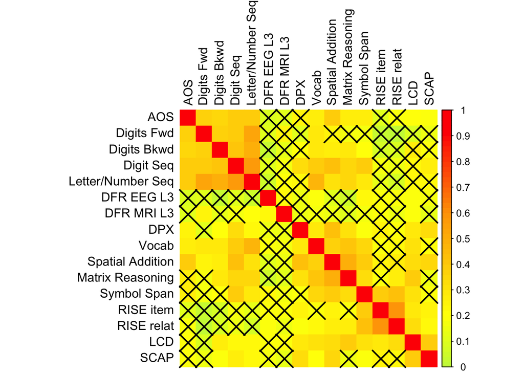

```r
# define info to make corrplot easier to read
labels <- c("Digits Fwd", "Symbol Span", "Digits Bkwd", "Digit Seq", "Letter/Number Seq", "Spatial Addition", "Matrix Reasoning", "Vocab", "LCD", "SCAP", "DFR EEG L3", "DFR MRI L3", "AOS", "DPX", "RISE item", "RISE relat")
col <- colorRampPalette(c("dark blue","light blue", "light green", "yellow", "orange", "red"))(100)


# ignore PTID
behav_corr <- corr.test(p200_cog_zscores[2:17])
colnames(behav_corr$r) <- labels
rownames(behav_corr$r) <- labels
corrplot(behav_corr$r, p.mat = behav_corr$p, method="color", tl.col = "black", tl.cex = 1, col = col, sig.level = 0.01, cl.lim = c(0,1), order="hclust")
```

```r
psych::alpha(p200_cog_zscores[2:17])
```

```
##
## Reliability analysis
## Call: psych::alpha(x = p200_cog_zscores[2:17])
##
##   raw_alpha std.alpha G6(smc) average_r S/N   ase    mean   sd median_r
##       0.84      0.84    0.86      0.25 5.2 0.017 0.00026 0.55     0.23
##
##  lower alpha upper     95% confidence boundaries
## 0.81 0.84 0.87
##
##  Reliability if an item is dropped:
##                             raw_alpha std.alpha G6(smc) average_r S/N alpha se
## ANALYSIS_DIGITSPANFWD_RAW        0.83      0.83    0.85      0.25 5.0    0.017
## WMS_SYMS_TOTSCORE                0.83      0.83    0.85      0.24 4.8    0.018
## ANALYSIS_DIGITSPANBKW_RAW        0.83      0.83    0.85      0.25 4.9    0.017
## ANALYSIS_DIGITSPANSEQ_RAW        0.82      0.82    0.84      0.24 4.7    0.018
## SCORING_LETNUMSEQ_RAW            0.82      0.83    0.84      0.24 4.7    0.018
## WMS_SA_TOTSCORE                  0.82      0.82    0.84      0.24 4.7    0.018
## SCORING_MATRIXREASONING_RAW      0.83      0.83    0.85      0.24 4.8    0.018
## VOCABULARY_TOTALRAWSCORE         0.83      0.83    0.85      0.24 4.7    0.018
## XLCD_K_MAX                       0.83      0.83    0.85      0.24 4.8    0.018
## XSCAP_MAX_CAPAC                  0.83      0.83    0.85      0.25 5.0    0.017
## XDFR_EEG_COW_L3                  0.84      0.84    0.86      0.26 5.3    0.016
## XDFR_MRI_COW_L3                  0.84      0.84    0.86      0.26 5.2    0.017
## XAOS_PART_SCORE                  0.83      0.83    0.85      0.25 4.9    0.018
## XDPX_DPRIME                      0.83      0.83    0.85      0.25 4.9    0.017
## XRISE_PR_ITEM                    0.83      0.83    0.85      0.25 5.0    0.017
## XRISE_PR_RELAT                   0.83      0.83    0.85      0.25 5.0    0.017
##                             var.r med.r
## ANALYSIS_DIGITSPANFWD_RAW   0.013  0.24
## WMS_SYMS_TOTSCORE           0.015  0.23
## ANALYSIS_DIGITSPANBKW_RAW   0.014  0.23
## ANALYSIS_DIGITSPANSEQ_RAW   0.013  0.23
## SCORING_LETNUMSEQ_RAW       0.012  0.23
## WMS_SA_TOTSCORE             0.014  0.22
## SCORING_MATRIXREASONING_RAW 0.014  0.23
## VOCABULARY_TOTALRAWSCORE    0.015  0.23
## XLCD_K_MAX                  0.015  0.23
## XSCAP_MAX_CAPAC             0.015  0.24
## XDFR_EEG_COW_L3             0.013  0.26
```

[output cut: 9 more lines]

```
## WMS_SYMS_TOTSCORE           199  0.61  0.60  0.57   0.52  1.6e-02 0.97
## ANALYSIS_DIGITSPANBKW_RAW   198  0.54  0.53  0.49   0.44 -3.0e-02 0.96
## ANALYSIS_DIGITSPANSEQ_RAW   199  0.66  0.66  0.64   0.58 -1.7e-02 0.97
## SCORING_LETNUMSEQ_RAW       198  0.64  0.63  0.62   0.56  1.3e-03 0.95
## WMS_SA_TOTSCORE             200  0.66  0.66  0.64   0.59 -3.5e-16 1.00
## SCORING_MATRIXREASONING_RAW 198  0.60  0.58  0.56   0.50  3.7e-02 0.93
## VOCABULARY_TOTALRAWSCORE    198  0.62  0.62  0.59   0.54  1.6e-02 0.98
## XLCD_K_MAX                  193  0.59  0.57  0.54   0.49 -2.3e-16 1.00
## XSCAP_MAX_CAPAC             198  0.53  0.50  0.45   0.41  3.4e-17 1.00
## XDFR_EEG_COW_L3             195  0.36  0.35  0.27   0.24  1.7e-16 1.00
## XDFR_MRI_COW_L3             184  0.42  0.40  0.32   0.30 -1.1e-16 1.00
## XAOS_PART_SCORE             195  0.58  0.55  0.51   0.46  6.6e-02 0.90
## XDPX_DPRIME                 191  0.55  0.53  0.48   0.44  1.6e-02 0.98
## XRISE_PR_ITEM               192  0.48  0.49  0.45   0.39  6.8e-02 0.83
## XRISE_PR_RELAT              192  0.50  0.50  0.47   0.40  5.6e-02 0.90
```

The cognitive variables have generally high correlations and reliability among each other, so we’re going to create constructs that will be easier to work with in future analyses. Combining multiple cognitive tests that measure WM into one construct allows us to maximize the signal for each subject and minimize the noise.

We’re trying a variety of different combinations for constructs. One distinction is the simple/complex span division - we considered any task that just included maintenance, while complex span also included manipulation. In the end, we found the most reliable results with including all tasks in an omnibus span measure. In addition, we also had to think about whether/how to include the behavior from the DFR task in the fMRI and EEG. We want to be able to include it in some way, because it’s giving us relevant information, but we also don’t want to double dip on information. In the end, we decided on including the accuracy from the EEG session but not the fMRI one, so we have an omnibus span construct that is independent of anything in the fMRI that we can use to relate to other fMRI measures.

We also created a variety of other cognitive constructs, including goal maintenance/interference control, long term memory and intelligence. Intelligence has been shown to correlate with WM, making it a theoretically interesting investigation. The others, while having interesting theoretical implications, have technical constraints because they don’t have many measures going into them (ex: GM/IC is just the DPX task, and LMT is just two different facets of the RISE task).

```r
simple_span <- p200_cog_zscores[,c("ANALYSIS_DIGITSPANFWD_RAW","WMS_SYMS_TOTSCORE","XLCD_K_MAX","XSCAP_MAX_CAPAC","XDFR_EEG_COW_L3","XDFR_MRI_COW_L3")]

simple_span_no_DFR_MRI <- p200_cog_zscores[,c("ANALYSIS_DIGITSPANFWD_RAW","WMS_SYMS_TOTSCORE","XLCD_K_MAX","XSCAP_MAX_CAPAC","XDFR_EEG_COW_L3")]
simple_span_no_DFR <- p200_cog_zscores[,c("ANALYSIS_DIGITSPANFWD_RAW","WMS_SYMS_TOTSCORE","XLCD_K_MAX","XSCAP_MAX_CAPAC")]

complex_span <- p200_cog_zscores[,c("ANALYSIS_DIGITSPANBKW_RAW","ANALYSIS_DIGITSPANSEQ_RAW","SCORING_LETNUMSEQ_RAW","WMS_SA_TOTSCORE","XAOS_PART_SCORE")]

omnibus_span <- p200_cog_zscores[,c("ANALYSIS_DIGITSPANFWD_RAW","WMS_SYMS_TOTSCORE","XLCD_K_MAX","XSCAP_MAX_CAPAC","XDFR_EEG_COW_L3","ANALYSIS_DIGITSPANBKW_RAW","ANALYSIS_DIGITSPANSEQ_RAW","SCORING_LETNUMSEQ_RAW","WMS_SA_TOTSCORE","XAOS_PART_SCORE")]
omnibus_span_no_DFR_MRI <- p200_cog_zscores[,c("ANALYSIS_DIGITSPANFWD_RAW","WMS_SYMS_TOTSCORE","XLCD_K_MAX","XSCAP_MAX_CAPAC","XDFR_EEG_COW_L3","ANALYSIS_DIGITSPANBKW_RAW","ANALYSIS_DIGITSPANSEQ_RAW","SCORING_LETNUMSEQ_RAW","WMS_SA_TOTSCORE","XAOS_PART_SCORE")]
omnibus_span_no_DFR <- p200_cog_zscores[,c("ANALYSIS_DIGITSPANFWD_RAW","WMS_SYMS_TOTSCORE","XLCD_K_MAX","XSCAP_MAX_CAPAC","ANALYSIS_DIGITSPANBKW_RAW","ANALYSIS_DIGITSPANSEQ_RAW","SCORING_LETNUMSEQ_RAW","WMS_SA_TOTSCORE","XAOS_PART_SCORE")]

GM_IC <- p200_cog_zscores[,c("XDPX_DPRIME")]

LTM <- p200_cog_zscores[,c("XRISE_PR_ITEM","XRISE_PR_RELAT")]

intelligence <- p200_cog_zscores[,c("SCORING_MATRIXREASONING_RAW","VOCABULARY_TOTALRAWSCORE")]

simple_span <- rowMeans(simple_span, na.rm = TRUE)
simple_span_no_DFR <- rowMeans(simple_span_no_DFR, na.rm = TRUE)
simple_span_no_DFR_MRI <- rowMeans(simple_span_no_DFR_MRI, na.rm = TRUE)

omnibus_span <- rowMeans(omnibus_span,na.rm=TRUE)
omnibus_span_no_DFR <- rowMeans(omnibus_span_no_DFR,na.rm=TRUE)
omnibus_span_no_DFR_MRI <- rowMeans(omnibus_span_no_DFR_MRI,na.rm=TRUE)


complex_span <- rowMeans(complex_span,na.rm=TRUE)
LTM <- rowMeans(LTM,na.rm = TRUE)
intelligence <- rowMeans(intelligence,na.rm = TRUE)

construct_vars <- data.frame(p200_cog$PTID, simple_span_no_DFR_MRI,complex_span,GM_IC,LTM,intelligence)
colnames(construct_vars)[1] <- "PTID"

construct_vars_omnibus <- cbind(construct_vars,omnibus_span_no_DFR_MRI)
constructs_fMRI <- construct_vars_omnibus[construct_vars_omnibus$PTID %in% p200_indiv_ROI_DFR_delay$PTID,]
```

```r
#again, this only has to happen once -- we just want to make sure we have access to the new behavioral variables we've been making

save(list = c("p200_data", "p200_cog", "p200_cog_zscores", "p200_clinical", "p200_clinical_zscores", "p200_demographics", "construct_vars", "construct_vars_omnibus","constructs_fMRI"), file = 'data/behav.RData')
```

# Describing Constructs

Now that we’ve created these constructs, let’s do some of the same descriptives that we did for the individual variables, with a little more detail (since there are fewer of them, and they’re going to be our variables of interest).

## Correlation Between Constructs

Generally, constructs have high correlation between each other. Good to note that span correlates with intelligence, which is something that we see in the literature.

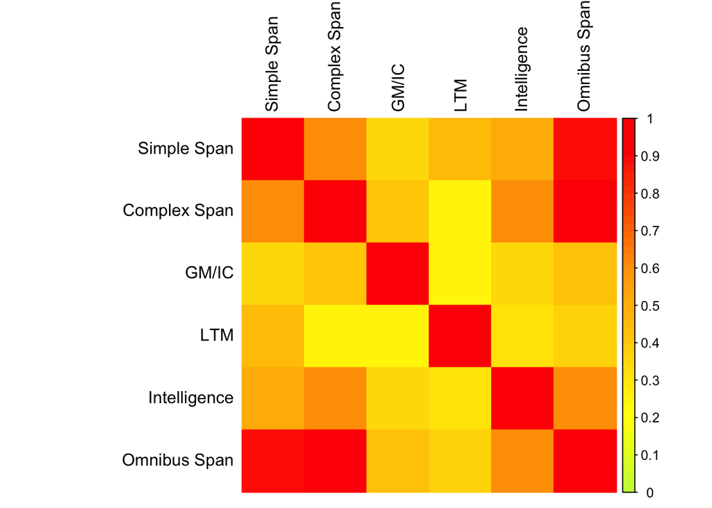

```r
construct_corr <- corr.test(construct_vars_omnibus[,2:7])
colnames(construct_corr$r) <- c("Simple Span", "Complex Span", "GM/IC", "LTM", "Intelligence", "Omnibus Span")
rownames(construct_corr$r) <- c("Simple Span", "Complex Span", "GM/IC", "LTM", "Intelligence", "Omnibus Span")
corrplot(construct_corr$r, p.mat = construct_corr$p, method="color", tl.col = "black", tl.cex = 1, col = col, sig.level = 0.01, cl.lim = c(0,1))
```

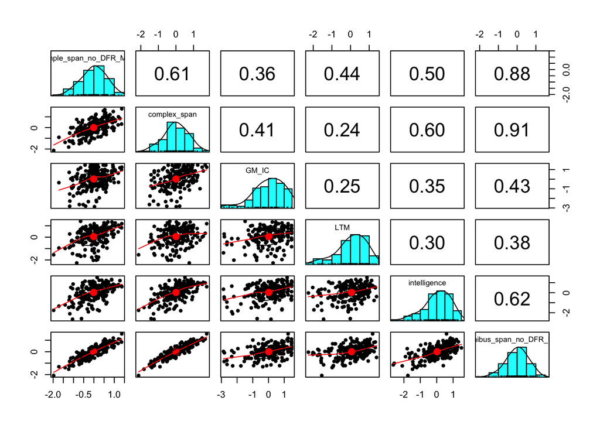

```r
pairs.panels(construct_vars_omnibus[2:7], density=TRUE)
```

## Describe Construct Variables

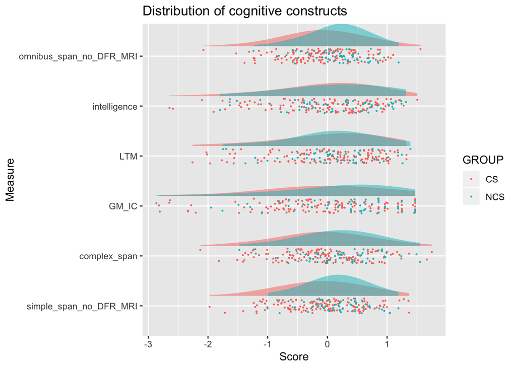

```r
# get code to do raincloud plots
source("~/Documents/Code/RainCloudPlots/tutorial_R/R_rainclouds.R")

# set up data to plot
construct_vars_omnibus <- merge(construct_vars_omnibus, p200_demographics, by = "PTID")
plot_data <- melt(construct_vars_omnibus, id.vars = c("PTID", "GENDER", "AGE", "SCANNER", "GROUP"))
plot_data$GROUP <- factor(plot_data$GROUP, labels = c("CS", "NCS"))


ggplot(plot_data,aes(x=variable,y=value))+
  geom_flat_violin(aes(fill=GROUP),position = position_nudge(x = .2, y = 0), adjust = 2,alpha = .5, colour = NA)+
  geom_point(aes(color = GROUP), position = position_jitter(width = .15), size = .25)+
  ylab('Score')+
  xlab('Measure')+
  coord_flip()+
  guides(fill = FALSE)+
  ggtitle("Distribution of cognitive constructs")
```

Difference between complex span across scanners (but lose tthis difference when take into account group), difference between complex span across gender (male > female); simple span, complex span and omnibus span across treatment group (NCS > CS).

```r
t_test_df(construct_vars_omnibus[,1:7], construct_vars_omnibus$GROUP, "Treatment Group",construct_vars_omnibus$SCANNER)
```

```
##         split_var                test_var          Statistic scanner used?
## 1 Treatment Group  simple_span_no_DFR_MRI  0.239260419080782            no
## 2 Treatment Group            complex_span  0.254630824761053            no
## 3 Treatment Group                   GM_IC  0.284270499601353            no
## 4 Treatment Group                     LTM 0.0533074261624482            no
## 5 Treatment Group            intelligence  0.170030028586323            no
## 6 Treatment Group omnibus_span_no_DFR_MRI  0.244845061875361            no
##               p.value
## 1  0.0121357165875421
## 2  0.0196298018144395
## 3  0.0672515353107385
## 4   0.667500331629278
## 5   0.176112724334697
## 6 0.00752196740357095
```

```r
t_test_df(construct_vars_omnibus[c(1:91,93:200),1:7], construct_vars_omnibus$GENDER[c(1:91,93:200)], "Gender",construct_vars_omnibus$SCANNER[c(1:91,93:200)])
```

```
##   split_var                test_var           Statistic scanner used?
## 1    Gender  simple_span_no_DFR_MRI -0.0488294859859832            no
## 2    Gender            complex_span  -0.216790651282707            no
## 3    Gender                   GM_IC  -0.180710757376799            no
## 4    Gender                     LTM -0.0191193426388525            no
## 5    Gender            intelligence -0.0678852341372624            no
## 6    Gender omnibus_span_no_DFR_MRI  -0.131959563107845            no
##              p.value
## 1   0.59212008124516
## 2 0.0358684752720365
## 3  0.225665899938127
## 4  0.871556959188836
## 5  0.572226633480456
## 6  0.129675602733473
```

```r
t_test_df(construct_vars_omnibus[,1:7], construct_vars_omnibus$SCANNER, "Scanner", construct_vars_omnibus$GROUP)
```

```
##   split_var                test_var           Statistic scanner used?
## 1   Scanner  simple_span_no_DFR_MRI  -0.119650916776773           yes
## 2   Scanner            complex_span  -0.187576945104761           yes
## 3   Scanner                   GM_IC -0.0247159619663562            no
## 4   Scanner                     LTM -0.0933437741510485            no
## 5   Scanner            intelligence  -0.103271936411286            no
## 6   Scanner omnibus_span_no_DFR_MRI  -0.152840006544063           yes
##              p.value
## 1   0.16524568230144
## 2 0.0569525995573078
## 3  0.862550711735312
## 4  0.408257345963678
## 5  0.367410867245543
## 6 0.0641195232527693
```